# Estimates of molecular convergence reveal genes with intermediate pleiotropy underlying adaptive variation across teleost fish - Report

Agneesh Barua

02/04/2025

This report comprises R code used in the current manuscript. Users can load the appropriate Rmd files found in the electronic supplementary material (DatasetS10_Scripts) and reproduce the analysis and steps showed here. Electronic supplementary material containing all the data files can be found at: https://zenodo.org/records/12645625

Users are free to use any piece of code in heir own studies. If you use any of the code here please cite:  
Estimates of molecular convergence reveal genes with intermediate pleiotropy underlying adaptive variation across teleost fish doi: https://doi.org/10.1101/2024.06.24.600426

## Processing orthologs from OrthoFinder

For this study, I gathered a list of all teleost species that had chromosomal level annotated genomes from NCBI and Ensembl. I obtained a well resolved rooted phylogeny of all the teleost species in my original list from timetree.org. The time tree had phylogenetic relationship for 143 species. I used only those species in this study as having a well-resolved unambiguous species tree is crucial for this study. I next downloaded protein and CSD data from all 143 species. I constructed orthologs using Orthofinder.

### Functions to process OrthoFinder output

In this section I process the tsv output of orthofinder to give a parsable data structure.

```r
make_orth_table<-function(.data,var){

.data %>% drop_na()->d
ncols<-max(stringr::str_count(d$sp,",")) +1
colmn<-paste("col",1:ncols)
d %>% separate(col = sp,sep = ",",into = colmn,remove = T)->d
d %>% pivot_longer(!Orthogroup)->d
d %>% mutate(orths = str_remove(d$value," ")) %>%
  dplyr::select(Orthogroup,orths) %>%
  drop_na() %>%  return()

}

make_orth_table<-function(.x){
  orthdata<-read_tsv("Datasets/OF_out.tsv") #ouput from OrthoFinder
  orthdata %>% dplyr::select(c(Orthogroup,contains(.x)))->d
  ncols<-max(stringr::str_count(d[,2],",")) +1
  colmn<-paste("col",1:ncols)
  d %>% separate(col = 2,sep = ",",into = colmn,remove = T)->d
  d %>% pivot_longer(!Orthogroup)->d
  d %>% mutate(orths = str_remove(d$value," ")) %>%
    dplyr::select(Orthogroup,orths) %>% drop_na %>% mutate(sp = .x) %>%  return()
}
```

### Taxonomic data from FishBase

My next step was to select orthgroups that had atleast one member from each of ther orders represented in my list of species. This was to ensure we capture the maximum taxonomic diversity while still having a manageable dataset to work with. To get taxonomic information I used FishBase.

```r
library(rfishbase)
fish<-read_csv("./Datasets/DatasetS0_csv_files/FishList.csv", col_names = "sp")  #list of species; redundant file
fish_call<-validate_names(str_replace(fish$sp,"_"," "))
taxa<-rfishbase::load_taxa() %>% filter(Species %in% fish_call) %>% collect() %>% dplyr::select(Species,Order,Family)

fish_data<-tibble(Species = str_replace(taxa$Species," ","_"),
                  Order = str_split(taxa$Order,pattern = "/",simplify = T)[,1],
                  Family = taxa$Family) %>% write_csv("./Datasets/DatasetS0_csv_files/Fish_data.csv") #Final list of species, order, and family used in the study. This was used to filter the orthList
```

Taxonomic information of speices used.

```r
tbl<-read.csv("./Datasets/DatasetS0_csv_files/Fish_data.csv")
kbl(head(tbl,500)) %>% kable_styling() %>%
  scroll_box(width = "500px", height = "400px")
```

| Species | Order | Family |
| --- | --- | --- |
| Acanthochromis_polyacanthus | Ovalentaria | Pomacentridae |
| Acanthopagrus_latus | Acanthuriformes | Sparidae |
| Ameiurus_melas | Siluriformes | Ictaluridae |
| Albula_goreensis | Albuliformes | Albulidae |
| Alosa_alosa | Clupeiformes | Alosidae |
| Alosa_sapidissima | Clupeiformes | Alosidae |
| Amphiprion_ocellaris | Ovalentaria | Pomacentridae |
| Anabas_testudineus | Anabantiformes | Anabantidae |
| Anguilla_anguilla | Anguilliformes | Anguillidae |
| Anoplopoma_fimbria | Perciformes | Anoplopomatidae |
| Archocentrus_centrarchus | Cichliformes | Cichlidae |
| Astatotilapia_calliptera | Cichliformes | Cichlidae |
| Astyanax_mexicanus | Characiformes | Characidae |
| Betta_splendens | Anabantiformes | Osphronemidae |
| Brienomyrus_brachyistius | Osteoglossiformes | Mormyridae |
| Carassius_auratus | Cypriniformes | Cyprinidae |
| Carassius_carassius | Cypriniformes | Cyprinidae |
| Carassius_gibelio | Cypriniformes | Cyprinidae |
| Centropristis_striata | Perciformes | Serranidae |
| Chaenocephalus_aceratus | Perciformes | Channichthyidae |
| Chanos_chanos | Gonorynchiformes | Chanidae |
| Chelmon_rostratus | Acanthuriformes | Chaetodontidae |
| Cheilinus_undulatus | Labriformes | Labridae |
| Clarias_gariepinus | Siluriformes | Clariidae |
| Corythoichthys_intestinalis | Syngnathiformes | Syngnathidae |
| Clupea_harengus | Clupeiformes | Clupeidae |
| Collichthys_lucidus | Acanthuriformes | Sciaenidae |
| Conger_conger | Anguilliformes | Congridae |
| Coregonus_clupeaformis | Salmoniformes | Salmonidae |
| Cottoperca_gobio | Perciformes | Bovichtidae |

[output cut: 113 more lines]

### Filter the Orthogroup list

To keep computational times reasonable I only selected the orthogroups that had less than a 1500 genes.

```r
#Filter orthogroups to contains only the one with all orders
fish<-read_csv("./Datasets/DatasetS0_csv_files/Fish_data.csv")  #taxonomic data from FishBase of species
fish<-as.list(fish$Species)

#Function to make final orthogroup list
map(fish,make_orth_table) %>% purrr::reduce(rbind) %>% saveRDS("./RDS/large_fish_tree_all_orders.rds")
orth_list<-readRDS("./RDS/large_fish_tree_all_orders.rds") #Orthogroups with 143 species, containing 2.4 million genes

#Filter out orthogroups with greater than 1500 genes
orth_list %>% summarise(n = n(), .by = "Orthogroup") %>% filter(n < 1500) %>% write_csv("./Datasets/DatasetS0_csv_files/og_list_used_in_analysis.csv")
```

```r
tbl<-read_csv("./Datasets/DatasetS0_csv_files/og_list_used_in_analysis.csv")
kbl(head(tbl,500)) %>% kable_styling() %>%
  scroll_box(width = "200px", height = "400px")
```

| Orthogroup | n |
| --- | --- |
| OG0000068 | 1445 |
| OG0000073 | 1302 |
| OG0000075 | 1352 |
| OG0000076 | 1338 |
| OG0000077 | 1314 |
| OG0000082 | 1285 |
| OG0000084 | 1280 |
| OG0000085 | 1239 |
| OG0000086 | 1249 |
| OG0000087 | 1254 |
| OG0000090 | 1233 |
| OG0000092 | 1219 |
| OG0000094 | 1204 |
| OG0000095 | 1179 |
| OG0000096 | 1211 |
| OG0000097 | 1187 |
| OG0000098 | 1184 |
| OG0000100 | 1183 |
| OG0000101 | 1193 |
| OG0000102 | 1154 |
| OG0000103 | 1151 |
| OG0000104 | 1161 |
| OG0000107 | 1164 |
| OG0000108 | 1154 |
| OG0000109 | 1150 |
| OG0000110 | 1139 |
| OG0000111 | 1161 |
| OG0000114 | 1133 |
| OG0000115 | 1141 |
| OG0000116 | 1144 |

[output cut: 470 more lines]

### Checking the genes and proccesses that were excluded in the analysis

```r
orth_list<-readRDS("./RDS/large_fish_tree_all_orders.rds")
orth_list_over_1.5k<-orth_list %>% summarise(n = n(), .by = "Orthogroup") %>% filter(n > 1500)
#Get the orths in danio to annotate
danio_1.5k<-orth_list %>% filter(sp == "Danio_rerio") %>% filter(Orthogroup %in% orth_list_over_1.5k$Orthogroup) %>% mutate(orths =  str_replace_all(orths, "\\.\\d+", ""))

Danio_biomart<-read_csv("./Datasets/DatasetS0_csv_files/Danio_biomart.csv")

danio_1.5k_annot<-left_join(danio_1.5k,Danio_biomart %>% dplyr::rename(orths = `Gene stable ID`), by = "orths")
danio_1.5k_annot %>% write_csv("./Datasets/DatasetS0_csv_files/danio_1.5k_annot.csv")
```

```r
tbl<-read_csv("./Datasets/DatasetS0_csv_files/danio_1.5k_annot.csv")
kbl(head(tbl,1000)) %>% kable_styling() %>%
  scroll_box(width = "600px", height = "400px")
```

| Orthogroup | orths | sp | Order | Class | Gene stable ID version | Transcript stable ID | Transcript stable ID version | Gene name | Gene description | Protein stable ID | Protein stable ID version |
| --- | --- | --- | --- | --- | --- | --- | --- | --- | --- | --- | --- |
| OG0000000 | ENSDARG00000038352 | Danio_rerio | Cypriniformes | Teleostei | ENSDARG00000038352.9 | ENSDART00000067775 | ENSDART00000067775.7 | slc27a1b | solute carrier family 27 member 1b [Source:ZFIN;Acc:ZDB-GENE-061013-672] | ENSDARP00000067774 | ENSDARP00000067774.6 |
| OG0000000 | ENSDARG00000039900 | Danio_rerio | Cypriniformes | Teleostei | ENSDARG00000039900.8 | ENSDART00000152277 | ENSDART00000152277.3 | si:ch73-168d20.1 | si:ch73-168d20.1 [Source:ZFIN;Acc:ZDB-GENE-121214-44] | ENSDARP00000126848 | ENSDARP00000126848.1 |
| OG0000000 | ENSDARG00000039900 | Danio_rerio | Cypriniformes | Teleostei | ENSDARG00000039900.8 | ENSDART00000179776 | ENSDART00000179776.1 | si:ch73-168d20.1 | si:ch73-168d20.1 [Source:ZFIN;Acc:ZDB-GENE-121214-44] | ENSDARP00000145114 | ENSDARP00000145114.1 |
| OG0000000 | ENSDARG00000043792 | Danio_rerio | Cypriniformes | Teleostei | ENSDARG00000043792.6 | ENSDART00000139539 | ENSDART00000139539.4 | si:rp71-7l19.2 | si:rp71-7l19.2 [Source:ZFIN;Acc:ZDB-GENE-081103-31] | ENSDARP00000114570 | ENSDARP00000114570.2 |
| OG0000000 | ENSDARG00000043792 | Danio_rerio | Cypriniformes | Teleostei | ENSDARG00000043792.6 | ENSDART00000184429 | ENSDART00000184429.1 | si:rp71-7l19.2 | si:rp71-7l19.2 [Source:ZFIN;Acc:ZDB-GENE-081103-31] | ENSDARP00000146590 | ENSDARP00000146590.1 |
| OG0000000 | ENSDARG00000068127 | Danio_rerio | Cypriniformes | Teleostei | ENSDARG00000068127.7 | ENSDART00000097668 | ENSDART00000097668.5 | si:ch211-194e1.7 | si:ch211-194e1.7 [Source:ZFIN;Acc:ZDB-GENE-081105-104] | ENSDARP00000088438 | ENSDARP00000088438.5 |
| OG0000000 | ENSDARG00000068127 | Danio_rerio | Cypriniformes | Teleostei | ENSDARG00000068127.7 | ENSDART00000138767 | ENSDART00000138767.3 | si:ch211-194e1.7 | si:ch211-194e1.7 [Source:ZFIN;Acc:ZDB-GENE-081105-104] | ENSDARP00000117445 | ENSDARP00000117445.2 |
| OG0000000 | ENSDARG00000068621 | Danio_rerio | Cypriniformes | Teleostei | ENSDARG00000068621.6 | ENSDART00000152490 | ENSDART00000152490.3 | si:ch211-181d7.3 | si:ch211-181d7.3 [Source:ZFIN;Acc:ZDB-GENE-121214-30] | ENSDARP00000126823 | ENSDARP00000126823.1 |
| OG0000000 | ENSDARG00000068621 | Danio_rerio | Cypriniformes | Teleostei | ENSDARG00000068621.6 | ENSDART00000180426 | ENSDART00000180426.1 | si:ch211-181d7.3 | si:ch211-181d7.3 [Source:ZFIN;Acc:ZDB-GENE-121214-30] | ENSDARP00000156818 | ENSDARP00000156818.1 |
| OG0000000 | ENSDARG00000068621 | Danio_rerio | Cypriniformes | Teleostei | ENSDARG00000068621.6 | ENSDART00000099313 | ENSDART00000099313.5 | si:ch211-181d7.3 | si:ch211-181d7.3 [Source:ZFIN;Acc:ZDB-GENE-121214-30] | ENSDARP00000090086 | ENSDARP00000090086.3 |
| OG0000000 | ENSDARG00000069264 | Danio_rerio | Cypriniformes | Teleostei | ENSDARG00000069264.6 | ENSDART00000145381 | ENSDART00000145381.3 | si:ch211-196h16.5 | si:ch211-196h16.5 [Source:ZFIN;Acc:ZDB-GENE-081029-8] | ENSDARP00000121896 | ENSDARP00000121896.2 |
| OG0000000 | ENSDARG00000069264 | Danio_rerio | Cypriniformes | Teleostei | ENSDARG00000069264.6 | ENSDART00000193654 | ENSDART00000193654.1 | si:ch211-196h16.5 | si:ch211-196h16.5 [Source:ZFIN;Acc:ZDB-GENE-081029-8] | ENSDARP00000156499 | ENSDARP00000156499.1 |
| OG0000000 | ENSDARG00000069627 | Danio_rerio | Cypriniformes | Teleostei | ENSDARG00000069627.7 | ENSDART00000133606 | ENSDART00000133606.3 | si:ch211-255g12.8 | si:ch211-255g12.8 [Source:ZFIN;Acc:ZDB-GENE-081104-39] | ENSDARP00000123545 | ENSDARP00000123545.2 |
| OG0000000 | ENSDARG00000074653 | Danio_rerio | Cypriniformes | Teleostei | ENSDARG00000074653.6 | ENSDART00000138143 | ENSDART00000138143.3 | si:ch211-233m11.1 | si:ch211-233m11.1 [Source:ZFIN;Acc:ZDB-GENE-081028-16] | ENSDARP00000118436 | ENSDARP00000118436.2 |
| OG0000000 | ENSDARG00000076819 | Danio_rerio | Cypriniformes | Teleostei | ENSDARG00000076819.7 | ENSDART00000136952 | ENSDART00000136952.3 | nlrc8 | NLR family CARD domain containing 8 [Source:ZFIN;Acc:ZDB-GENE-070912-363] | ENSDARP00000116140 | ENSDARP00000116140.2 |
| OG0000000 | ENSDARG00000077488 | Danio_rerio | Cypriniformes | Teleostei | ENSDARG00000077488.5 | ENSDART00000150438 | ENSDART00000150438.3 | si:ch73-289h5.4 | si:ch73-289h5.4 [Source:ZFIN;Acc:ZDB-GENE-110913-10] | ENSDARP00000125305 | ENSDARP00000125305.1 |
| OG0000000 | ENSDARG00000077488 | Danio_rerio | Cypriniformes | Teleostei | ENSDARG00000077488.5 | ENSDART00000113296 | ENSDART00000113296.4 | si:ch73-289h5.4 | si:ch73-289h5.4 [Source:ZFIN;Acc:ZDB-GENE-110913-10] | ENSDARP00000098532 | ENSDARP00000098532.3 |
| OG0000000 | ENSDARG00000077488 | Danio_rerio | Cypriniformes | Teleostei | ENSDARG00000077488.5 | ENSDART00000191574 | ENSDART00000191574.1 | si:ch73-289h5.4 | si:ch73-289h5.4 [Source:ZFIN;Acc:ZDB-GENE-110913-10] | ENSDARP00000146536 | ENSDARP00000146536.1 |
| OG0000000 | ENSDARG00000077673 | Danio_rerio | Cypriniformes | Teleostei | ENSDARG00000077673.6 | ENSDART00000146246 | ENSDART00000146246.3 | nlrp16 | NACHT, LRR and PYD domains-containing protein 16 [Source:ZFIN;Acc:ZDB-GENE-030131-8582] | ENSDARP00000115653 | ENSDARP00000115653.2 |
| OG0000000 | ENSDARG00000077673 | Danio_rerio | Cypriniformes | Teleostei | ENSDARG00000077673.6 | ENSDART00000099821 | ENSDART00000099821.5 | nlrp16 | NACHT, LRR and PYD domains-containing protein 16 [Source:ZFIN;Acc:ZDB-GENE-030131-8582] | ENSDARP00000090594 | ENSDARP00000090594.4 |
| OG0000000 | ENSDARG00000077697 | Danio_rerio | Cypriniformes | Teleostei | ENSDARG00000077697.6 | ENSDART00000160587 | ENSDART00000160587.2 | si:dkey-105i14.1 | si:dkey-105i14.1 [Source:ZFIN;Acc:ZDB-GENE-081103-64] | ENSDARP00000131074 | ENSDARP00000131074.1 |
| OG0000000 | ENSDARG00000077697 | Danio_rerio | Cypriniformes | Teleostei | ENSDARG00000077697.6 | ENSDART00000104921 | ENSDART00000104921.4 | si:dkey-105i14.1 | si:dkey-105i14.1 [Source:ZFIN;Acc:ZDB-GENE-081103-64] | ENSDARP00000095691 | ENSDARP00000095691.3 |
| OG0000000 | ENSDARG00000078002 | Danio_rerio | Cypriniformes | Teleostei | ENSDARG00000078002.6 | ENSDART00000141573 | ENSDART00000141573.4 | si:dkey-13n15.11 | si:dkey-13n15.11 [Source:ZFIN;Acc:ZDB-GENE-070705-295] | ENSDARP00000119348 | ENSDARP00000119348.2 |
| OG0000000 | ENSDARG00000078101 | Danio_rerio | Cypriniformes | Teleostei | ENSDARG00000078101.6 | ENSDART00000141496 | ENSDART00000141496.3 | nlrc9 | NLR family CARD domain containing 9 [Source:ZFIN;Acc:ZDB-GENE-070912-362] | ENSDARP00000116893 | ENSDARP00000116893.2 |
| OG0000000 | ENSDARG00000078101 | Danio_rerio | Cypriniformes | Teleostei | ENSDARG00000078101.6 | ENSDART00000183327 | ENSDART00000183327.1 | nlrc9 | NLR family CARD domain containing 9 [Source:ZFIN;Acc:ZDB-GENE-070912-362] | ENSDARP00000150263 | ENSDARP00000150263.1 |
| OG0000000 | ENSDARG00000078101 | Danio_rerio | Cypriniformes | Teleostei | ENSDARG00000078101.6 | ENSDART00000170395 | ENSDART00000170395.2 | nlrc9 | NLR family CARD domain containing 9 [Source:ZFIN;Acc:ZDB-GENE-070912-362] | ENSDARP00000138733 | ENSDARP00000138733.2 |
| OG0000000 | ENSDARG00000078101 | Danio_rerio | Cypriniformes | Teleostei | ENSDARG00000078101.6 | ENSDART00000188847 | ENSDART00000188847.1 | nlrc9 | NLR family CARD domain containing 9 [Source:ZFIN;Acc:ZDB-GENE-070912-362] | ENSDARP00000156737 | ENSDARP00000156737.1 |
| OG0000000 | ENSDARG00000078101 | Danio_rerio | Cypriniformes | Teleostei | ENSDARG00000078101.6 | ENSDART00000099437 | ENSDART00000099437.5 | nlrc9 | NLR family CARD domain containing 9 [Source:ZFIN;Acc:ZDB-GENE-070912-362] | ENSDARP00000090210 | ENSDARP00000090210.5 |
| OG0000000 | ENSDARG00000078246 | Danio_rerio | Cypriniformes | Teleostei | ENSDARG00000078246.8 | ENSDART00000156678 | ENSDART00000156678.3 | si:ch211-114l13.4 | si:ch211-114l13.4 [Source:ZFIN;Acc:ZDB-GENE-070424-113] | ENSDARP00000127840 | ENSDARP00000127840.3 |
| OG0000000 | ENSDARG00000078246 | Danio_rerio | Cypriniformes | Teleostei | ENSDARG00000078246.8 | ENSDART00000115190 | ENSDART00000115190.6 | si:ch211-114l13.4 | si:ch211-114l13.4 [Source:ZFIN;Acc:ZDB-GENE-070424-113] | ENSDARP00000103447 | ENSDARP00000103447.4 |

[output cut: 970 more lines]

### GO enrichment analysis of over 1500 gene orthogroups

I annotated and functionally characterised the excluded orthogroups, and found that they were mostly associated with immune processes and ion transport, whereas the gene sets we used in our analysis were involved in many diverse processes. Although processes related to ion transport and immunity are important, our sample encompassed a diverse array of processes, and provided a powerful window into teleost evolution.

```r
library(GOstats)
library(GO.db)
library(GSEABase)
library(AnnotationDbi)
library(RSQLite)
library(tidyverse)


annot<-read_tsv("./Datasets/DatasetS0_csv_files/annot.tsv", col_names = c("GO_id","evidence","gene")) #annot.tsv was obstained from DeepGO
annot<-annot %>% mutate(gene =  str_remove(annot$gene,"..$"))
annot<-annot %>% mutate(gene =  str_remove(annot$gene,"\\."))
goFrame<-GOFrame(as.data.frame(annot, organism = "fish"))
goAllFrame<-GOAllFrame(goFrame)
gsc<-GeneSetCollection(goAllFrame,setType = GOCollection())
universe<-annot$gene

GO_enrich<-function(.data){

  up<-GSEAGOHyperGParams(name = "GO enrich",
                             geneSetCollection = gsc,
                             geneIds = .data,
                             universeGeneIds = universe,
                             ontology = "BP", #options: BP, MF, CC
                             pvalueCutoff = 0.05,
                             conditional = F,
                             testDirection = "over")
  Over_up<- hyperGTest(up)


  Over_up.pv<-pvalues(Over_up)
  pv.fdr<-p.adjust(Over_up.pv,"fdr")
  summary(Over_up) %>% as_tibble() %>% mutate(FDR = pv.fdr[1:nrow(summary(Over_up) %>% as_tibble())]) %>% dplyr::select(GOBPID,FDR,Term,Size) %>% filter(FDR<=0.05) %>% return()
}

orth_list<-readRDS("./RDS/large_fish_tree_all_orders.rds")
orth_list<-orth_list %>% mutate(orths =  str_replace_all(orths, "\\.\\d+", ""))

GO_enrich(orth_list %>% filter(Orthogroup %in% orth_list_over_1.5k$Orthogroup) %>% pull(orths)) %>% saveRDS("./RDS/more1.5kgenes_orths_GO_BP.rds")
```

```r
## GO plot
library(ggforce)

go_plot<-function(.data,name){
  GOenrich<-.data %>% arrange(desc(FDR)) %>% head(118)
  ggplot(GOenrich,aes(x = 1-log10(FDR),
                           y = as.factor(Term),
                           size = log10(Size)))+
    geom_point(color = "darkgreen")+
    ylab("Biological Process")+
    theme_light()->go_plot
  #ggplot2::ggsave(paste("./Figures/",name,"_GO_enrich.png"),go_plot,width = 5,height = 10, units = "in",scale = 1.5,limitsize
                  #= F,device = "png")
  return(go_plot)
  }

go_plot(readRDS("./RDS/more1.5kgenes_orths_GO_BP.rds"))
```

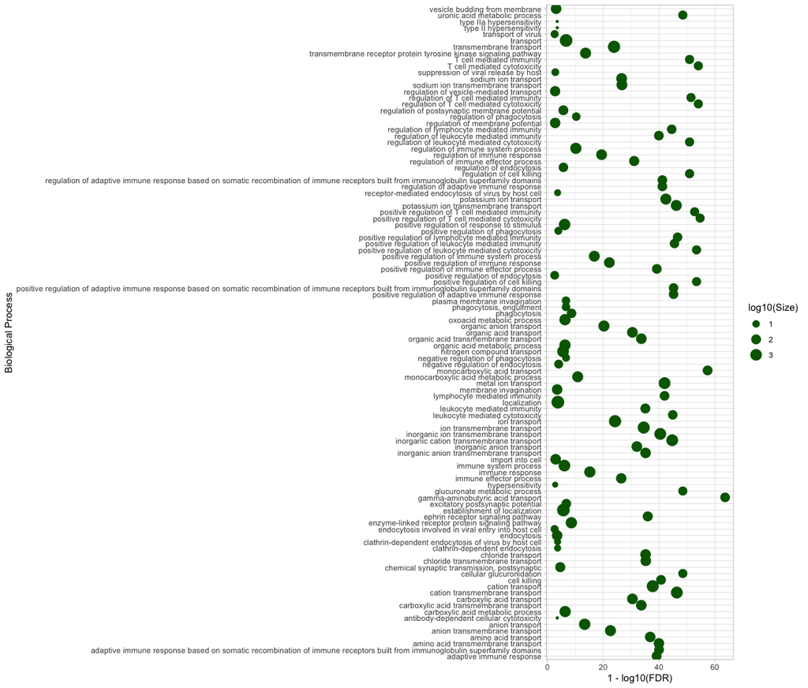

```r
knitr::include_graphics("./Figures/FigS1_over1k_GO_enrichment.png")
```

### Fish phylogeny

I obtained a rooted phylogenetic tree from timetree.org

```r
library(phytools)
library(ggtree)
library(RColorBrewer)

tree<-read.newick("./Datasets/DatasetS0_csv_files/Fish_tree.nwk")
fish_data<-read.csv("./Datasets/DatasetS0_csv_files/Fish_data.csv")
p<-ggtree(tree,branch.length = "none")#,layout = "circular")
p$data %>% filter(isTip==F)->not_tips
p$data %>% filter(isTip==T)->tips
left_join(tips,(fish_data %>% dplyr::rename(label=Species)),by = "label")->tips
not_tips %>% mutate(Order = "NA") %>% mutate(Family = "NA")->not_tips
rbind(tips, not_tips)->p$data
p <- p + geom_tree()+geom_tiplab(size=3)+hexpand(.95)
```

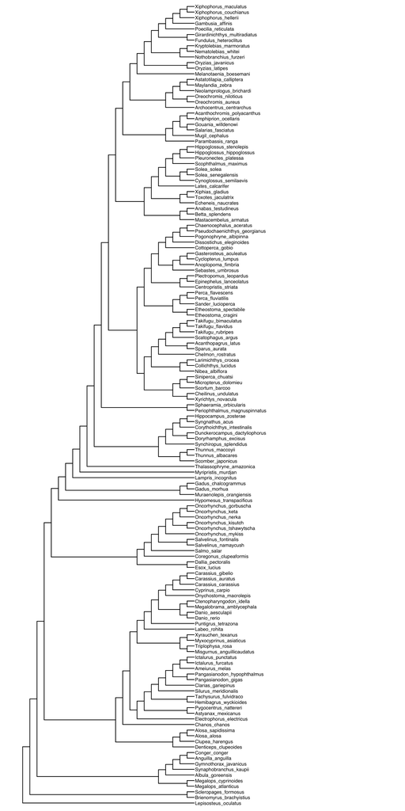

```r
p #Circular species tree in Fig 1
```

## Downloading Bgee data

This section deals with connecting to the Bgee server and downloading the data.

### Functions to download Bgee data

Here are are the functions I used to download and process the data from Bgee. Accesses the Bgee data set and download data

```r
# Function to download RNA-seq data from Bgee
bgee_download <- function(species, samples) {
  print(species)
  print(samples)

  bgee <- BgeeDB::Bgee$new(species=species, dataType="rna_seq")

  bgee.data <- BgeeDB::getData(bgee, sampleId=samples)
  bgee.data <- bind_rows(bgee.data)
  bgee.data[, c("Anatomical.entity.name", "Stage.name", "Strain")] <-
    apply(bgee.data[, c("Anatomical.entity.name", "Stage.name", "Strain")], 2,
          function(i) { gsub('\"', "", i) })

  return(bgee.data)
}

species.list <- listBgeeSpecies(release="15.0")

# Did this manually to identify the fishes
# NCBI taxonomy ID
species.fish <- c("Lepisosteus_oculatus"="7918",
                  "Anguilla_anguilla"="7936",
                  "Danio_rerio"="7955",
                  "Astyanax_mexicanus"="7994",
                  "Esox_lucius"="8010",
                  "Salmo_salar"="8030",
                  "Gadus_morhua"="8049",
                  "Poecilia_reticulata"="8081",
                  "Oryzias_latipes"="8090",
                  "Astatotilapia_calliptera"="8154",
                  "Neolamprologus_brichardi"="32507",
                  "Scophthalmus_maximus"="52904",
                  "Gasterosteus_aculeatus"="69293",
                  "Nothobranchius_furzeri"="105023")

#Use the code below to retrieve annotations of samples for each species.
annotation <-
  lapply(species.fish, function(id) {
    getAnnotation(Bgee$new(
      species=id, dataType="rna_seq"))
  } )
names(annotation) <- names(species.fish)
#for (s in names(species.fish)) {
#  annotation[[s]]$sample.annotation$Anatomical.entity.name <-
#    gsub(" ","_", annotation[[s]]$sample.annotation$Anatomical.entity.name)
#}
# Separate sample and experiment annotations
annotation.sample <- vector(mode="list",length=length(species.fish))
names(annotation.sample) <- names(species.fish)
annotation.exp <- vector(mode="list",length=length(species.fish))
names(annotation.exp) <- names(species.fish)
for (s in names(species.fish)) {
  annotation.sample[[s]] <- annotation[[s]][["sample.annotation"]]
  annotation.exp[[s]] <- annotation[[s]][["experiment.annotation"]]
}
annotation.sample <- annotation.sample %>%
  dplyr::bind_rows(.id="Species")
annotation.exp <- annotation.exp %>%
  dplyr::bind_rows(.id="Species")

# Download RNA-seq data per species
rna.seq <-
  lapply(setNames(names(species.fish), names(species.fish)), function(s) {
    bgee_download(species=species.fish[[s]],
                  samples=annotation.sample$Library.ID[annotation.sample$Species==s])
  })
#for (s in names(species)) {
#  rna.seq[[s]]$Anatomical.entity.name <-
#    gsub(" ","_", rna.seq[[s]]$Anatomical.entity.name)
#}

annotation.sample %>% saveRDS("./RDS/Bgee_fish_annotation.samples_more_fish.rds")
annotation.exp %>% saveRDS("./RDS/Bgee_fish_annotation.exp_more_fish.rds")
rna.seq %>% saveRDS("./RDS/Bgee_fish_rna.seq_more_fish.rds")
```

### Functions to process Bgee data

After downloading the Bgee data I use the following function to make specific data frames, perform batch correction, and compute tissue-specificity.

```r
#Get number of tissues
no_of_tissue_samples_in_each_fish<-function(x){
  bgee_dat %>% dplyr::filter(Anatomical.entity.name == x) %>% dplyr::group_by(Species) %>% dplyr::summarise(Libraries = length(unique(Library.ID)))
}

#Make the expression matrix data frame
make_exp_data_frames_Read.count<-function(.data, ...){
  .data %>% filter(Library.ID %in% bgee_dat$Library.ID) %>%
    dplyr::select(Gene.ID, Read.count, Library.ID) %>%
    pivot_wider(names_from = Library.ID,values_from = Read.count)
  }

TMM_norm_only<-function(.data){
  library(edgeR)

#TMM norm
   #design matix
  design_matrix<-.data %>% filter(Library.ID %in% bgee_dat$Library.ID) %>%
                 dplyr::select(Experiment.ID,Library.ID,Anatomical.entity.name) %>% distinct()

  dge<-edgeR::DGEList(.data %>% make_exp_data_frames_Read.count() %>% column_to_rownames("Gene.ID"), group = factor(design_matrix$Anatomical.entity.name))
    keep<-filterByExpr(cpm(dge), min.count = 1, group = factor(design_matrix$Anatomical.entity.name))
    dge<-dge[keep, ,keep.lib.sizes =T]
    dge<-calcNormFactors(dge,method = "TMM")
    dge<-edgeR::cpm(dge, normalized.lib.sizes = T, log = F)
    return(dge)

}

#Building the tau data frame
build_tau_data_frame<-function(.data, var) {
  left_join(.data %>% pivot_longer(!Gene.ID,names_to = "Library.ID",values_to = "counts"),
            bgee_dat %>% filter(Species == {{ var }}) %>%
              dplyr::select(Library.ID,Anatomical.entity.name),by = "Library.ID") %>%
    group_by(Gene.ID,Anatomical.entity.name) %>%
    summarise(counts = mean(counts)) %>%
    spread(Anatomical.entity.name,counts)
}

#TMM with combat batch correction
#NOT USED IN THIS VERSION
combat<-function(.data){
  library(edgeR)
  library(DESeq2)

design_matrix<-rna.dat$Lepisosteus_oculatus %>% filter(Library.ID %in% bgee_dat$Library.ID) %>%
  dplyr::select(Experiment.ID,Library.ID,Anatomical.entity.name) %>% distinct()

dge<-edgeR::DGEList(rna.dat$Lepisosteus_oculatus %>% make_exp_data_frames_Read.count() %>% column_to_rownames("Gene.ID"), group = factor(design_matrix$Anatomical.entity.name))
keep<-edgeR::filterByExpr(cpm(dge), min.count = 1, group = factor(design_matrix$Experiment.ID))
dge<-dge[keep, ,keep.lib.sizes =T]
dge<-calcNormFactors(dge,method = "TMM")
dge<-edgeR::cpm(dge, normalized.lib.sizes = T, log = F)

dge <- sva::ComBat_seq(dge, batch=design_matrix$Experiment.ID, group=NULL)


log10(dge+1) %>% as.matrix() %>%
  preprocessCore::normalize.quantiles(as.matrix(.data),keep.names = T)->m

colData<-DataFrame(experiment = design_matrix$Experiment.ID,
                   tissue =  design_matrix$Anatomical.entity.name)

se<-SummarizedExperiment::SummarizedExperiment(m - rowMeans(m),colData = colData)
pcaDat<-plotPCA(DESeqTransform(se),intgroup = c("tissue","experiment"), ntop = 10000, returnData=T)
percentVar_all<-round(100 * attr(pcaDat,"percentVar"))

plot<-ggplot(pcaDat,aes(PC1,PC2,color = experiment,label = tissue))+
  geom_text()+
  theme_light()+
  xlab(paste0("PC1 (",percentVar_all[1],"%)")) +
  ylab(paste0("PC2 (",percentVar_all[2],"%)"))


return(dge) #use to make data frame
#return(plot) #use to see PCA after combat
}

#TMM nnormalisation plus batch correction for different experiment and visualising the pca
norm_pca<-function(.data){
  library(edgeR)
  library(DESeq2)

design_matrix<-.data %>% filter(Library.ID %in% bgee_dat$Library.ID) %>%
  dplyr::select(Experiment.ID,Library.ID,Anatomical.entity.name) %>% distinct()

dge<-edgeR::DGEList(.data %>% make_exp_data_frames_Read.count() %>% column_to_rownames("Gene.ID"), group = factor(design_matrix$Anatomical.entity.name))
keep<-filterByExpr(cpm(dge), min.count = 1, group = factor(design_matrix$Experiment.ID))
dge<-dge[keep, ,keep.lib.sizes =T]
dge<-calcNormFactors(dge,method = "TMM")
dge<-edgeR::cpm(dge, normalized.lib.sizes = T, log = F)


log10(dge+1) %>%
  as.matrix() %>%
  preprocessCore::normalize.quantiles(as.matrix(.data),keep.names = T)->m

colData<-DataFrame(experiment = design_matrix$Experiment.ID,
                   tissue =  design_matrix$Anatomical.entity.name)

se<-SummarizedExperiment::SummarizedExperiment(m - rowMeans(m),colData = colData)
pcaDat<-plotPCA(DESeqTransform(se),intgroup = c("tissue","experiment"), ntop = 10000, returnData=T)
percentVar_all<-round(100 * attr(pcaDat,"percentVar"))

plot<-ggplot(pcaDat,aes(PC1,PC2,color = experiment,label = tissue))+
  geom_text()+
  theme_light()+
  xlab(paste0("PC1 (",percentVar_all[1],"%)")) +
  ylab(paste0("PC2 (",percentVar_all[2],"%)"))

return(plot)
}

#Compute tau
compute_tau<-function(.data,tissue){

  # tau equation
  get_tau <- function(.data) {
  # Takes mean expression matrix
  tau <- apply(.data, MARGIN=1, function(row) {
    max <- max(row)
    exp.norm <- row/max
    numerator <- sum(1-exp.norm)
    conditions <- ncol(.data)
    numerator/(conditions-1)
  })

  names(tau) <- rownames(.data)
  return(tau)

  }
    (.data %>% column_to_rownames("Gene.ID")) %>%
      get_tau() %>% as_tibble(rownames = NA) %>%
      rownames_to_column("Gene.ID") %>%
      dplyr::rename(tau=value) %>% return()->tau_estimate


  #running on input data frame to create final output with left join to original data frame. Prepares
  #final output of tau >=0.8 (strict threshold) and gene whose expression is
  #higher than the sum of all other tissues
  left_join(tau_estimate,.data,by="Gene.ID") %>%
    filter(tau >= 0.8) %>%
    dplyr::mutate(m = rowSums(across(!c(Gene.ID,tau,tissue)))) %>%
    dplyr::filter(.data[[tissue]] > m) %>%
    dplyr::select(!m) %>%
    return()
}
```

### Load the data

Here I load all the data downloaded from Bgee

```r
#read required data
#select the following stages
stages = c("life cycle", "late adult stage","post-juvenile","prime adult stage", "sexually immature stage", "post-juvenile")
bgee_dat<-readRDS("./RDS/Bgee_fish_annotation.samples_more_fish.rds") %>% filter(Stage.name %in% stages)

#read all Bgee dat for above species, tissues, and stages
rna.dat<-readRDS("./RDS/Bgee_fish_rna.seq_more_fish.rds")
```

### Get tissue distribution data

I see that data for caudal fin and swim bladder are only in two species, and intestine is only in four species. Therefore I will not use them for analysis.

```r
tissue_name<-c("brain","camera-type eye","caudal fin","head kidney","heart","intestine","liver","mesonephros","muscle tissue","ovary","pharyngeal gill","spleen","swim bladder","testis","zone of skin")

purrr::map(tissue_name,no_of_tissue_samples_in_each_fish)->d
names(d)<-tissue_name
d
```

```
## $brain
## # A tibble: 13 × 2
##    Species                  Libraries
##    <chr>                        <int>
##  1 Anguilla_anguilla                1
##  2 Astatotilapia_calliptera         2
##  3 Astyanax_mexicanus               7
##  4 Danio_rerio                     19
##  5 Esox_lucius                      2
##  6 Gadus_morhua                     1
##  7 Gasterosteus_aculeatus           1
##  8 Lepisosteus_oculatus             2
##  9 Neolamprologus_brichardi         1
## 10 Nothobranchius_furzeri          25
## 11 Oryzias_latipes                 45
## 12 Salmo_salar                      1
## 13 Scophthalmus_maximus             6
##
## $`camera-type eye`
## # A tibble: 7 × 2
##   Species                  Libraries
##   <chr>                        <int>
## 1 Astatotilapia_calliptera         1
## 2 Astyanax_mexicanus               1
## 3 Esox_lucius                      1
## 4 Gasterosteus_aculeatus           1
## 5 Lepisosteus_oculatus             1
## 6 Neolamprologus_brichardi         1
## 7 Salmo_salar                      1
##
## $`caudal fin`
## # A tibble: 2 × 2
##   Species                Libraries
##   <chr>                      <int>
## 1 Nothobranchius_furzeri        90
## 2 Poecilia_reticulata           40
##
## $`head kidney`
## # A tibble: 7 × 2
##   Species                Libraries
```

[output cut: 143 more lines]

```
## 10 Oryzias_latipes                  3
## 11 Salmo_salar                      1
##
## $`zone of skin`
## # A tibble: 8 × 2
##   Species                  Libraries
##   <chr>                        <int>
## 1 Astatotilapia_calliptera         1
## 2 Astyanax_mexicanus               1
## 3 Danio_rerio                     33
## 4 Gasterosteus_aculeatus           1
## 5 Lepisosteus_oculatus             1
## 6 Neolamprologus_brichardi         1
## 7 Nothobranchius_furzeri          25
## 8 Salmo_salar                      1
```

### Normalisation PCA

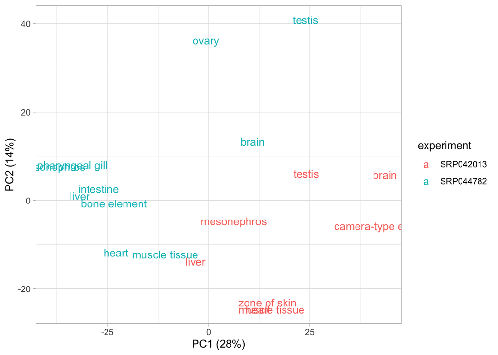

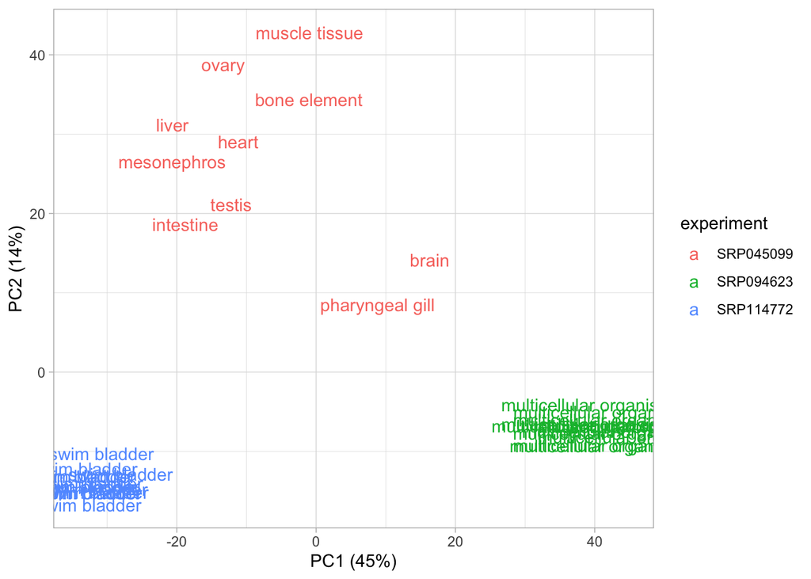

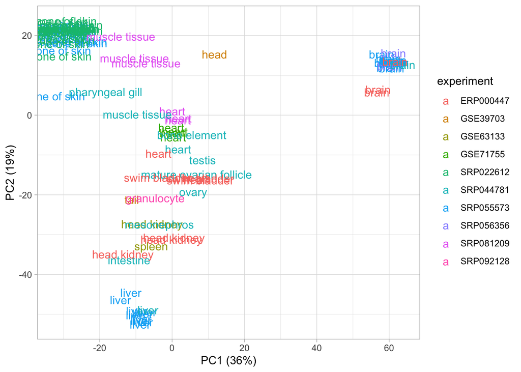

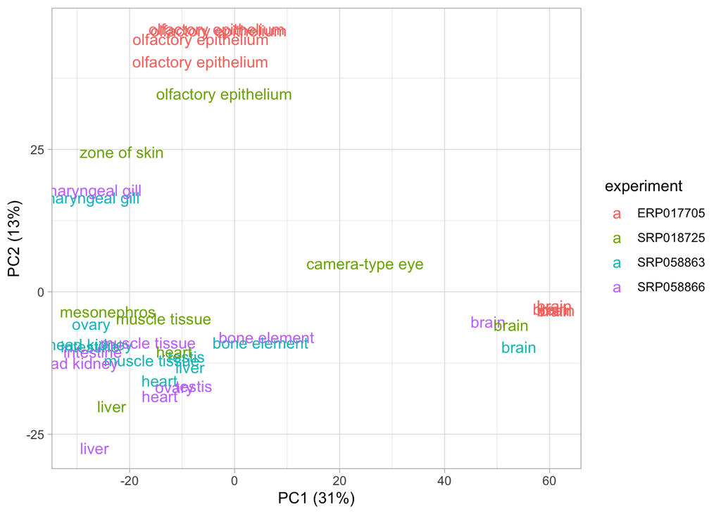

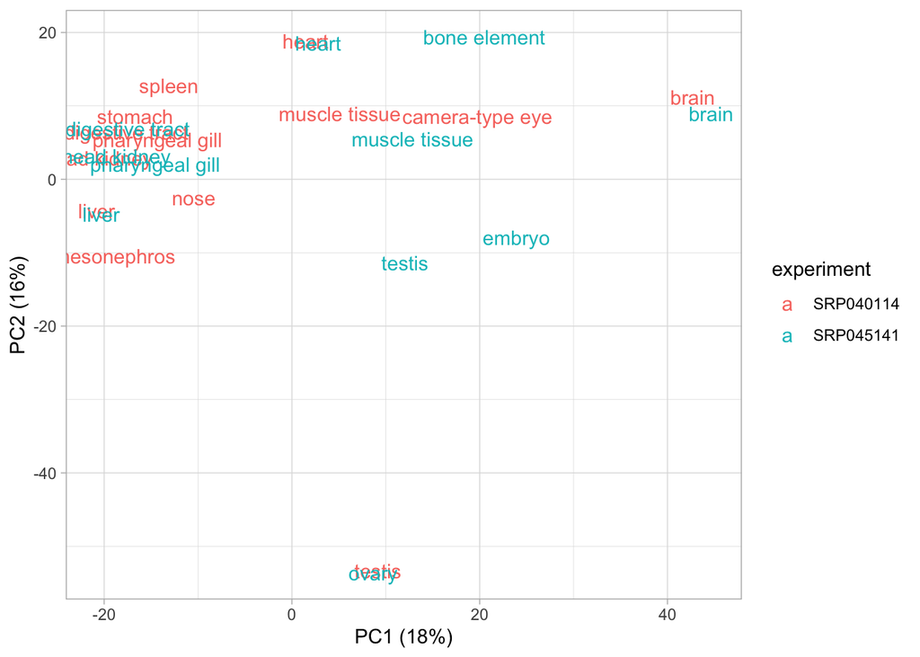

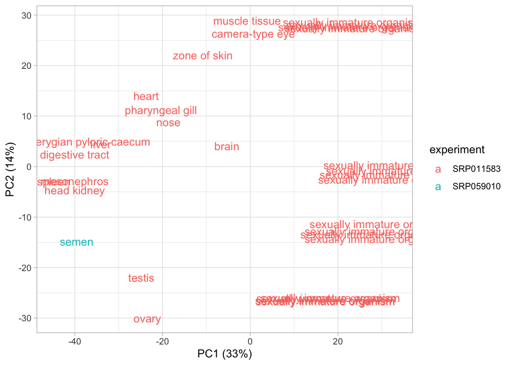

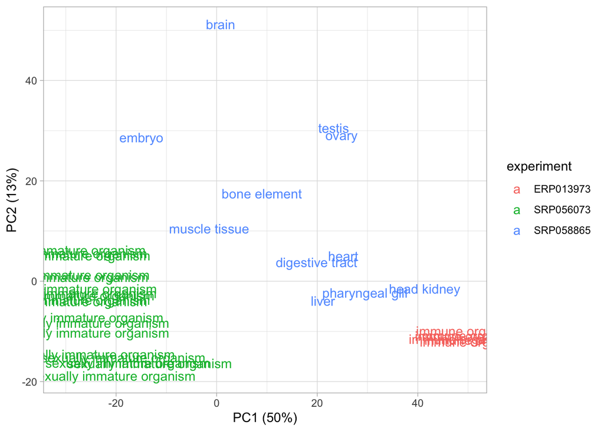

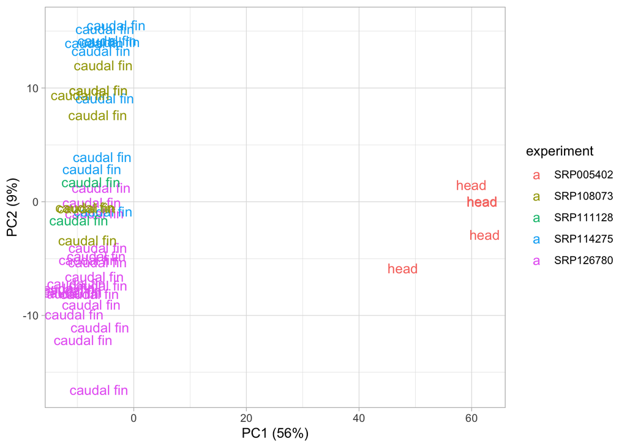

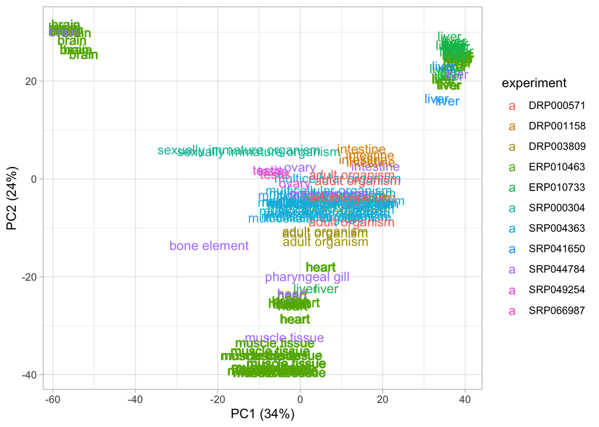

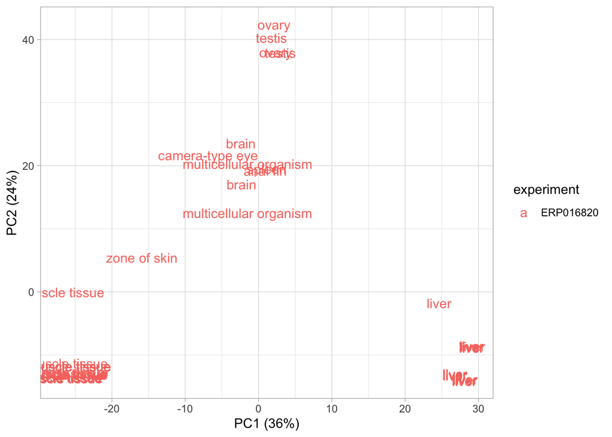

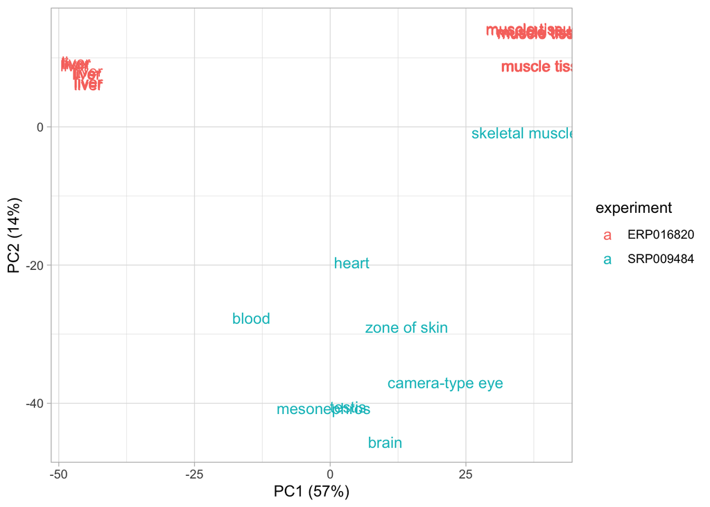

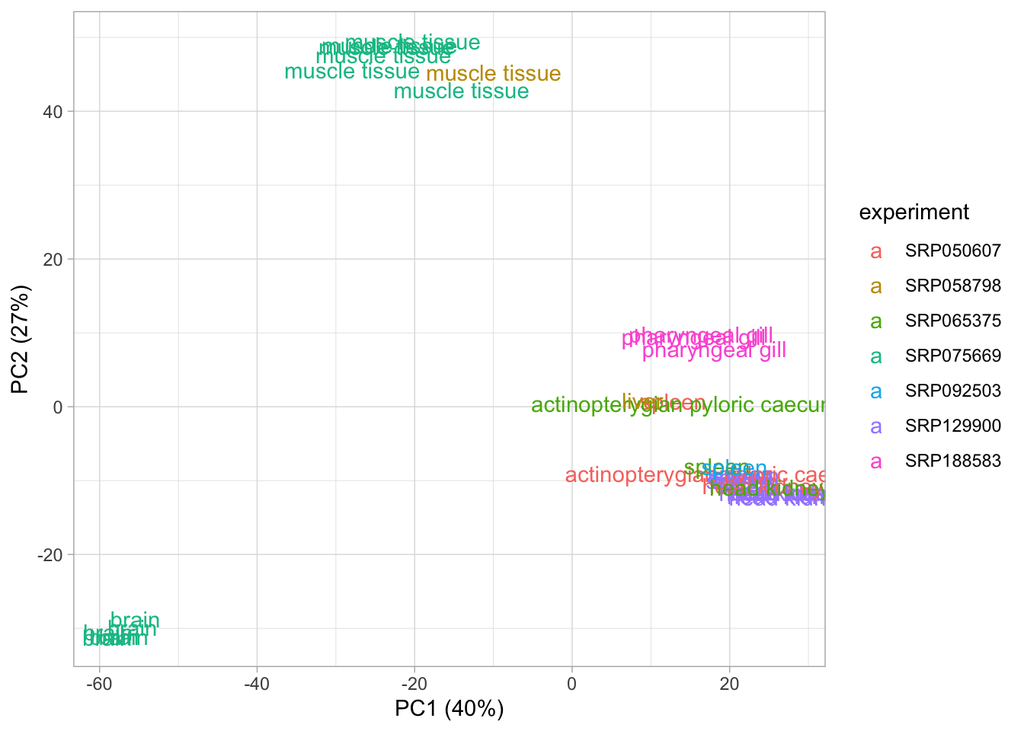

[2 more figures not shown]

```r
purrr::map(rna.dat,norm_pca)
```

### Counts normalisation

I run the TMM normalisation function and build the data frame that will be the input to compute tau.

```r
#build_tau_dataframe
Astatotilapia_calliptera_tau_input<-rna.dat$Astatotilapia_calliptera %>% TMM_norm_only() %>% as_tibble(rownames = NA) %>% rownames_to_column("Gene.ID") %>% build_tau_data_frame(var = "Astatotilapia_calliptera")

Astyanax_mexicanus_tau_input<-rna.dat$Astyanax_mexicanus %>% TMM_norm_only() %>% as_tibble(rownames = NA) %>% rownames_to_column("Gene.ID") %>% build_tau_data_frame(var = "Astyanax_mexicanus")

Danio_rerio_tau_input<-rna.dat$Danio_rerio %>% TMM_norm_only %>% as_tibble(rownames = NA) %>% rownames_to_column("Gene.ID") %>% build_tau_data_frame(var = "Danio_rerio")

Esox_lucius_tau_input<-rna.dat$Esox_lucius %>% TMM_norm_only %>% as_tibble(rownames = NA) %>% rownames_to_column("Gene.ID") %>% build_tau_data_frame(var = "Esox_lucius")

Gasterosteus_aculeatus_tau_input<-rna.dat$Gasterosteus_aculeatus %>% TMM_norm_only() %>% as_tibble(rownames = NA) %>% rownames_to_column("Gene.ID") %>% build_tau_data_frame(var = "Gasterosteus_aculeatus")

Gadus_morhua_tau_input<-rna.dat$Gadus_morhua %>% TMM_norm_only %>% as_tibble(rownames = NA) %>% rownames_to_column("Gene.ID") %>% build_tau_data_frame(var = "Gadus_morhua")

Lepisosteus_oculatus_tau_input<-rna.dat$Lepisosteus_oculatus %>% combat() %>% as_tibble(rownames = NA) %>% rownames_to_column("Gene.ID") %>% build_tau_data_frame(var = "Lepisosteus_oculatus") #Performed combat

Neolamprologus_brichardi_tau_input<-rna.dat$Neolamprologus_brichardi%>% TMM_norm_only() %>% as_tibble(rownames = NA) %>% rownames_to_column("Gene.ID") %>% build_tau_data_frame(var = "Neolamprologus_brichardi")

Nothobranchius_furzeri_tau_input<-rna.dat$Nothobranchius_furzeri %>% TMM_norm_only() %>% as_tibble(rownames = NA) %>% rownames_to_column("Gene.ID") %>% build_tau_data_frame(var = "Nothobranchius_furzeri")

Oryzias_latipes_tau_input<-rna.dat$Oryzias_latipes %>% TMM_norm_only() %>% as_tibble(rownames = NA) %>% rownames_to_column("Gene.ID") %>% build_tau_data_frame(var = "Oryzias_latipes")

Salmo_salar_tau_input<-rna.dat$Salmo_salar %>% TMM_norm_only() %>% as_tibble(rownames = NA) %>% rownames_to_column("Gene.ID") %>% build_tau_data_frame(var = "Salmo_salar")

Scophthalmus_maximus_tau_input<-rna.dat$Scophthalmus_maximus %>% TMM_norm_only() %>% as_tibble(rownames = NA) %>% rownames_to_column("Gene.ID") %>% build_tau_data_frame(var = "Scophthalmus_maximus")

list(Astyanax_mexicanus_tau_input = Astyanax_mexicanus_tau_input,
     Astatotilapia_calliptera_tau_input = Astatotilapia_calliptera_tau_input,
     Danio_rerio_tau_input = Danio_rerio_tau_input,
     Esox_lucius_tau_input = Esox_lucius_tau_input,
     Gasterosteus_aculeatus_tau_input = Gasterosteus_aculeatus_tau_input,
     Gadus_morhua_tau_input = Gadus_morhua_tau_input,
     Lepisosteus_oculatus_tau_input = Lepisosteus_oculatus_tau_input,
     Neolamprologus_brichardi_tau_input = Neolamprologus_brichardi_tau_input,
     Nothobranchius_furzeri_tau_input = Nothobranchius_furzeri_tau_input,
     Oryzias_latipes_tau_input = Oryzias_latipes_tau_input,
     Salmo_salar_tau_input = Salmo_salar_tau_input,
     Scophthalmus_maximus_tau_input = Scophthalmus_maximus_tau_input) %>% saveRDS("./RDS/Tau_input_dat_TMM_cpm_no_log_no_combat_all_fish.rds")
```

### Compute Tau

To estimate tissue specificity I used the tissue-specificity index Tau. The code below calculates tau for each tissue in each sampled species. I classify a gene as tissue-specific if it has a tau estimate above 0.8 and its mean expression level in the target tissue is higher than the sum of its expression in all the other tissues. This ensures we keep only those genes that are tissue-specific and highly expressed in their target tissues.

```r
tau_input<-readRDS("./RDS/Tau_input_dat_TMM_cpm_no_log_no_combat_all_fish.rds")

#remove unwanted and ambiguous tissues (e.g. larva, immature organism etc..)

tau_input$Astatotilapia_calliptera_tau_input %>% dplyr::select(!c(`multicellular organism`))->tau_input$Astatotilapia_calliptera_tau_input
tau_input$Danio_rerio_tau_input %>% dplyr::select(!c(`mature ovarian follicle`))->tau_input$Danio_rerio_tau_input
tau_input$Esox_lucius_tau_input %>% dplyr::select(!`embryo`)->tau_input$Esox_lucius_tau_input
tau_input$Gadus_morhua_tau_input %>% dplyr::select(!c(`embryo`,`sexually immature organism`,`immune organ`))->tau_input$Gadus_morhua_tau_input
tau_input$Gasterosteus_aculeatus_tau_input %>% dplyr::select(!c(`telencephalon`,`diencephalon`))->tau_input$Gasterosteus_aculeatus_tau_input
tau_input$Oryzias_latipes_tau_input %>% dplyr::select(!c(`multicellular organism`,`sexually immature organism`,`adult organism`))->tau_input$Oryzias_latipes_tau_input
tau_input$Salmo_salar_tau_input %>% dplyr::select(!c(semen, `sexually immature organism`))->tau_input$Salmo_salar_tau_input


# Skin
tau_input$Astatotilapia_calliptera_tau_input %>% compute_tau(tissue = "zone of skin")->Astatotilapia_calliptera_tau
tau_input$Astyanax_mexicanus_tau_input %>% compute_tau(tissue = "zone of skin")->Astyanax_mexicanus_tau
tau_input$Danio_rerio_tau_input %>% compute_tau(tissue = "zone of skin")->Danio_rerio_tau
tau_input$Gasterosteus_aculeatus_tau_input %>% compute_tau(tissue = "zone of skin")->Gasterosteus_aculeatus_tau
tau_input$Neolamprologus_brichardi_tau_input %>% compute_tau(tissue = "zone of skin")->Neolamprologus_brichardi_tau
tau_input$Nothobranchius_furzeri_tau_input %>% compute_tau(tissue = "zone of skin")->Nothobranchius_furzeri_tau
tau_input$Salmo_salar_tau_input %>% compute_tau(tissue = "zone of skin")->Salmo_salar_tau


list(Astyanax_mexicanus = Astyanax_mexicanus_tau,
     Astatotilapia_calliptera = Astatotilapia_calliptera_tau,
     Danio_rerio = Danio_rerio_tau,
     Gasterosteus_aculeatus= Gasterosteus_aculeatus_tau,
     Neolamprologus_brichardi = Neolamprologus_brichardi_tau,
     Nothobranchius_furzeri= Nothobranchius_furzeri_tau,
     Salmo_salar = Salmo_salar_tau) %>% saveRDS("./RDS/Tau_0.8_TMM_cpm_no_log_no_combat_skin.rds")

# Brain
tau_input$Astatotilapia_calliptera_tau_input %>% compute_tau(tissue = "brain")->Astatotilapia_calliptera_tau
tau_input$Astyanax_mexicanus_tau_input %>% compute_tau(tissue = "brain")->Astyanax_mexicanus_tau
tau_input$Danio_rerio_tau_input %>% compute_tau(tissue = "brain")->Danio_rerio_tau
tau_input$Esox_lucius_tau_input %>% compute_tau(tissue = "brain")->Esox_lucius_tau
tau_input$Gadus_morhua_tau_input %>% compute_tau(tissue = "brain")->Gadus_morhua_tau
tau_input$Gasterosteus_aculeatus_tau_input %>% compute_tau(tissue = "brain")->Gasterosteus_aculeatus_tau
tau_input$Neolamprologus_brichardi_tau_input %>% compute_tau(tissue = "brain")->Neolamprologus_brichardi_tau
tau_input$Nothobranchius_furzeri_tau_input %>% compute_tau(tissue = "brain")->Nothobranchius_furzeri_tau
tau_input$Oryzias_latipes_tau_input %>% compute_tau(tissue = "brain")->Oryzias_latipes_tau
tau_input$Salmo_salar_tau_input %>% compute_tau(tissue = "brain")->Salmo_salar_tau
tau_input$Scophthalmus_maximus_tau_input %>% compute_tau(tissue = "brain")->Scophthalmus_maximus_tau


list(Astyanax_mexicanus = Astyanax_mexicanus_tau,
     Astatotilapia_calliptera = Astatotilapia_calliptera_tau,
     Danio_rerio = Danio_rerio_tau,
     Esox_lucius = Esox_lucius_tau,
     Gadus_morhua = Gadus_morhua_tau,
     Gasterosteus_aculeatus= Gasterosteus_aculeatus_tau,
     Neolamprologus_brichardi = Neolamprologus_brichardi_tau,
     Nothobranchius_furzeri= Nothobranchius_furzeri_tau,
     Oryzias_latipes = Oryzias_latipes_tau,
     Salmo_salar = Salmo_salar_tau,
     Scophthalmus_maximus = Scophthalmus_maximus_tau) %>% saveRDS("./RDS/Tau_0.8_TMM_cpm_no_log_no_combat_brain.rds")

# Eye
tau_input$Astatotilapia_calliptera_tau_input %>% compute_tau(tissue = "camera-type eye")->Astatotilapia_calliptera_tau
tau_input$Astyanax_mexicanus_tau_input %>% compute_tau(tissue = "camera-type eye")->Astyanax_mexicanus_tau
tau_input$Esox_lucius_tau_input %>% compute_tau(tissue = "camera-type eye")->Esox_lucius_tau
tau_input$Gasterosteus_aculeatus_tau_input %>% compute_tau(tissue = "camera-type eye")->Gasterosteus_aculeatus_tau
tau_input$Neolamprologus_brichardi_tau_input %>% compute_tau(tissue = "camera-type eye")->Neolamprologus_brichardi_tau
tau_input$Salmo_salar_tau_input %>% compute_tau(tissue = "camera-type eye")->Salmo_salar_tau

list(Astyanax_mexicanus = Astyanax_mexicanus_tau,
     Astatotilapia_calliptera = Astatotilapia_calliptera_tau,
     Esox_lucius = Esox_lucius_tau,
     Gasterosteus_aculeatus= Gasterosteus_aculeatus_tau,
     Neolamprologus_brichardi = Neolamprologus_brichardi_tau,
     Salmo_salar = Salmo_salar_tau) %>%
  saveRDS("./RDS/Tau_0.8_TMM_cpm_no_log_no_combat_eye.rds")

# Heart
tau_input$Astyanax_mexicanus_tau_input %>% compute_tau(tissue = "heart")->Astyanax_mexicanus_tau
tau_input$Danio_rerio_tau_input %>% compute_tau(tissue = "heart")->Danio_rerio_tau
tau_input$Esox_lucius_tau_input %>% compute_tau(tissue = "heart")->Esox_lucius_tau
tau_input$Gadus_morhua_tau_input %>% compute_tau(tissue = "heart")->Gadus_morhua_tau
tau_input$Gasterosteus_aculeatus_tau_input %>% compute_tau(tissue = "heart")->Gasterosteus_aculeatus_tau
tau_input$Neolamprologus_brichardi_tau_input %>% compute_tau(tissue = "heart")->Neolamprologus_brichardi_tau
tau_input$Oryzias_latipes_tau_input %>% compute_tau(tissue = "heart")->Oryzias_latipes_tau
tau_input$Salmo_salar_tau_input %>% compute_tau(tissue = "heart")->Salmo_salar_tau


list(Astyanax_mexicanus = Astyanax_mexicanus_tau,
     Danio_rerio = Danio_rerio_tau,
     Esox_lucius = Esox_lucius_tau,
     Gadus_morhua = Gadus_morhua_tau,
     Gasterosteus_aculeatus= Gasterosteus_aculeatus_tau,
     Neolamprologus_brichardi = Neolamprologus_brichardi_tau,
     Oryzias_latipes = Oryzias_latipes_tau,
     Salmo_salar = Salmo_salar_tau) %>% saveRDS("./RDS/Tau_0.8_TMM_cpm_no_log_no_combat_heart.rds")

# Liver
tau_input$Astatotilapia_calliptera_tau_input %>% compute_tau(tissue = "liver")->Astatotilapia_calliptera_tau
tau_input$Astyanax_mexicanus_tau_input %>% compute_tau(tissue = "liver")->Astyanax_mexicanus_tau
tau_input$Danio_rerio_tau_input %>% compute_tau(tissue = "liver")->Danio_rerio_tau
tau_input$Esox_lucius_tau_input %>% compute_tau(tissue = "liver")->Esox_lucius_tau
tau_input$Gadus_morhua_tau_input %>% compute_tau(tissue = "liver")->Gadus_morhua_tau
tau_input$Gasterosteus_aculeatus_tau_input %>% compute_tau(tissue = "liver")->Gasterosteus_aculeatus_tau
tau_input$Neolamprologus_brichardi_tau_input %>% compute_tau(tissue = "liver")->Neolamprologus_brichardi_tau
tau_input$Nothobranchius_furzeri_tau_input %>% compute_tau(tissue = "liver")->Nothobranchius_furzeri_tau
tau_input$Oryzias_latipes_tau_input %>% compute_tau(tissue = "liver")->Oryzias_latipes_tau
tau_input$Salmo_salar_tau_input %>% compute_tau(tissue = "liver")->Salmo_salar_tau
tau_input$Scophthalmus_maximus_tau_input %>% compute_tau(tissue = "liver")->Scophthalmus_maximus_tau


list(Astyanax_mexicanus = Astyanax_mexicanus_tau,
     Astatotilapia_calliptera = Astatotilapia_calliptera_tau,
     Danio_rerio = Danio_rerio_tau,
     Esox_lucius = Esox_lucius_tau,
     Gadus_morhua = Gadus_morhua_tau,
     Gasterosteus_aculeatus= Gasterosteus_aculeatus_tau,
     Neolamprologus_brichardi = Neolamprologus_brichardi_tau,
     Nothobranchius_furzeri= Nothobranchius_furzeri_tau,
     Oryzias_latipes = Oryzias_latipes_tau,
     Salmo_salar = Salmo_salar_tau,
     Scophthalmus_maximus = Scophthalmus_maximus_tau) %>% saveRDS("./RDS/Tau_0.8_TMM_cpm_no_log_no_combat_liver.rds")

# Muscle tissue
tau_input$Astatotilapia_calliptera_tau_input %>% compute_tau(tissue = "muscle tissue")->Astatotilapia_calliptera_tau
tau_input$Astyanax_mexicanus_tau_input %>% compute_tau(tissue = "muscle tissue")->Astyanax_mexicanus_tau
tau_input$Danio_rerio_tau_input %>% compute_tau(tissue = "muscle tissue")->Danio_rerio_tau
tau_input$Esox_lucius_tau_input %>% compute_tau(tissue = "muscle tissue")->Esox_lucius_tau
tau_input$Gadus_morhua_tau_input %>% compute_tau(tissue = "muscle tissue")->Gadus_morhua_tau
tau_input$Gasterosteus_aculeatus_tau_input %>% compute_tau(tissue = "muscle tissue")->Gasterosteus_aculeatus_tau
tau_input$Neolamprologus_brichardi_tau_input %>% compute_tau(tissue = "skeletal muscle tissue")->Neolamprologus_brichardi_tau
tau_input$Oryzias_latipes_tau_input %>% compute_tau(tissue = "muscle tissue")->Oryzias_latipes_tau
tau_input$Salmo_salar_tau_input %>% compute_tau(tissue = "muscle tissue")->Salmo_salar_tau
tau_input$Scophthalmus_maximus_tau_input %>% compute_tau(tissue = "muscle tissue")->Scophthalmus_maximus_tau


list(Astyanax_mexicanus = Astyanax_mexicanus_tau,
     Astatotilapia_calliptera = Astatotilapia_calliptera_tau,
     Danio_rerio = Danio_rerio_tau,
     Esox_lucius = Esox_lucius_tau,
     Gadus_morhua = Gadus_morhua_tau,
     Gasterosteus_aculeatus= Gasterosteus_aculeatus_tau,
     Neolamprologus_brichardi = Neolamprologus_brichardi_tau,
     Oryzias_latipes = Oryzias_latipes_tau,
     Salmo_salar = Salmo_salar_tau,
     Scophthalmus_maximus = Scophthalmus_maximus_tau) %>% saveRDS("./RDS/Tau_0.8_TMM_cpm_no_log_no_combat_muscle.rds")

# Ovary
tau_input$Astatotilapia_calliptera_tau_input %>% compute_tau(tissue = "ovary")->Astatotilapia_calliptera_tau
tau_input$Astyanax_mexicanus_tau_input %>% compute_tau(tissue = "ovary")->Astyanax_mexicanus_tau
tau_input$Danio_rerio_tau_input %>% compute_tau(tissue = "ovary")->Danio_rerio_tau
tau_input$Esox_lucius_tau_input %>% compute_tau(tissue = "ovary")->Esox_lucius_tau
tau_input$Gadus_morhua_tau_input %>% compute_tau(tissue = "ovary")->Gadus_morhua_tau
tau_input$Oryzias_latipes_tau_input %>% compute_tau(tissue = "ovary")->Oryzias_latipes_tau
tau_input$Salmo_salar_tau_input %>% compute_tau(tissue = "ovary")->Salmo_salar_tau


list(Astyanax_mexicanus = Astyanax_mexicanus_tau,
     Astatotilapia_calliptera = Astatotilapia_calliptera_tau,
     Danio_rerio = Danio_rerio_tau,
     Esox_lucius = Esox_lucius_tau,
     Gadus_morhua = Gadus_morhua_tau,
     Oryzias_latipes = Oryzias_latipes_tau,
     Salmo_salar = Salmo_salar_tau) %>% saveRDS("./RDS/Tau_0.8_TMM_cpm_no_log_no_combat_ovary.rds")

# Testis
tau_input$Astatotilapia_calliptera_tau_input %>% compute_tau(tissue = "testis")->Astatotilapia_calliptera_tau
tau_input$Astyanax_mexicanus_tau_input %>% compute_tau(tissue = "testis")->Astyanax_mexicanus_tau
tau_input$Danio_rerio_tau_input %>% compute_tau(tissue = "testis")->Danio_rerio_tau
tau_input$Esox_lucius_tau_input %>% compute_tau(tissue = "testis")->Esox_lucius_tau
tau_input$Gadus_morhua_tau_input %>% compute_tau(tissue = "testis")->Gadus_morhua_tau
tau_input$Gasterosteus_aculeatus_tau_input %>% compute_tau(tissue = "testis")->Gasterosteus_aculeatus_tau
tau_input$Neolamprologus_brichardi_tau_input %>% compute_tau(tissue = "testis")->Neolamprologus_brichardi_tau
tau_input$Oryzias_latipes_tau_input %>% compute_tau(tissue = "testis")->Oryzias_latipes_tau
tau_input$Salmo_salar_tau_input %>% compute_tau(tissue = "testis")->Salmo_salar_tau

list(Astyanax_mexicanus = Astyanax_mexicanus_tau,
     Astatotilapia_calliptera = Astatotilapia_calliptera_tau,
     Danio_rerio = Danio_rerio_tau,
     Esox_lucius = Esox_lucius_tau,
     Gadus_morhua = Gadus_morhua_tau,
     Gasterosteus_aculeatus= Gasterosteus_aculeatus_tau,
     Neolamprologus_brichardi = Neolamprologus_brichardi_tau,
     Oryzias_latipes = Oryzias_latipes_tau,
     Salmo_salar = Salmo_salar_tau) %>% saveRDS("./RDS/Tau_0.8_TMM_cpm_no_log_no_combat_testis.rds")
```

### Plot tissue specific genes

Here are the distribution of the tissue specific genes across the different teleost species.

```r
#tissue specific genes
skin<-readRDS("./RDS/Tau_0.8_TMM_cpm_no_log_no_combat_skin.rds")
brain<-readRDS("./RDS/Tau_0.8_TMM_cpm_no_log_no_combat_brain.rds")
eye<-readRDS("./RDS/Tau_0.8_TMM_cpm_no_log_no_combat_eye.rds")
heart<-readRDS("./RDS/Tau_0.8_TMM_cpm_no_log_no_combat_heart.rds")
liver<-readRDS("./RDS/Tau_0.8_TMM_cpm_no_log_no_combat_liver.rds")
muscle<-readRDS("./RDS/Tau_0.8_TMM_cpm_no_log_no_combat_muscle.rds")
ovary<-readRDS("./RDS/Tau_0.8_TMM_cpm_no_log_no_combat_ovary.rds")
testis<-readRDS("./RDS/Tau_0.8_TMM_cpm_no_log_no_combat_testis.rds")



ts_plot<-function(species){
rbind(tibble(ts = length(brain[[species]]$Gene.ID),
       tissue = "brain"),
tibble(ts = length(eye[[species]]$Gene.ID),
       tissue = "eye"),
tibble(ts = length(heart[[species]]$Gene.ID),
       tissue = "heart"),
tibble(ts = length(liver[[species]]$Gene.ID),
       tissue = "liver"),
tibble(ts = length(muscle[[species]]$Gene.ID),
       tissue = "muscle"),
tibble(ts = length(skin[[species]]$Gene.ID),
       tissue = "skin"),
tibble(ts = length(ovary[[species]]$Gene.ID),
       tissue = "ovary"),
tibble(ts = length(testis[[species]]$Gene.ID),
       tissue = "testis"))->ts_df

p<-ggpubr::ggbarplot(ts_df, x = "tissue", y = "ts",fill = "grey",color = "grey",label = T,lab.pos = "out",lab.col = "darkred")+
  ggpubr::rremove("legend")+
  ggpubr::rremove("xlab")+
  ggpubr::rremove("ylab")+
  ggtitle(str_replace(species,pattern = "_",replacement = " "))+
  theme(plot.title = element_text(hjust = 0.5,vjust = -0.5,face = "italic")) %>% return() # Center the title
#ggpubr::ggpar(p,title = str_replace(species,pattern = "_",replacement = " "),font.title = c(14,"italic","black"),title.position = "center") %>% return()
}

purrr::map(names(brain),ts_plot)->plot_list
```

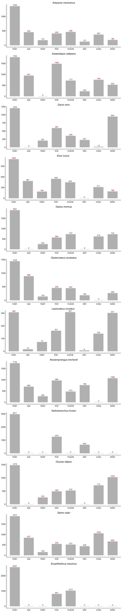

```r
ggpubr::ggarrange(plotlist = plot_list,ncol = 1,nrow = 12)
```

## Processing CSUBST output

In this section, I load the results of CSUBST and process them to obtain the first list of genes that satisfy the criteria for convergence. The final output *combined_arity* will be used to get the set of branch combinations.

### Get the data

```r
dir_path<-str_c("./Datasets/Output_CSUBST")

combine_csubsts<-function(.data){
  og<-str_extract(.data,"OG[0-9]*")
  try(read_tsv(.data) %>% mutate(Orthogroup = og) %>%
    mutate(arity = (str_extract(files,"_[0-9]") %>% str_remove("_"))[[1]]) %>%
    dplyr::select(c(Orthogroup,is_fg,omegaCany2spe,omegaCany2any,OCNany2any,OCNspe2any,OCNany2spe,OCSany2any,OCSspe2any,OCSany2spe,dNCany2spe,dNCany2any,dSCany2spe,dSCany2any,arity,contains("branch_id"))) %>%
    filter(omegaCany2spe >=5 & OCNany2spe >=5)) %>%
    return()

  #To compare differences in mean OCN values between convergent-tissue specific genes remove the filters so as to get the values of the entire population
}


files<-list.files(path = dir_path, pattern = "\\cb_3.tsv$", full.names = TRUE, recursive = TRUE)
purrr::map(files,combine_csubsts) %>% purrr:::list_rbind()->Arity_3
Arity_3 %>% distinct(Orthogroup)->Arity_3_OG

files<-list.files(path = dir_path, pattern = "\\cb_4.tsv$", full.names = TRUE, recursive = TRUE)
purrr::map(files,combine_csubsts) %>% purrr:::list_rbind()->Arity_4
Arity_4 %>% distinct(Orthogroup)->Arity_4_OG

files<-list.files(path = dir_path, pattern = "\\cb_5.tsv$", full.names = TRUE, recursive = TRUE)
purrr::map(files,combine_csubsts) %>% purrr:::list_rbind()->Arity_5
Arity_5 %>% distinct(Orthogroup)->Arity_5_OG

files<-list.files(path = dir_path, pattern = "\\cb_6.tsv$", full.names = TRUE, recursive = TRUE)
purrr::map(files,combine_csubsts) %>% purrr:::list_rbind()->Arity_6
Arity_6 %>% distinct(Orthogroup)->Arity_6_OG

files<-list.files(path = dir_path, pattern = "\\cb_7.tsv$", full.names = TRUE, recursive = TRUE)
purrr::map(files,combine_csubsts) %>% purrr:::list_rbind()->Arity_7
Arity_7 %>% distinct(Orthogroup)->Arity_7_OG

files<-list.files(path = dir_path, pattern = "\\cb_8.tsv$", full.names = TRUE, recursive = TRUE)
purrr::map(files,combine_csubsts) %>% purrr:::list_rbind()->Arity_8
Arity_8 %>% distinct(Orthogroup)->Arity_8_OG

files<-list.files(path = dir_path, pattern = "\\cb_9.tsv$", full.names = TRUE, recursive = TRUE)
purrr::map(files,combine_csubsts) %>% purrr:::list_rbind()->Arity_9
Arity_9 %>% distinct(Orthogroup)->Arity_9_OG

files<-list.files(path = dir_path, pattern = "\\cb_10.tsv$", full.names = TRUE, recursive = TRUE)
purrr::map(files,combine_csubsts) %>% purrr:::list_rbind()->Arity_10
Arity_10 %>% distinct(Orthogroup)->Arity_10_OG


combined_arity<-bind_rows(Arity_3 %>% dplyr::select(Orthogroup,omegaCany2spe,OCNany2any,OCNspe2any,OCNany2spe,OCSany2any,OCSspe2any,OCSany2spe,dNCany2spe,dSCany2spe,arity,contains("branch_id")),
                          Arity_4 %>% dplyr::select(Orthogroup,omegaCany2spe,OCNany2any,OCNspe2any,OCNany2spe,OCSany2any,OCSspe2any,OCSany2spe,dNCany2spe,dSCany2spe,arity,contains("branch_id")),
                          Arity_5 %>% dplyr::select(Orthogroup,omegaCany2spe,OCNany2any,OCNspe2any,OCNany2spe,OCSany2any,OCSspe2any,OCSany2spe,dNCany2spe,dSCany2spe,arity,contains("branch_id")),
                          Arity_6 %>% dplyr::select(Orthogroup,omegaCany2spe,OCNany2any,OCNspe2any,OCNany2spe,OCSany2any,OCSspe2any,OCSany2spe,dNCany2spe,dSCany2spe,arity,contains("branch_id")),
                          Arity_7 %>% dplyr::select(Orthogroup,omegaCany2spe,OCNany2any,OCNspe2any,OCNany2spe,OCSany2any,OCSspe2any,OCSany2spe,dNCany2spe,dSCany2spe,arity,contains("branch_id")),
                          Arity_8 %>% dplyr::select(Orthogroup,omegaCany2spe,OCNany2any,OCNspe2any,OCNany2spe,OCSany2any,OCSspe2any,OCSany2spe,dNCany2spe,dSCany2spe,arity,contains("branch_id")),
                          Arity_9 %>% dplyr::select(Orthogroup,omegaCany2spe,OCNany2any,OCNspe2any,OCNany2spe,OCSany2any,OCSspe2any,OCSany2spe,dNCany2spe,dSCany2spe,arity,contains("branch_id")),
                          Arity_10 %>% dplyr::select(Orthogroup,omegaCany2spe,OCNany2any,OCNspe2any,OCNany2spe,OCSany2any,OCSspe2any,OCSany2spe,dNCany2spe,dSCany2spe,arity,contains("branch_id")))

combined_arity$arity <-str_replace(combined_arity$arity,'1','10')
combined_arity %>% saveRDS("./RDS/combined_arity.rds")
```

### Make table to use for csusbt site input

I now get the sets of branch combinations (arity) I will use as input for the CSUBST site algorithm.

```r
#To make the table for the CSUBST site algorithm we will group by orthogroup and select the branch combinations with the highest arity values.
#Once computed, filter the site_table data frame to obtain the convergence metrics for the non-spurious convergent genes
make_site_data<-function(tissue,fname){
  carity_tsp<-combined_arity
  site_table<-carity_tsp %>% group_by(Orthogroup) %>% dplyr::slice(which.max(arity))
  site_table %>% return()
#Arity 3
site_table %>% dplyr::filter(arity == 3) %>%
  dplyr::select(Orthogroup,contains("branch_id")) %>%
  select_if(~ !any(is.na(.))) %>%
  write_csv(paste0("./Datasets/DatasetS0_csv_files/csubst_site_input/",fname,"_Arity_3.csv"))
#Arity 4
site_table %>% dplyr::filter(arity == 4) %>%
  dplyr::select(Orthogroup,contains("branch_id")) %>%
  select_if(~ !any(is.na(.))) %>%
  write_csv(paste0("./Datasets/DatasetS0_csv_files/csubst_site_input/",fname,"_Arity_4.csv"))
#Arity 5
site_table %>% filter(arity == 5) %>%
  dplyr::select(Orthogroup,contains("branch_id")) %>%
  select_if(~ !any(is.na(.))) %>%
  write_csv(paste0("./Datasets/DatasetS0_csv_files/csubst_site_input/",fname,"_Arity_5.csv"))
#Arity 6
site_table %>% filter(arity == 6) %>%
  dplyr::select(Orthogroup,contains("branch_id")) %>%
  select_if(~ !any(is.na(.))) %>%
  write_csv(paste0("./Datasets/DatasetS0_csv_files/csubst_site_input/",fname,"_Arity_6.csv"))
#Arity 7
site_table %>% filter(arity == 7) %>%
  dplyr::select(Orthogroup,contains("branch_id")) %>%
  select_if(~ !any(is.na(.))) %>%
  write_csv(paste0("./Datasets/DatasetS0_csv_files/csubst_site_input/",fname,"_Arity_7.csv"))
#Arity 8
site_table %>% filter(arity == 8) %>%
  dplyr::select(Orthogroup,contains("branch_id")) %>%
  select_if(~ !any(is.na(.))) %>%
  write_csv(paste0("./Datasets/DatasetS0_csv_files/csubst_site_input/",fname,"_Arity_8.csv"))
#Arity 9
site_table %>% filter(arity == 9) %>%
  dplyr::select(Orthogroup,contains("branch_id")) %>%
  select_if(~ !any(is.na(.))) %>%
  write_csv(paste0("./Datasets/DatasetS0_csv_files/csubst_site_input/",fname,"_Arity_9.csv"))
#Arity 10
site_table %>% filter(arity == 10) %>%
  dplyr::select(Orthogroup,contains("branch_id")) %>%
  select_if(~ !any(is.na(.))) %>%
  write_csv(paste0("./Datasets/DatasetS0_csv_files/csubst_site_input/",fname,"_Arity_10.csv"))
}

make_site_data(tissue = combined_arity$Orthogroup,fname = "All")
```

### Check site model output for spurious amino acids substitutions.

In this section, I check for spurious convergence using several filtering and summary steps. Essentially, the idea is to find strong evidence of convergence by filtering values of the convergence metric *OCNany2spe* and filter out substitutions that are too close to one another on the protein structure. The non-spurious substitutions can be found in electronic supplementary material DatasetS6. The examples of spurious substitutions can be found in the electronic supplementary material DatasetS7. The final output *non_spuroius_conv* has the list of orthologs that satisfy my criteria.

```r
files<-list.files(path = paste0("./Datasets/DatasetS6_Non_spurious_convergence"), pattern = "\\.tsv$", full.names = TRUE, recursive = TRUE)
trees<-list.files(path = paste0("./Datasets/DatasetS6_Non_spurious_convergence"), pattern = "\\csubst_tree.nwk$", full.names = TRUE, recursive = TRUE)
trees_df<-data.frame(id = str_extract(trees, "OG\\d{7}"),
                     tree_file = trees)
not_req<-list.files(path = paste0("./Datasets/DatasetS6_Non_spurious_convergence"), pattern = "\\csubst_site.state.*.tsv$", full.names = TRUE, recursive = TRUE)
identifiers<-str_extract(files, "OG\\d{7}")
file_df<-data.frame(id = identifiers,tsv_file = files) %>% distinct(tsv_file,.keep_all = T)
file_df<-file_df %>% filter(!tsv_file %in% not_req)
file_df<-file_df %>% mutate(model_name = purrr::map_chr(str_split(file_df$tsv_file,pattern = '\\.'),4)) %>%
  mutate(aln_file = str_replace(file_df$tsv_file,"tsv","fa")) %>%
  mutate(branches = str_extract(file_df$tsv_file,"branch_id.*/") %>% str_remove("branch_id") %>% str_remove("\\/"))
file_df<-left_join(file_df,trees_df) %>% distinct(id,.keep_all = T)


check_spurious_convergence <- function(x) {
  library(tidyverse)
  tryCatch({
    # Extract OG name
    og_name <- str_extract(x, "OG\\d{7}")
    dat_prelim <- read_tsv(x)
    dat_filter<-dat_prelim %>% filter(OCNany2spe != 0)
    mean_OCNany2spe <- mean(dat_filter$OCNany2spe, na.rm = TRUE)
#select only the sites with high OCN value. This helps reduce false positives
    if (!is.na(mean_OCNany2spe) && mean_OCNany2spe >= 0.6) {
      dat <- read_tsv(x)
      d <- dat %>% mutate(conv = ifelse(dat$OCNany2spe > 0.7, 1, 0)) %>% dplyr::select(codon_site_alignment, conv)
      d2 <- d %>% filter(conv == 1)
      #Adjust the value(0.5, here) to get sites not close to each other
      if ((d2$codon_site_alignment[length(d2$codon_site_alignment)] - d2$codon_site_alignment[1]) / length(d$codon_site_alignment) >= 0.2) {
        return(og_name)
      }
    }
    else {
      return(NULL)
      }
    })
}

make_spurious_plot<-function(x){
  library(ggpubr)
  og_name<-str_extract(x,"OG\\d{7}")
  dat<-read_tsv(x)
  d<-dat %>% mutate(conv = ifelse(dat$OCNany2spe >= 0.8, 1,0)) %>% dplyr::select(codon_site_alignment,conv)

  p<-ggpubr::ggbarplot(d,x = "codon_site_alignment", y = "conv", color = "red3")+
    ylim(0,2)+
    xlab(og_name)+
    rremove("ticks")+
    rremove("x.text")+
    rremove("y.text")

  ggsave(plot = p, filename = paste0("./Plots/Spurious_site/",og_name,".pdf"),device = "pdf")
}

#Get the list of Orthologs without spurious convergence
purrr::map(file_df$tsv_file,check_spurious_convergence) %>% discard(is.null) %>% list_c()->non_spuroius_conv
non_spuroius_conv %>% write_csv("./Datasets/DatasetS0_csv_files/Non_spurious_conv.csv")
#Make a rudimentary bar plot to observe the distribution on sites along the protein structure. This is similar to the output produced by the CSUBST site algorithm (allows for quicker run through)
purrr::map(file_df %>% filter(id %in% non_spuroius_conv) %>% pull('tsv_file'),make_spurious_plot) # I have not included these plots in the data folder. Please refer to the original output from the CSUBST site algorithm in the site_csubst folder
```

### Visualise convergent branches

The following piece of code is used to visualise the gene trees, convergent branch combinations, and the alignments of the convergent sites. This piece of code produces the figures in the DatasetS8_Gene_trees_and_alignments folder.

```r
csubst_vis<-function(OG){
  library(ggmsa)
  library(Biostrings)
  library(ape)
  library(ggtree)
  library(treeio)
  library(RColorBrewer)
  library(pals)

  extract_numerical_node_labels = function(tree) { #from Kenji Fukushima
    labels = c(tree[['tip.label']], tree[['node.label']])
    numerical_labels = as.integer(sub('.*\\|([0-9]*)$', '\\1', labels))
    numerical_labels[is.na(numerical_labels)] = -1
    label_names = sub('(.*)\\|[0-9]*$', '\\1', labels)
    tip_names = label_names[1:length(tree[['tip.label']])]
    node_names = label_names[(length(tree[['tip.label']])+1):length(label_names)]
    tree[['tip.label']] = tip_names
    tree[['node.label']] = node_names
    attr(tree, 'numerical_label') = numerical_labels
    return(tree)
  }
  file_df<-file_df %>% filter(id == OG)
#tree section
  tree<-read.newick(file_df$tree_file)
  tree<-extract_numerical_node_labels(tree)
  p<-ggtree(tree,branch.length = "none")
  data<-p$data
  sp <- c("Anguilla_anguilla","Girardinichthys_multiradiatus","Nothobranchius_furzeri","Gambusia_affinis","Poecilia_reticulata","Xiphophorus_hellerii","Xiphophorus_couchianus","Xiphophorus_maculatus","Nematolebias_whitei","Megalops_atlanticus","Dallia_pectoralis","Parambassis_ranga","Etheostoma_spectabile","Etheostoma_cragini","Perca_fluviatilis","Perca_flavescens","Salvelinus_namaycush") # I did not use, or need to label specific species. Keeping in case any user wishes to do so.


  data<-p$data %>%  mutate(is_fg = sapply(label, function(x) any(str_detect(x, sp))))
  nodes_to_connect<-file_df$branches
  nodes_to_connect<-as.numeric(str_split(nodes_to_connect,",")[[1]])
  data_to_connect <- subset(data, numerical_label %in% nodes_to_connect) %>% arrange(desc(angle)) %>%
    dplyr::select(label,x,y,angle) %>% dplyr::rename(x.connect = x, y.connect = y, angle.connect = angle)
#MSA section
  protein_sequences <- Biostrings::readAAStringSet(file_df$aln_file)
  protein_sequences <- protein_sequences[!grepl(file_df$model_name,names(protein_sequences))]
  site_tsv<-read_tsv(file_df$tsv_file) %>%
  filter(OCNany2spe >= 0.5) %>% arrange(codon_site_alignment)

  make_tidy_msa<-function(x){
    msa<-tidy_msa(protein_sequences,start = x,end = x)
    msa<-msa %>% separate(name, into = c("label","n2"),sep = "\\|") %>% dplyr::select(!n2) %>%
      return()
  }

  dat_msa<-purrr::map(site_tsv$codon_site_alignment,make_tidy_msa) %>% list_rbind()
  dat_msa$position<-as.numeric(factor(dat_msa$position))
  data<-left_join(data,data_to_connect,keep = T) %>% dplyr::rename(label = label.x) %>% arrange(desc(angle.connect))
  p$data<-data
  h<-(p$data %>% filter(isTip == T) %>% nrow())/13
#custom color; I use this one
  my_pal <- colorRampPalette(rev(brewer.pal(n = 9, name = "Reds")))

  #this is an alternate palette that users can use.
  my_custom <- data.frame(names = c(LETTERS[1:26],"-"),
                           color = c("#DABF25","grey70","#2540DA",
                                     "#2540DA","#2540DA","#DABF25",
                                     "#2540DA","#2540DA","#DABF25",
                                     "grey70","#2540DA","#DABF25",
                                     "#DABF25","#2540DA","grey70",
                                     "#DABF25","#2540DA","#2540DA",
                                     "#2540DA","#2540DA","grey70",
                                     "#DABF25","#DABF25","#DABF25",
                                     "#2540DA","#2540DA","grey75"),
                           stringsAsFactors = FALSE)
  my_custom2<-data.frame(names = c(LETTERS[1:26],"-"),
                           color = c(my_pal(27)),
                           stringsAsFactors = FALSE)
#plotting section
  p <- p + geom_tree(mapping = aes(color = is_fg),show.legend=FALSE) + scale_color_manual(values = c("TRUE" = "grey50", "FALSE" = "grey50"))#
  p <- p + geom_tiplab(size = 7, as_ylab = T)#+scale_color_manual(values = c("TRUE"="grey50","FALSE"="grey50"))#
  p <- p + geom_point2(aes(x = x.connect-0.01, y = y.connect), color = '#274DD8', size = 2)
  p <- p + geom_curve(aes(x = x.connect-0.01, y = y.connect, xend = lead(x.connect), yend = lead(y.connect)), curvature = 0.1, color = "#274DD8") # get the line connecting convergent branches
  p <- p + geom_facet(geom = geom_msa, data = dat_msa,  panel = "msa", font = NULL, custom_color = my_custom2,char_width = 0.5)
  p <- p + geom_facet(geom = geom_text, data = dat_msa, panel= "msa", mapping=aes(x=position, label=character), size=2, color='grey90')

  p <- facet_widths(p, width=c(1,length(unique(dat_msa$position))/(ifelse(length(unique(dat_msa$position)) > 4,40,10))))

  ggplot2::ggsave(plot = p,
                  filename = paste0("./Plots/Phylogenies/",OG,"_site",".svg"),
                  width = 10,
                  height = h,
                  units = "in",
                  scale = 1,
                  limitsize = F)
}

# Run the visualisation function on the non spurious convergence results

try(purrr::map(file_df %>% filter(id %in% non_spuroius_conv) %>% pull('id'), csubst_vis))
```

## Distribution of convergent genes

This section deals with looking at the distribution of the species that experience convergence to examine whether there are any patterns in the distribution of convergent genes across orders or species, and to get an idea of zoological traits the convergent genes might be influencing.

```r
conv_sp<-read_csv("./Datasets/DatasetS0_csv_files/Convergence_in_species.csv")
fish_data<-read.csv("./Datasets/DatasetS0_csv_files/Fish_data.csv")
danio_conv<-read.csv("./Datasets/DatasetS0_csv_files/Danio_rerio_convergent_genes.csv")
tax_info_conv<-left_join(conv_sp,fish_data, by = "Species")
orth_list<-readRDS("./RDS/large_fish_tree_all_orders.rds")
orth_list<-orth_list %>% mutate(orths =  str_remove(orth_list$orths,"..$"))
orth_list<-orth_list %>% mutate(Order = if_else(Order == "Carangaria", "Carangiformes", Order)) #Fix order name
orth_list<-left_join(orth_list %>% dplyr::rename(Species = sp),fish_data %>% dplyr::select(c(Species,Family)),by = "Species")
non_spuroius_conv<-read_csv("Datasets/DatasetS0_csv_files/Non_spurious_conv.csv")
seq_stat<-read_tsv("./Datasets/DatasetS0_csv_files/seq_stats.tsv") #use the seqkit toolkit (https://bioinf.shenwei.me/seqkit/) to obtain this
combined_arity <-readRDS("./RDS/combined_arity.rds")
#All convergent genes in all species and orders
left_join(tax_info_conv,danio_conv %>% dplyr::select(Orthogroup,Gene.name,Gene.description),by = "Orthogroup") %>% distinct(Protein_id, .keep_all = T)->tax_info_conv
```

### Number of convergent genes in each order

```r
tax_info_conv %>% dplyr::count(Order) %>% arrange(desc(n))
```

| Order | n |
| --- | --- |
| Perciformes | 87 |
| Acanthuriformes | 39 |
| Cyprinodontiformes | 35 |
| Cichliformes | 32 |
| Carangiformes | 31 |
| Ovalentaria | 24 |
| Tetraodontiformes | 22 |
| Anabantiformes | 21 |
| Pleuronectiformes | 20 |
| Siluriformes | 17 |

[output cut: 28 more lines]

```r
left_join(fish_data %>% dplyr::count(Order),
          tax_info_conv %>% dplyr::count(Order),by = 'Order',suffix = c(".sp.order",".estimated")) %>%
  replace(is.na(.), 0) %>% dplyr::select(Order,n.estimated)->test_dat

#Total number of genes in each order
left_join(orth_list %>% filter(Orthogroup %in% non_spuroius_conv$Orthogroup) %>% summarise(n.sampled = n(),.by = "Order"),test_dat)->test_dat_order
#fill in m,issing data
test_dat_order$Order[is.na(test_dat_order$Order)]<-"Lampriformes"
test_dat_order$n.sampled[is.na(test_dat_order$n.sampled)]<-1
test_dat_order$n.estimated[is.na(test_dat_order$n.estimated)]<-1
```

### Number of convergent genes in each family

```r
tax_info_conv %>% dplyr::count(Family) %>% arrange(desc(n))
```

| Family | n |
| --- | --- |
| Cichlidae | 32 |
| Percidae | 24 |
| Tetraodontidae | 22 |
| Echeneidae | 20 |
| Sciaenidae | 20 |
| Poeciliidae | 19 |
| Gobiesocidae | 16 |
| Oxudercidae | 16 |
| Salmonidae | 16 |
| Sparidae | 16 |

[output cut: 63 more lines]

```r
left_join(fish_data %>% dplyr::count(Family),
          tax_info_conv %>% dplyr::count(Family),by = 'Family',suffix = c(".sp.family",".estimated")) %>%
  replace(is.na(.), 0) %>% dplyr::select(Family,n.estimated)->test_dat_family

#Total number of genes in each family
left_join(orth_list %>% filter(Orthogroup %in% non_spuroius_conv$Orthogroup) %>% summarise(n.sampled = n(),.by = "Family"),test_dat_family)->test_dat_family
```

### Comparing the distributions of convergent genes

Here I use the Kolmogorov-Smirnov test (KS test) to compare the distributions of the total number of genes in each order vs number of convergent genes estimated. The rationale is to check whether the relative distributions of the convergent genes are different from that of the number of genes that were sampled. This will tell us whether the deviation between the number of gene sampled in each order and the number of genes found convergent is meaningful.  
The KS test is done with bootstrapping which is suitable for frequency distributions of discrete variables (number of genes in each Order). See https://rdrr.io/cran/kldtools/man/ksboot.html. I also transform the values to allow for a clearer plot of the empirical cumulative probability distributions (ECDF). The KS test output is the same even if I use the untransformed values.

```r
#Untransformed values
#dat<-test_dat2 %>% select(Order,n.conv.genes.order,n.genes.sample.order)
#dat<-dat %>% reshape2::melt()
#kldtools::ksboot(dat$value[dat$variable == "n.conv.genes.order"], dat$value[dat$variable == "n.genes.sample.order"],alternative = "two.sided",nboots = 1000)
#There is a significant difference between the two distributions.

#With transformed data. Add a pseudocount for log transformation followed by square root to remove negative values.
dat<-test_dat_order %>% dplyr::select(Order,n.estimated,n.sampled)
dat_order<-dat %>% mutate(n.estimated = log10(n.estimated+0.01)^2,
               n.sampled = log10(n.sampled+0.01)^2)
kldtools::ksboot(x = dat_order$n.sampled,y = dat_order$n.estimated,alternative = "two.sided",nboots = 5000)
```

```
## $ksboot.pvalue
## [1] 0
##
## $nboots
## [1] 5000
```

```r
#With transformed data. Add a pseudocount for log transformation followed by square root to remove negative values.
dat<-test_dat_family %>% dplyr::select(Family,n.estimated,n.sampled)
dat_family<-dat %>% mutate(n.estimated = log10(n.estimated+0.01)^2,
               n.sampled = log10(n.sampled+0.01)^2)
kldtools::ksboot(x = dat_family$n.sampled,y = dat_family$n.estimated,alternative = "two.sided",nboots = 5000)
```

```
## $ksboot.pvalue
## [1] 0
##
## $nboots
## [1] 5000
```

### KS test plot

Observe that the shape of the ECDF are different for the convergent genes (red) and total sampled genes (blue).

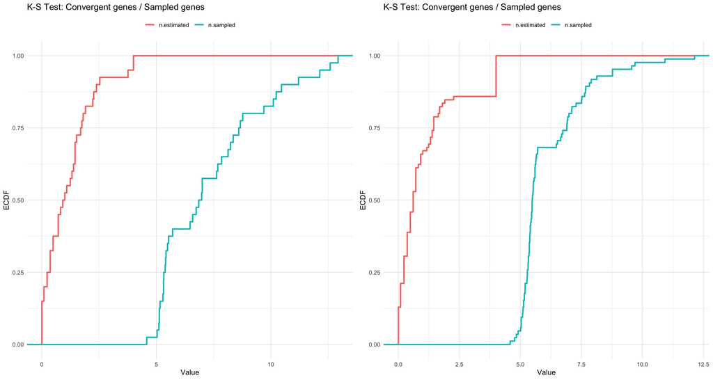

```r
#For plotting
ksplot<-function(dat){
  # create ECDF of data
  cdf1 <- ecdf(dat$n.sampled)
  cdf2 <- ecdf(dat$n.estimated)

  dat<-dat %>% reshape2::melt()

  ggplot(dat, aes(x = value, group = variable, color = variable))+
  stat_ecdf(size=1) +
  theme_minimal() +
  theme(legend.position ="top") +
  xlab("Value") +
  ylab("ECDF") +
  ggtitle("K-S Test: Convergent genes / Sampled genes") +
  theme(legend.title=element_blank()) %>% return()
}

p1<-ksplot(dat_order)
p2<-ksplot(dat_family)

ggpubr::ggarrange(p1,p2, ncol = 2)
```

### Distribution bar plots

These plot show the distribution of convergent and sampled genes in each Order.

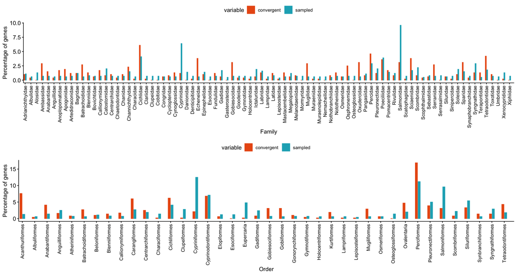

```r
#Distribution of convergent genes in each Family
dat<-test_dat_family %>%
  mutate(convergent = round((n.estimated/sum(n.estimated))*100,digits = 1)) %>%
  mutate(sampled = round((n.sampled/sum(n.sampled))*100,digits = 1)) %>%
  dplyr::select(Family,convergent,sampled) %>%
  reshape2::melt()


p1<-ggpubr::ggbarplot(dat, "Family", "value",
          fill = "variable", color = "variable",
          label = F,
          position = position_dodge(0.9),
          x.text.angle = 90,
          palette = c("#EA5B15", "#1AAEC0"),
          ylab = "Percentage of genes")+
  scale_x_discrete(limits=c(sort(dat[[1]],decreasing = F)))
p1<-ggpubr::ggpar(p1,font.xtickslab = 10)


#Distribution of convergent genes in each order
dat<-test_dat_order %>%
  mutate(convergent = round((n.estimated/sum(n.estimated))*100,digits = 1)) %>%
  mutate(sampled = round((n.sampled/sum(n.sampled))*100,digits = 1)) %>%
  dplyr::select(Order,convergent,sampled) %>%
  reshape2::melt()


p2<-ggpubr::ggbarplot(dat, "Order", "value",
          fill = "variable", color = "variable",
          label = F,
          position = position_dodge(0.9),
          x.text.angle = 90,
          palette = c("#EA5B15", "#1AAEC0"),
          ylab = "Percentage of genes")+
  scale_x_discrete(limits=c(sort(dat[[1]],decreasing = F)))
p2<-ggpubr::ggpar(p2,font.xtickslab = 10)

ggpubr::ggarrange(p1,p2,nrow = 2)
```

### Zoological characteristics of the convergent species

Here I look at some of the zoological characteristics of the convergent species. The data were collected from FishBase. Not all the species had data. I only present the data that was available.  
The table below shows number of species in our dataset from each Family.

```r
library(rfishbase)
fish_call<-validate_names(str_replace(fish_data$Species,"_"," "))
taxa<-rfishbase::load_taxa() %>% filter(Species %in% fish_call) %>% collect()
env_dat<-rfishbase::ecosystem(fish_call) %>% distinct(Species,.keep_all = T) %>% dplyr::select(Species,Salinity,EcosystemType,Climate)
env_dat<-env_dat %>% mutate(Species = str_replace_all(env_dat$Species," ","_"))

tax_info_conv<-left_join(tax_info_conv,env_dat,by = "Species")

#Fix the variable names; make them consistent
tax_info_conv$Climate[tax_info_conv$Climate=="Tropical"]<-"tropical"
tax_info_conv$Climate[tax_info_conv$Climate=="Subtropical"]<-"subtropical"
tax_info_conv$Climate[tax_info_conv$Climate=="Temperate"]<-"temperate"
tax_info_conv$Salinity[is.na(tax_info_conv$Salinity)]<-"saltwater"
tax_info_conv$Climate[is.na(tax_info_conv$Climate)]<-"tropical"
tax_info_conv$EcosystemType[is.na(tax_info_conv$EcosystemType)]<-"Sea/Bay/Gulf"

tax_info_conv %>% dplyr::count(Family) %>% arrange(desc(n))
```

| Family | n |
| --- | --- |
| Cichlidae | 32 |
| Percidae | 24 |
| Tetraodontidae | 22 |
| Echeneidae | 20 |
| Sciaenidae | 20 |
| Poeciliidae | 19 |
| Gobiesocidae | 16 |
| Oxudercidae | 16 |
| Salmonidae | 16 |
| Sparidae | 16 |

[output cut: 63 more lines]

```r
food_dat<-rfishbase::fooditems(fish_call) %>% distinct(Species,.keep_all = T) %>% dplyr::select(Species,FoodI,FoodII,FoodIII,Foodgroup)
food_dat<-food_dat %>% mutate(Species = str_replace_all(food_dat$Species," ","_"))
tax_info_conv<-left_join(tax_info_conv,food_dat,by = "Species")
```

### Climate

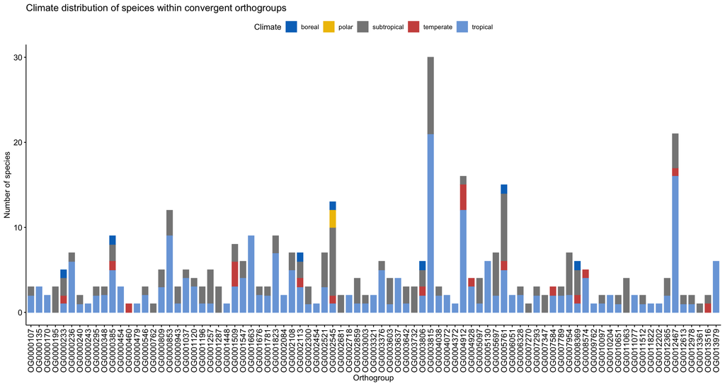

```r
p1<-tax_info_conv %>% na.omit() %>% summarise(n = n(),.by = c(Orthogroup,Climate)) %>%
  reshape2::melt() %>% ggpubr::ggbarplot(x = "Orthogroup",y = "value",fill = "Climate",color = "Climate",
                                         x.text.angle = 90,label = F,palette = "jco",ylab = "Number of species",title = "Climate distribution of speices within convergent orthogroups")

p1
```

### Food item

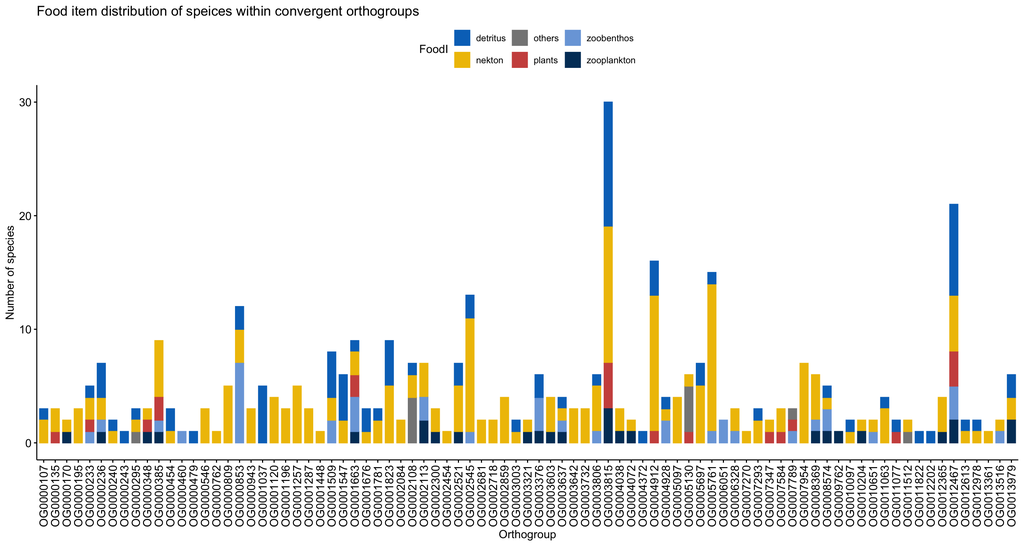

```r
p2<-tax_info_conv %>% na.omit() %>% summarise(n = n(),.by = c(Orthogroup,FoodI)) %>%
  reshape2::melt() %>% ggpubr::ggbarplot(x = "Orthogroup",y = "value",fill = "FoodI",color = "FoodI",
                                         x.text.angle = 90,label = F,palette = "jco",ylab = "Number of species",title = "Food item distribution of speices within convergent orthogroups")
p2
```

### Salinity

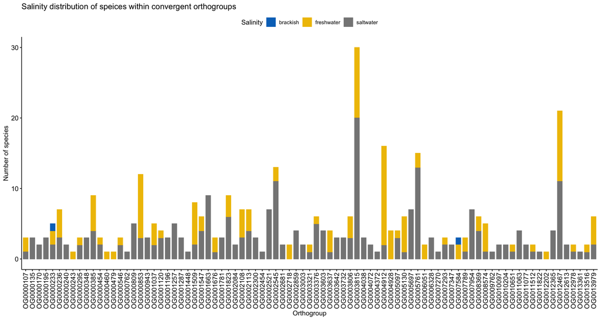

```r
p3<-tax_info_conv %>% na.omit() %>% summarise(n = n(),.by = c(Orthogroup,Salinity)) %>%
  reshape2::melt() %>% ggpubr::ggbarplot(x = "Orthogroup",y = "value",fill = "Salinity",color = "Salinity",
                                         x.text.angle = 90,label = F,palette = "jco",ylab = "Number of species",title = "Salinity distribution of speices within convergent orthogroups")
p3
```

### Ecosystem type

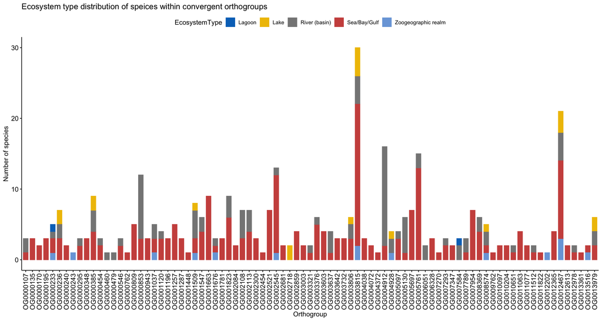

```r
p4<-tax_info_conv %>% na.omit() %>% summarise(n = n(),.by = c(Orthogroup,EcosystemType)) %>%
  reshape2::melt() %>% ggpubr::ggbarplot(x = "Orthogroup",y = "value",fill = "EcosystemType",color = "EcosystemType",
                                         x.text.angle = 90,label = F,palette = "jco",ylab = "Number of species",title = "Ecosystem type distribution of speices within convergent orthogroups")
p4
```

### Test of independence

Here I perform tests of independence to infer whether there is any relationship between convergence in one orthogroup and the ecological characters. After correcting for multiple testing, only 4 orthogroups show a significant relationship. However these relationships are with the undefined food variable ‘other’. As a result, we cannot make any biological relevant inference from this relationship.

```r
gene_chi_sq<-function(orth)
  {
t<-tax_info_conv %>% filter(Orthogroup == orth) %>% dplyr::select(Climate,Salinity,EcosystemType,FoodI,Orthogroup)
t<-rbind(t,
      tax_info_conv %>% filter(!Orthogroup %in% t$Orthogroup) %>%
        dplyr::select(Climate,Salinity,EcosystemType,FoodI) %>%
        mutate(Orthogroup = "other")) %>% replace_na(list(FoodI = "unknown"))

t1<-chisq.test(table(t$Orthogroup,t$Salinity),simulate.p.value = T,B = 2000)$p.value
t2<-chisq.test(table(t$Orthogroup,t$Climate),simulate.p.value = T,B = 2000)$p.value
t3<-chisq.test(table(t$Orthogroup,t$EcosystemType),simulate.p.value = T,B = 2000)$p.value
t4<-chisq.test(table(t$Orthogroup,t$FoodI),simulate.p.value = T,B = 2000)$p.value

pval_list<-list(t1,t2,t3,t4)
names(pval_list)<-c("salinity","climate","ecosystem","food")
return(pval_list)
}

chi_res<-purrr::map(tax_info_conv %>% distinct(Orthogroup) %>% pull(),gene_chi_sq)
names(chi_res)<-tax_info_conv %>% distinct(Orthogroup) %>% pull()

purrr::list_flatten(chi_res) %>% p.adjust(method = "BH")
```

```
##  OG0000107_salinity   OG0000107_climate OG0000107_ecosystem      OG0000107_food
##          0.87392287          1.00000000          0.78648951          0.96571577
##  OG0000135_salinity   OG0000135_climate OG0000135_ecosystem      OG0000135_food
##          0.76638604          0.82676309          0.92426957          0.76638604
##  OG0000170_salinity   OG0000170_climate OG0000170_ecosystem      OG0000170_food
##          1.00000000          0.82676309          1.00000000          0.83342286
##  OG0000195_salinity   OG0000195_climate OG0000195_ecosystem      OG0000195_food
##          0.73734244          0.76638604          0.82676309          1.00000000
##  OG0000233_salinity   OG0000233_climate OG0000233_ecosystem      OG0000233_food
##          0.34535673          0.48035982          0.34535673          0.83342286
##  OG0000236_salinity   OG0000236_climate OG0000236_ecosystem      OG0000236_food
##          0.84425380          0.83467719          0.48035982          0.91920706
##  OG0000240_salinity   OG0000240_climate OG0000240_ecosystem      OG0000240_food
##          0.91920706          1.00000000          1.00000000          1.00000000
##  OG0000243_salinity   OG0000243_climate OG0000243_ecosystem      OG0000243_food
##          0.87392287          1.00000000          0.84425380          0.83467719
##  OG0000295_salinity   OG0000295_climate OG0000295_ecosystem      OG0000295_food
##          1.00000000          1.00000000          1.00000000          0.57609291
##  OG0000348_salinity   OG0000348_climate OG0000348_ecosystem      OG0000348_food
##          0.77094786          1.00000000          0.92426957          0.48241264
##  OG0000385_salinity   OG0000385_climate OG0000385_ecosystem      OG0000385_food
##          0.82676309          0.76638604          0.76638604          0.76638604
##  OG0000454_salinity   OG0000454_climate OG0000454_ecosystem      OG0000454_food
##          1.00000000          0.82676309          1.00000000          0.82676309
##  OG0000460_salinity   OG0000460_climate OG0000460_ecosystem      OG0000460_food
##          1.00000000          0.48035982          1.00000000          0.76638604
##  OG0000479_salinity   OG0000479_climate OG0000479_ecosystem      OG0000479_food
##          0.48035982          0.76638604          0.48035982          0.76638604
##  OG0000546_salinity   OG0000546_climate OG0000546_ecosystem      OG0000546_food
##          1.00000000          1.00000000          1.00000000          0.87392287
##  OG0000762_salinity   OG0000762_climate OG0000762_ecosystem      OG0000762_food
##          1.00000000          0.92426957          1.00000000          0.92426957
##  OG0000809_salinity   OG0000809_climate OG0000809_ecosystem      OG0000809_food
##          0.72223412          1.00000000          0.82676309          0.76638604
##  OG0000853_salinity   OG0000853_climate OG0000853_ecosystem      OG0000853_food
##          0.48035982          0.83467719          0.48035982          0.04447776
##  OG0000943_salinity   OG0000943_climate OG0000943_ecosystem      OG0000943_food
##          0.76638604          0.92426957          0.92426957          0.88882308
##  OG0001037_salinity   OG0001037_climate OG0001037_ecosystem      OG0001037_food
##          0.82676309          0.83702910          0.87392287          0.16422558
```

[output cut: 123 more lines]

```
##          0.48035982          0.83233237          0.76638604          0.83467719
##  OG0012365_salinity   OG0012365_climate OG0012365_ecosystem      OG0012365_food
##          0.83342286          0.70670220          0.87392287          0.91920706
##  OG0012467_salinity   OG0012467_climate OG0012467_ecosystem      OG0012467_food
##          0.70670220          0.79515344          0.16173731          0.48241264
##  OG0012613_salinity   OG0012613_climate OG0012613_ecosystem      OG0012613_food
##          0.76638604          0.92426957          0.92426957          1.00000000
##  OG0012978_salinity   OG0012978_climate OG0012978_ecosystem      OG0012978_food
##          0.87392287          1.00000000          0.79515344          1.00000000
##  OG0013361_salinity   OG0013361_climate OG0013361_ecosystem      OG0013361_food
##          1.00000000          0.72088631          0.83467719          0.92426957
##  OG0013516_salinity   OG0013516_climate OG0013516_ecosystem      OG0013516_food
##          0.87392287          0.83702910          0.86030957          0.91920706
##  OG0013979_salinity   OG0013979_climate OG0013979_ecosystem      OG0013979_food
##          0.71895559          0.76638604          0.48035982          0.70670220
```

### Species vs Order

For each order, look at the species that has the highest number of convergent genes

```r
tax_info_conv %>% filter(Order == "Perciformes") %>% summarise(n = n(),.by = Species) %>% arrange(desc(n)) %>% kbl() %>%  kable_styling() %>%
  scroll_box(width = "350px", height = "400px")
```

| Species | n |
| --- | --- |
| Centropristis_striata | 14 |
| Anoplopoma_fimbria | 9 |
| Dissostichus_eleginoides | 7 |
| Chaenocephalus_aceratus | 7 |
| Pogonophryne_albipinna | 6 |
| Perca_fluviatilis | 5 |
| Perca_flavescens | 5 |
| Etheostoma_spectabile | 5 |
| Pseudochaenichthys_georgianus | 5 |
| Etheostoma_cragini | 5 |
| Cyclopterus_lumpus | 4 |
| Sander_lucioperca | 4 |
| Cottoperca_gobio | 3 |
| Plectropomus_leopardus | 3 |
| Sebastes_umbrosus | 3 |
| Epinephelus_lanceolatus | 2 |

```r
tax_info_conv %>% filter(Order == "Cypriniformes") %>% summarise(n = n(),.by = Species) %>% arrange(desc(n)) %>% kbl() %>%  kable_styling() %>%
  scroll_box(width = "350px", height = "400px")
```

| Species | n |
| --- | --- |
| Puntigrus_tetrazona | 3 |
| Onychostoma_macrolepis | 2 |
| Xyrauchen_texanus | 2 |
| Myxocyprinus_asiaticus | 2 |
| Ctenopharyngodon_idella | 1 |
| Cyprinus_carpio | 1 |

```r
tax_info_conv %>% filter(Order == "Cyprinodontiformes") %>% summarise(n = n(),.by = Species) %>% arrange(desc(n)) %>% kbl() %>%  kable_styling() %>%
  scroll_box(width = "350px", height = "400px")
```

| Species | n |
| --- | --- |
| Fundulus_heteroclitus | 6 |
| Xiphophorus_maculatus | 4 |
| Xiphophorus_hellerii | 4 |
| Gambusia_affinis | 4 |
| Poecilia_reticulata | 4 |
| Nothobranchius_furzeri | 4 |
| Kryptolebias_marmoratus | 3 |
| Xiphophorus_couchianus | 3 |
| Girardinichthys_multiradiatus | 2 |
| Nematolebias_whitei | 1 |

```r
tax_info_conv %>% filter(Order == "Salmoniformes") %>% summarise(n = n(),.by = Species) %>% arrange(desc(n)) %>% kbl() %>%  kable_styling() %>%
  scroll_box(width = "350px", height = "400px")
```

| Species | n |
| --- | --- |
| Salvelinus_namaycush | 2 |
| Salvelinus_fontinalis | 2 |
| Salmo_salar | 2 |
| Oncorhynchus_keta | 2 |
| Oncorhynchus_mykiss | 2 |
| Coregonus_clupeaformis | 2 |
| Oncorhynchus_gorbuscha | 1 |
| Oncorhynchus_nerka | 1 |
| Oncorhynchus_tshawytscha | 1 |
| Oncorhynchus_kisutch | 1 |

```r
tax_info_conv %>% filter(Order == "Eupercaria") %>% summarise(n = n(),.by = Species) %>% arrange(desc(n)) %>% kbl() %>%  kable_styling() %>%
  scroll_box(width = "350px", height = "400px")
```

| Species | n |
| --- | --- |

## Tissue-specific convergent orthologs

### Load the data

```r
#Ortholog list
orth_list<-readRDS("./RDS/large_fish_tree_all_orders.rds")
orth_list<-orth_list %>% mutate(orths =  str_remove(orth_list$orths,"..$"))
combined_arity <-readRDS("./RDS/combined_arity.rds")
non_spuroius_conv<-read_csv("Datasets/DatasetS0_csv_files/Non_spurious_conv.csv")


### tissue specific genes. (check Bgee processing rmd to know how to get these)
skin<-orth_list %>% filter(orths %in% (readRDS("./RDS/Tau_0.8_TMM_cpm_with_log_no_combat_skin.rds")
                           %>% purrr::list_rbind() %>% dplyr::select(Gene.ID))$Gene.ID)
brain<-orth_list %>% filter(orths %in% (readRDS("./RDS/Tau_0.8_TMM_cpm_with_log_no_combat_brain.rds")
                           %>% purrr::list_rbind() %>% dplyr::select(Gene.ID))$Gene.ID)
eye<-orth_list %>% filter(orths %in% (readRDS("./RDS/Tau_0.8_TMM_cpm_with_log_no_combat_eye.rds")
                           %>% purrr::list_rbind() %>% dplyr::select(Gene.ID))$Gene.ID)
heart<-orth_list %>% filter(orths %in% (readRDS("./RDS/Tau_0.8_TMM_cpm_with_log_no_combat_heart.rds")
                           %>% purrr::list_rbind() %>% dplyr::select(Gene.ID))$Gene.ID)
liver<-orth_list %>% filter(orths %in% (readRDS("./RDS/Tau_0.8_TMM_cpm_with_log_no_combat_liver.rds")
                           %>% purrr::list_rbind() %>% dplyr::select(Gene.ID))$Gene.ID)
muscle<-orth_list %>% filter(orths %in% (readRDS("./RDS/Tau_0.8_TMM_cpm_with_log_no_combat_muscle.rds")
                           %>% purrr::list_rbind() %>% dplyr::select(Gene.ID))$Gene.ID)
ovary<-orth_list %>% filter(orths %in% (readRDS("./RDS/Tau_0.8_TMM_cpm_with_log_no_combat_ovary.rds")
                           %>% purrr::list_rbind() %>% dplyr::select(Gene.ID))$Gene.ID)
testis<-orth_list %>% filter(orths %in% (readRDS("./RDS/Tau_0.8_TMM_cpm_with_log_no_combat_testis.rds")
                           %>% purrr::list_rbind() %>% dplyr::select(Gene.ID))$Gene.ID)

#Get the orthologs that are exclusively tissue specific for each tissue
#brain
ts_list<-list(brain,eye,heart,liver,muscle,skin,ovary,testis) #change the first entry in the list when computing exclusive orthologs
brain_excl<-purrr::reduce(ts_list,anti_join, by = "Orthogroup")# %>% write_csv("./Datasets/DatasetS0_csv_files/Brain_exclusive_orths.csv")
#eye
ts_list<-list(eye,brain,heart,liver,muscle,skin,ovary,testis) #change the first entry in the list when computing exclusive orthologs
eye_excl<-purrr::reduce(ts_list,anti_join, by = "Orthogroup")# %>% write_csv("./Datasets/DatasetS0_csv_files/Eye_exclusive_orths.csv")
#heart
ts_list<-list(heart,brain,eye,liver,muscle,skin,ovary,testis) #change the first entry in the list when computing exclusive orthologs
heart_excl<-purrr::reduce(ts_list,anti_join, by = "Orthogroup")# %>% write_csv("./Datasets/DatasetS0_csv_files/Heart_exclusive_orths.csv")
#liver
ts_list<-list(liver,eye,brain,heart,muscle,skin,ovary,testis) #change the first entry in the list when computing exclusive orthologs
liver_excl<-purrr::reduce(ts_list,anti_join, by = "Orthogroup")# %>% write_csv("./Datasets/DatasetS0_csv_files/Liver_exclusive_orths.csv")
#muscle
ts_list<-list(muscle,eye,brain,heart,liver,skin,ovary,testis) #change the first entry in the list when computing exclusive orthologs
muscle_excl<-purrr::reduce(ts_list,anti_join, by = "Orthogroup")# %>% write_csv("./Datasets/DatasetS0_csv_files/Muscle_exclusive_orths.csv")
#skin
ts_list<-list(skin,eye,brain,heart,liver,muscle,ovary,testis) #change the first entry in the list when computing exclusive orthologs
skin_excl<-purrr::reduce(ts_list,anti_join, by = "Orthogroup")# %>% write_csv("./Datasets/DatasetS0_csv_files/Skin_exclusive_orths.csv")
#ovary
ts_list<-list(ovary,eye,brain,heart,liver,muscle,skin,testis) #change the first entry in the list when computing exclusive orthologs
ovary_excl<-purrr::reduce(ts_list,anti_join, by = "Orthogroup")# %>% write_csv("./Datasets/DatasetS0_csv_files/Overy_exclusive_orths.csv")
#testis
ts_list<-list(testis,eye,brain,heart,liver,muscle,skin,ovary) #change the first entry in the list when computing exclusive orthologs
testis_excl<-purrr::reduce(ts_list,anti_join, by = "Orthogroup")# %>% write_csv("./Datasets/DatasetS0_csv_files/Testis_exclusive_orths.csv")

# Check the relative proportion of tissue specific orthogroups vs all orthogroups in the species
bind_rows(tibble(group = "Brain specific", ts.prop = (length((brain_excl %>% distinct(Orthogroup))$Orthogroup)/length((orth_list %>% filter(sp %in% brain_excl$sp) %>% distinct(Orthogroup))$Orthogroup))*100),
tibble(group = "Eye specific", ts.prop = (length((eye_excl %>% distinct(Orthogroup))$Orthogroup)/length((orth_list %>% filter(sp %in% eye_excl$sp) %>% distinct(Orthogroup))$Orthogroup))*100),
tibble(group = "Heart specific", ts.prop = (length((heart_excl %>% distinct(Orthogroup))$Orthogroup)/length((orth_list %>% filter(sp %in% heart_excl$sp) %>% distinct(Orthogroup))$Orthogroup))*100),
tibble(group = "Liver specific", ts.prop = (length((liver_excl %>% distinct(Orthogroup))$Orthogroup)/length((orth_list %>% filter(sp %in% liver_excl$sp) %>% distinct(Orthogroup))$Orthogroup))*100),
tibble(group = "Muscle specific", ts.prop = (length((muscle_excl %>% distinct(Orthogroup))$Orthogroup)/length((orth_list %>% filter(sp %in% muscle_excl$sp) %>% distinct(Orthogroup))$Orthogroup))*100),
tibble(group = "Skin specific", ts.prop = (length((skin_excl %>% distinct(Orthogroup))$Orthogroup)/length((orth_list %>% filter(sp %in% skin_excl$sp) %>% distinct(Orthogroup))$Orthogroup))*100),
tibble(group = "Ovary specific", ts.prop = (length((ovary_excl %>% distinct(Orthogroup))$Orthogroup)/length((orth_list %>% filter(sp %in% ovary_excl$sp) %>% distinct(Orthogroup))$Orthogroup))*100),
tibble(group = "Testis specific", ts.prop = (length((testis_excl %>% distinct(Orthogroup))$Orthogroup)/length((orth_list %>% filter(sp %in% testis_excl$sp) %>% distinct(Orthogroup))$Orthogroup))*100))->ts_prop_dat
```

### Convergent genes that are also tissue specific

```r
#convergent genes that are also tissue specific
d<-combined_arity %>% filter(Orthogroup %in% non_spuroius_conv$Orthogroup) %>% distinct(Orthogroup)

d<-d %>% mutate(c = "TRUE") %>%
  mutate(brain_c = if_else(d$Orthogroup %in% brain_excl$Orthogroup, TRUE, FALSE)) %>%
  mutate(eye_c = if_else(d$Orthogroup %in% eye_excl$Orthogroup, TRUE, FALSE)) %>%
  mutate(heart_c = if_else(d$Orthogroup %in% heart_excl$Orthogroup, TRUE, FALSE)) %>%
  mutate(liver_c = if_else(d$Orthogroup %in% liver_excl$Orthogroup, TRUE, FALSE)) %>%
  mutate(muscle_c = if_else(d$Orthogroup %in% muscle_excl$Orthogroup, TRUE, FALSE)) %>%
  mutate(skin_c = if_else(d$Orthogroup %in% skin_excl$Orthogroup, TRUE, FALSE)) %>%
  mutate(ovary_c = if_else(d$Orthogroup %in% ovary_excl$Orthogroup, TRUE, FALSE)) %>%
  mutate(testis_c = if_else(d$Orthogroup %in% testis_excl$Orthogroup, TRUE, FALSE))


print(paste("Number of brain-specific convergent genes:",matrixStats::count(d$brain_c)))
```

```
## [1] "Number of brain-specific convergent genes: 5"
```

```r
print(paste("Number of eye-specific convergent genes:",matrixStats::count(d$eye_c)))
```

```
## [1] "Number of eye-specific convergent genes: 1"
```

```r
print(paste("Number of heart-specific convergent genes:",matrixStats::count(d$heart_c)))
```

```
## [1] "Number of heart-specific convergent genes: 1"
```

```r
print(paste("Number of liver-specific convergent genes:",matrixStats::count(d$liver_c)))
```

```
## [1] "Number of liver-specific convergent genes: 13"
```

```r
print(paste("Number of muscle-specific convergent genes:",matrixStats::count(d$muscle_c)))
```

```
## [1] "Number of muscle-specific convergent genes: 1"
```

```r
print(paste("Number of skin-specific convergent genes:",matrixStats::count(d$skin_c)))
```

```
## [1] "Number of skin-specific convergent genes: 2"
```

```r
print(paste("Number of ovary-specific convergent genes:",matrixStats::count(d$ovary_c)))
```

```
## [1] "Number of ovary-specific convergent genes: 2"
```

```r
print(paste("Number of testis-specific convergent genes:",matrixStats::count(d$testis_c)))
```

```
## [1] "Number of testis-specific convergent genes: 4"
```

```r
library(ggpubr)
library(rstatix)
library(coin)
```

### Fisher’s exact test

```r
#Fishers exact test
cont_dat<-tibble(orth_list %>% distinct(Orthogroup))
cont_dat %>% mutate(is_convergent = if_else(cont_dat$Orthogroup %in% d$Orthogroup,TRUE,FALSE)) %>%
  mutate(brain_spec = if_else(cont_dat$Orthogroup %in% (brain_excl %>% distinct(Orthogroup))$Orthogroup, TRUE, FALSE)) %>%
  mutate(eye_spec = if_else(cont_dat$Orthogroup %in% (eye_excl %>% distinct(Orthogroup))$Orthogroup, TRUE, FALSE)) %>%
  mutate(heart_spec = if_else(cont_dat$Orthogroup %in% (heart_excl %>% distinct(Orthogroup))$Orthogroup, TRUE, FALSE)) %>%
  mutate(liver_spec = if_else(cont_dat$Orthogroup %in% (liver_excl %>% distinct(Orthogroup))$Orthogroup, TRUE, FALSE)) %>%
  mutate(muscle_spec = if_else(cont_dat$Orthogroup %in% (muscle_excl %>% distinct(Orthogroup))$Orthogroup, TRUE, FALSE)) %>%
  mutate(skin_spec = if_else(cont_dat$Orthogroup %in% (skin_excl %>% distinct(Orthogroup))$Orthogroup, TRUE, FALSE)) %>%
  mutate(ovary_spec = if_else(cont_dat$Orthogroup %in% (ovary_excl %>% distinct(Orthogroup))$Orthogroup, TRUE, FALSE)) %>%
  mutate(testis_spec = if_else(cont_dat$Orthogroup %in% (testis_excl %>% distinct(Orthogroup))$Orthogroup, TRUE, FALSE))->cont_dat

ft<-function(x){
  res<-fisher.test(cont_dat$is_convergent,x,alternative = "greater")
  if (res$p.value < 0.05) {
    return(cat(paste(
      "p-value:",
      round(res$p.value, 3),
      "Therefore, there IS a significant difference between convergent/non-convergent ratio between tissue-specific and non tissue-specific genes.",
      sep="\n")))
  } else {
    return(cat(paste(
      "p-value:",
      round(res$p.value, 3),
      "Therefore, there is NOT a significant difference between convergent/non-convergent ratio between tissue-specific and non tissue-specific genes.",
      sep="\n")))
  }
}

purrr::map(list(cont_dat$brain_spec,cont_dat$eye_spec,cont_dat$heart_spec,
                cont_dat$liver_spec,cont_dat$muscle_spec,cont_dat$skin_spec,cont_dat$ovary_spec,
                cont_dat$testis_spec),ft) %>% purrr::flatten()
```

```
## p-value:
## 0.949
## Therefore, there is NOT a significant difference between convergent/non-convergent ratio between tissue-specific and non tissue-specific genes.p-value:
## 0.581
## Therefore, there is NOT a significant difference between convergent/non-convergent ratio between tissue-specific and non tissue-specific genes.p-value:
## 0.326
## Therefore, there is NOT a significant difference between convergent/non-convergent ratio between tissue-specific and non tissue-specific genes.p-value:
## 0
## Therefore, there IS a significant difference between convergent/non-convergent ratio between tissue-specific and non tissue-specific genes.p-value:
## 0.759
## Therefore, there is NOT a significant difference between convergent/non-convergent ratio between tissue-specific and non tissue-specific genes.p-value:
## 0.319
## Therefore, there is NOT a significant difference between convergent/non-convergent ratio between tissue-specific and non tissue-specific genes.p-value:
## 0.192
## Therefore, there is NOT a significant difference between convergent/non-convergent ratio between tissue-specific and non tissue-specific genes.p-value:
## 0.271
## Therefore, there is NOT a significant difference between convergent/non-convergent ratio between tissue-specific and non tissue-specific genes.
```

```
## list()
```

```r
cont_plot_dat<-bind_rows(tibble(group = "Brain specific", genes = (cont_dat %>% filter(is_convergent == T) %>% pull(brain_spec) %>% matrixStats::count())/matrixStats::count(cont_dat$is_convergent)*100),
                                tibble(group = "Eye specific", genes = (cont_dat %>% filter(is_convergent == T) %>% pull(eye_spec) %>% matrixStats::count())/matrixStats::count(cont_dat$is_convergent)*100),
tibble(group = "Heart specific", genes = (cont_dat %>% filter(is_convergent == T) %>% pull(heart_spec) %>% matrixStats::count())/matrixStats::count(cont_dat$is_convergent)*100),
tibble(group = "Liver specific", genes = (cont_dat %>% filter(is_convergent == T) %>% pull(liver_spec) %>% matrixStats::count())/matrixStats::count(cont_dat$is_convergent)*100),
tibble(group = "Muscle specific", genes = (cont_dat %>% filter(is_convergent == T) %>% pull(muscle_spec) %>% matrixStats::count())/matrixStats::count(cont_dat$is_convergent)*100),
tibble(group = "Skin specific", genes = (cont_dat %>% filter(is_convergent == T) %>% pull(skin_spec) %>% matrixStats::count())/matrixStats::count(cont_dat$is_convergent)*100),
tibble(group = "Ovary specific", genes = (cont_dat %>% filter(is_convergent == T) %>% pull(ovary_spec) %>% matrixStats::count())/matrixStats::count(cont_dat$is_convergent)*100),
tibble(group = "Testis specific", genes = (cont_dat %>% filter(is_convergent == T) %>% pull(testis_spec) %>% matrixStats::count())/matrixStats::count(cont_dat$is_convergent)*100))
```

### Difference in proportions of tissue specific and convergent genes

```r
wil.test.dat<-left_join(cont_plot_dat,ts_prop_dat)

wilcox.test(x=wil.test.dat$genes,
            y=wil.test.dat$ts.prop,
            paired = T,exact = T,
            alternative = "two.sided")
```

```
##
##  Wilcoxon signed rank exact test
##
## data:  wil.test.dat$genes and wil.test.dat$ts.prop
## V = 27, p-value = 0.25
## alternative hypothesis: true location shift is not equal to 0
```

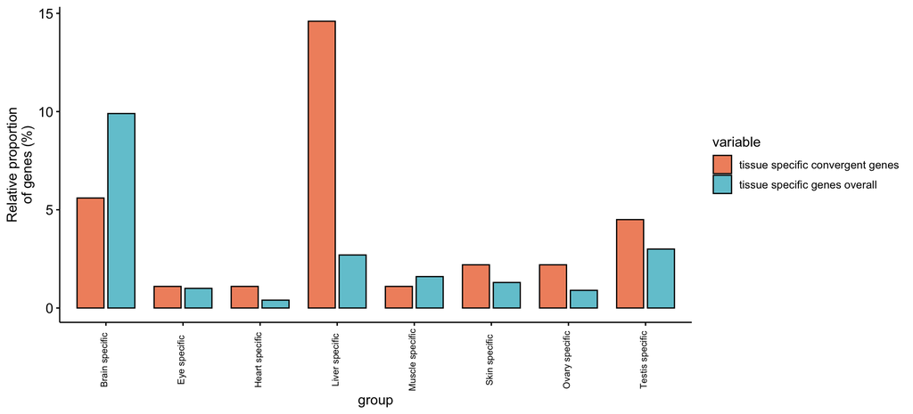

```r
plot_dat<-wil.test.dat %>% dplyr::rename(`tissue specific convergent genes` = genes) %>% dplyr::rename(`tissue specific genes overall` = ts.prop) %>% reshape2::melt()  %>% mutate(value = round(value,digits = 1))

ggpubr::ggbarplot(plot_dat, x = "group",y = "value",fill = "variable",alpha=0.7,
                  color = "black",palette = c("#EA5B15","#1AAEC0"),
                  position = position_dodge(0.8),ylab = "Relative proportion\nof genes (%)")+
    theme(axis.text.x = element_text(angle = 90,size = 8, vjust = 0.2),
          legend.position = "right")
```

## Relationships between copy number and convergence

The convergnece estimates could be biased by the higher power of the OCN convergence metric for longer genes or orthogroups containing more genes simply because the sequence space is larger. I used a Pearson correlation test to check whether the length or the number of genes in each orthogroup introduced any bias. I found no significant relationship between gene number or gene length and the OCN metric, suggesting that the OCN value strictly depends on sequence variation, and that such bias is not a concern in our data.

### OCN ~ number of genes

There was no significant relationship between OCN and number of genes in Orthogroup

```r
#Relationship between OCN and number of genes in Orthogroup
seq_stat<-read_tsv("./Datasets/DatasetS0_csv_files/seq_stats.tsv") #use the seqkit toolkit (https://bioinf.shenwei.me/seqkit/) to obtain this
combined_arity<-combined_arity %>% filter(Orthogroup %in% non_spuroius_conv$Orthogroup)
cor_dat<-left_join(combined_arity %>% summarise(mean_OCN = log10(mean(OCNany2spe)),.by = "Orthogroup") %>% drop_na(),seq_stat,by = "Orthogroup")
```

```r
cor.test(log10(cor_dat$mean_OCN), cor_dat$num_seqs, method = "pearson")
```

```
##
##  Pearson's product-moment correlation
##
## data:  log10(cor_dat$mean_OCN) and cor_dat$num_seqs
## t = 1.6687, df = 87, p-value = 0.09877
## alternative hypothesis: true correlation is not equal to 0
## 95 percent confidence interval:
##  -0.03337226  0.37076699
## sample estimates:
##       cor
## 0.1761084
```

```r
ocn_gene_cor_plot<-ggpubr::ggscatter(cor_dat,x = "mean_OCN", y = "num_seqs", add = "reg.line", cor.coef = T, cor.method = "pearson",color = "grey70",add.params = list(color = "red3"))+
  xlab("Mean log10(OCN) value")+
  ylab("Average number of genes in orthgroup")+
  font("xlab", size = 10)+
  font("ylab", size = 10)
```

### OCN ~ length of genes

There was no significant relationship between OCN and the length of genes in Orthogroup

```r
cor.test(log(cor_dat$mean_OCN), cor_dat$avg_len, method = "pearson")
```

```
##
##  Pearson's product-moment correlation
##
## data:  log(cor_dat$mean_OCN) and cor_dat$avg_len
## t = -0.6184, df = 87, p-value = 0.5379
## alternative hypothesis: true correlation is not equal to 0
## 95 percent confidence interval:
##  -0.2706822  0.1440872
## sample estimates:
##         cor
## -0.06615467
```

```r
ocn_len_cor_plot<-ggpubr::ggscatter(cor_dat,x = "mean_OCN", y = "avg_len", add = "reg.line", cor.coef = T, cor.method = "pearson",color = "grey70",add.params = list(color = "red3"))+
  xlab("Mean log10(OCN) value")+
  ylab("Average length of genes (bp) in orthgroup")+
  font("xlab", size = 10)+
  font("ylab", size = 10)
```

### Correlation plots

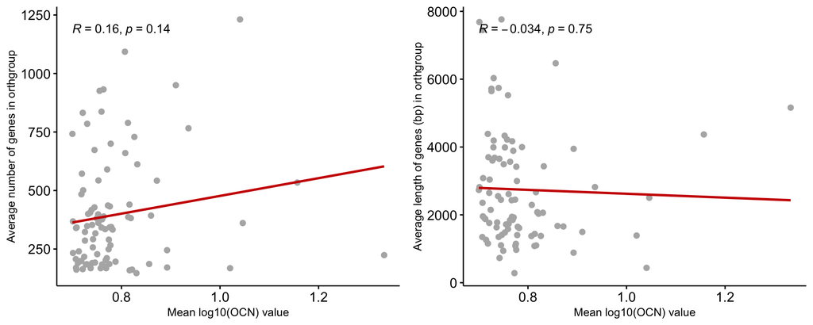

```r
gridExtra::grid.arrange(ocn_gene_cor_plot,ocn_len_cor_plot,ncol=2)
```

### Distribution of gene copies in convergent orthogroups

In this section I want to check whether the distribution of gene copy numbers in the set of convergent orthogroups is generally higher than the other orthogroups in our data set. To do this I make a data frame with the copy number distribution of convergent orthogroups and 89 randomly selected non-convergent orthogroups and perform the KS test. I repeat this test 1000 times with different sets of randomly selected orthogroups. Following this I adjust all the *p-values* for multiple correction and plot the *p-value* distribution. As we can observe an overwhelming number of the *p-values* are closer to zero.

```r
conv_seq<-seq_stat %>% filter(Orthogroup %in% non_spuroius_conv$Orthogroup)
bg_seq<-seq_stat %>% filter(!Orthogroup %in% non_spuroius_conv$Orthogroup) %>% filter(num_seqs < 1500)

boot_ks<-function(){
  ks_data_frame <- function() {
    tibble(n.estimated = conv_seq$num_seqs,
           n.sampled = bg_seq[runif(89,min = 1,max = 9184) %>% round(),]$num_seqs)
    }

  map(1:1000, function(x) ks_data_frame())->ls

  run_ks<-function(d){
    kldtools::ksboot(x = d$n.sampled,
                     y = d$n.estimated,
                     alternative = "greater",nboots = 1000)$ksboot.pvalue
    }
  map(ls,run_ks) %>% return()
}

ks_test_pvalues<-tibble(adj.p.values = p.adjust(p = boot_ks(),method = "BH"))
ks_test_pvalues %>% saveRDS("./RDS/num_seq_KS_pvals.rds")
```

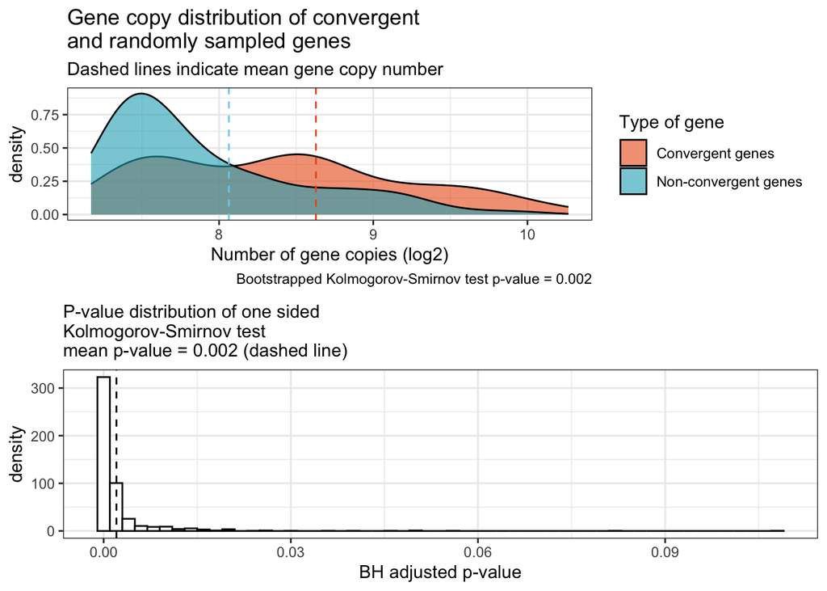

```r
conv_seq<-seq_stat %>% filter(Orthogroup %in% non_spuroius_conv$Orthogroup)
bg_seq<-seq_stat %>% filter(!Orthogroup %in% non_spuroius_conv$Orthogroup) %>% filter(num_seqs < 1500)

plot_dat<-tibble(n.estimated = conv_seq$num_seqs,
           n.sampled = bg_seq[runif(89,min = 1,max = 9184) %>% round(),]$num_seqs)

est_mean<-mean(plot_dat$n.estimated)

p1<-plot_dat %>% dplyr::rename("Convergent genes"="n.estimated",
                           "Non-convergent genes"="n.sampled") %>%
  pivot_longer(c(`Convergent genes`,`Non-convergent genes`),
               names_to = "Type of gene") %>%
  ggplot(aes(x=log2(value),fill = `Type of gene`))+
  geom_density(alpha=0.6)+
  geom_vline(xintercept = log2(mean(plot_dat$n.estimated)), color="#EA5B15", linetype="dashed")+
  geom_vline(xintercept = log2(mean(plot_dat$n.sampled)), color="#74D1F5", linetype="dashed")+
  scale_fill_manual(values = c("#EA5B15","#1AAEC0"))+
  xlab("Number of gene copies (log2)")+
  labs(title = "Gene copy distribution of convergent\nand randomly sampled genes",
       subtitle = "Dashed lines indicate mean gene copy number",
       caption = "Bootstrapped Kolmogorov-Smirnov test p-value = 0.002")+
  theme_bw()

ks_test_pvalues<-readRDS("./RDS/num_seq_KS_pvals.rds")


p2<-ks_test_pvalues %>% ggplot(aes(x = adj.p.values, y=..density..))+
    geom_histogram(binwidth = .002,color="black",fill="white")+
    geom_vline(xintercept = mean(ks_test_pvalues$adj.p.values), linetype="dashed")+
    xlab("BH adjusted p-value")+
    labs(subtitle = "P-value distribution of one sided\nKolmogorov-Smirnov test\nmean p-value = 0.002 (dashed line)")+theme_bw()

ggarrange(p1,p2, ncol = 1)
```

## Gene Ontology Term enrichment

In this section, I perform a Gene Ontology (GO) enrichment to identify the major biological processes represented in the list of convergent genes. The gene universe was obtained by annotating the genes of the fish species in Bgee using DeepGO.

### GO enrichment analysis

```r
library(GOstats)
library(GO.db)
library(GSEABase)
library(AnnotationDbi)
library(RSQLite)
library(tidyverse)


annot<-readRDS("./RDS/annot_processed.rds")
goFrame<-GOFrame(as.data.frame(annot, organism = "fish"))
goAllFrame<-GOAllFrame(goFrame)
gsc<-GeneSetCollection(goAllFrame,setType = GOCollection())
universe<-annot$gene

GO_enrich<-function(.data){

  up<-GSEAGOHyperGParams(name = "GO enrich",
                             geneSetCollection = gsc,
                             geneIds = .data,
                             universeGeneIds = universe,
                             ontology = "CC", #options: BP, MF, CC
                             pvalueCutoff = 0.05,
                             conditional = F,
                             testDirection = "over")
  Over_up<- hyperGTest(up)


  Over_up.pv<-pvalues(Over_up)
  pv.fdr<-p.adjust(Over_up.pv,"fdr")
  summary(Over_up) %>% as_tibble() %>% mutate(FDR = pv.fdr[1:nrow(summary(Over_up) %>% as_tibble())]) %>% dplyr::select(GOCCID,FDR,Term,Size) %>% filter(FDR<0.05) %>% return()
  }

#Ortholog list
orth_list<-readRDS("./RDS/large_fish_tree_all_orders.rds")
orth_list<-orth_list %>% mutate(orths =  str_remove(orth_list$orths,"..$"))
non_spuroius_conv<-read_csv("Datasets/DatasetS0_csv_files/Non_spurious_conv.csv")
GO_enrich(orth_list %>% filter(Orthogroup %in% non_spuroius_conv$Orthogroup) %>% pull(orths)) %>% saveRDS("./RDS/tru_conv_GO_CC.rds")

## GO plot
library(ggforce)

go_plot<-function(.data,name){
  GOenrich<-.data %>% arrange(desc(FDR)) %>% head(118)
  ggplot(GOenrich,aes(x = 1-log10(FDR),
                           y = as.factor(Term),
                           size = log10(Size)))+
    geom_point(color = "darkgreen")+
    ylab("Biological Process")+
    theme_light()->go_plot
  ggplot2::ggsave(paste("./Figures/",name,"_GO_enrich.png"),go_plot,width = 5,height = 10, units = "in",scale = 1.5,limitsize
                  = F,device = "png")
  }

go_plot(readRDS("./RDS/tru_conv_GO_BP.rds"),name = "Non_spurious_convergence")
```

### GO term enrichment plot

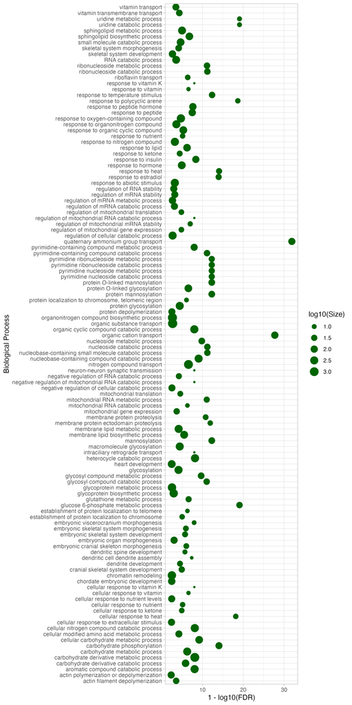

```r
knitr::include_graphics("./Figures/Non_spurious_convergence_GO_enrich.png")
```

### GO terms and ecological characters

In this section I check whether is any relationship between convergent genes with specific GO terns and ecological characters obtained from FishBase. This will provide information regarding potential biological functions and ecological relevance of the convergent genes.

Neither chisq test, nor the Fisher’s exact test showed evidence for any significant relationships between GO terms and ecological characters. This is likely due to low statistical power.  
Users can run the test to confirm. For the sake of brvity I have not inlcuded this output.

```r
d<-readRDS("./RDS/tru_conv_GO_CC.rds")
orth_list<-readRDS("./RDS/large_fish_tree_all_orders.rds")
orth_list<-orth_list %>% mutate(orths =  str_remove(orth_list$orths,"..$"))

GO_filter<-left_join(annot %>% filter(GO_id =="GO:0034605") %>% dplyr::rename(orths = gene),
          orth_list, by = "orths")

GO_cont<-left_join(tax_info_conv,GO_filter,by = "Orthogroup") %>% distinct(Protein_id, .keep_all = T) %>% dplyr::select(GO_id, Salinity, EcosystemType, Climate, FoodI) %>% mutate(GO_id = ifelse(is.na(GO_id),"other",GO_id)) %>% na.omit()

fisher.test(table(GO = GO_cont$GO_id, test = GO_cont$Salinity))$p.value

chisq.test(table(GO = GO_cont$GO_id, test = GO_cont$Climate),correct = F)

barplot(table(GO = GO_cont$GO_id, test = GO_cont$Salinity))

orth_list<-readRDS("./RDS/large_fish_tree_all_orders.rds")
orth_list<-orth_list %>% mutate(orths =  str_remove(orth_list$orths,"..$"))



GO_eco_test<-function(GO_term){
 # d<-readRDS("./RDS/tru_conv_GO_BP.rds")
#annot %>% filter(GO_id == GO_term)

perform_test<-function(df){
test1<-chisq.test(table(GO = df$GO_id, test = df$Climate),correct = F,simulate.p.value = T,B = 2000)
test2<-chisq.test(table(GO = df$GO_id, test = df$Salinity),correct = F,simulate.p.value = T,B = 2000)
test3<-chisq.test(table(GO = df$GO_id, test = df$EcosystemType),correct = F,simulate.p.value = T,B = 2000)
test4<-chisq.test(table(GO = df$GO_id, test = df$FoodI),correct = F,simulate.p.value = T,B = 2000)

pvals<-list(test1$p.value,test2$p.value,test3$p.value)
return(pvals)
}

GO_filter<-left_join(annot %>% filter(GO_id == GO_term) %>% dplyr::rename(orths = gene),
          orth_list, by = "orths")

GO_cont<-left_join(tax_info_conv,GO_filter,by = "Orthogroup",relationship = "many-to-many") %>% distinct(Protein_id, .keep_all = T) %>% dplyr::select(GO_id, Salinity, EcosystemType, Climate) %>% mutate(GO_id = ifelse(is.na(GO_id),"other",GO_id)) %>% na.omit()

#This step checks whether there are GO terms that can be directly mapped to the tax_info data and not just large indirect mother terms
if (length(GO_cont %>% summarise(n=n(),.by = GO_id) %>% pull(GO_id)) > 1) {

  return(perform_test(GO_cont))
} else {
  return(NULL)
  }
}

bp_GO %>% pull(GOBPID)->GO_eco_test_list
purrr::map(GO_eco_test_list,GO_eco_test)->res
purrr::list_flatten(res) %>% p.adjust(method = "BH") %>% view()
```

## Gene expression analysis of single-cell RNA seq of *Danio rerio* embryonic development

To understand the role of the convergent genes during development we obtained single-cell RNAseq data from the Zebrahub consortium (https://zebrahub.ds.czbiohub.org/). By studying gene expression dynamics in different cell types across embryonic development, we can get insights into the role of these genes during development.

### Load and normalise the data

The data has already undergone processing, QC, clustering, and dimentionality reduction by Zebrahub. I normalise the expression counts for gene expression quantification for each developmental stage. Please obtain the original data from the Zebrahub repository and run the following code to obtain all the processed data.

```r
# Plots to visualise
library(dittoSeq)

cols<-randomcoloR::randomColor(50,luminosity = "dark")
#Run this on all the processed h5ad files except the complete atlas
norm_and_umap<-function(stage){
zhub_dat<-readH5AD(paste0("./Datasets/Zebrahub_singlecell/Processed_objects/zf_atlas_",stage,"_v4_release.h5ad"))
cell_info<-as.data.frame(colData(zhub_dat))
g1<-ggpubr::ggviolin(cell_info,x = 'fish',y = 'total_counts',fill = 'fish',color = 'white',palette = 'npg',xlab = "Fish ID",ylab = "Total counts")
g2<-ggpubr::ggviolin(cell_info,x = 'fish',y = 'total_counts_mt',fill = 'fish',color = 'white',palette = 'npg',xlab = "Fish ID",ylab = "Total mitochondrial counts")
g3<-ggpubr::ggviolin(cell_info,x = 'fish',y = 'total_counts_nc',fill = 'fish',color = 'white',palette = 'npg',xlab = "Fish ID",ylab = "Total 'NC' counts")
viz<-ggpubr::ggarrange(g1,g2,g3,ncol = 1,nrow = 3,common.legend = T)
viz %>% ggsave(filename = paste0("./Plots/Zhub/",stage,"_violin.pdf"),device = "pdf",height = 10,width = 8,units = "in")

#Log Normalise
zhub_dat<-computeSumFactors(zhub_dat,clusters = zhub_dat$timepoint_cluster)
zhub_dat<-logNormCounts(zhub_dat,transform='log')
zhub_dat %>% saveRDS(paste0("./Datasets/RDS/zhub_",stage,"_log.rds")) #I provide the RDS file for the entire embryonic development phases. The 'full' dataset was used in all subsequent analysis


umap_plot<-plotReducedDim(zhub_dat,dimred = 'X_umap',
                          colour_by = 'zebrafish_anatomy_ontology_class',
                          text_by = 'zebrafish_anatomy_ontology_class')+
                          xlab("UMAP1")+
                          ylab("UMAP2")+
                          scale_color_manual(values = cols)

ggsave(umap_plot,filename = paste0("./Plots/Zhub/",stage,"_UMAP.svg"),device = "svg",height = 8,width = 15,units = "in")

}

zlist<-c("2dpf","3dpf","5dpf","10dpf","10hpf","12hpf","14hpf","16hpf","19hpf","24hpf","24hpf","full")

purrr::map(zlist,norm_and_umap)
```

### Plot the convergent genes

From the heatmap we observe the presence of three distinct groups. 1) Set of genes with ubiquitous expression throughout embryonic development and across multiple cell types. These included genes such as *adam17a* (ADAM metallopeptidase 17a; OG0003642), *eef2b* (eukaryotic translation elongation factor 2b; OG0001781) and *eef1a1|1* (eukaryotic translation elongation factor 1 alpha 1; OG0000135).  
2) The second group comprised genes expressed throughout embryonic development but in specific cell types. Examples include *alcam-a* (activated leukocyte cell adhesion molecule a; OG0001823) and *pax3a* (paired box 3a; OG0000460).  
3) The third group of genes were predominantly expressed late in embryonic development. Genes in this group, such as *slc22a21* (OG0002545) and *hbae5* (OG0000107), were predominantly expressed between 24hpf and 10dpf

```r
library(dittoSeq)

#Load tissue-specific convergent genes data
#Users can use this to explore the data. I have not used information of tissue specificity to separate genes. Instead I focus on all the convergent genes in zebrafish ('danio_conv').
brain<-read_csv("./Datasets/DatasetS0_csv_files/Brain_specifc_convergent_Danio_genes.csv")
eye<-read_csv("./Datasets/DatasetS0_csv_files/Eye_specifc_convergent_Danio_genes.csv")
heart<-read_csv("./Datasets/DatasetS0_csv_files/Heart_specifc_convergent_Danio_genes.csv")
liver<-read_csv("./Datasets/DatasetS0_csv_files/Liver_specifc_convergent_Danio_genes.csv")
muscle<-read_csv("./Datasets/DatasetS0_csv_files/Muscle_specifc_convergent_Danio_genes.csv")
skin<-read_csv("./Datasets/DatasetS0_csv_files/Skin_specifc_convergent_Danio_genes.csv")
ovary<-read_csv("./Datasets/DatasetS0_csv_files/Ovary_specifc_convergent_Danio_genes.csv")
testis<-read_csv("./Datasets/DatasetS0_csv_files/Testis_specifc_convergent_Danio_genes.csv")

#Plot timepoint heatmap
time_heatmap<-function(tissue){
  #Load normalised data
zhub_dat<-readRDS("./RDS/zhub_full_log.rds")
danio_conv<-read_csv("./Datasets/DatasetS0_csv_files/Danio_rerio_convergent_genes.csv")
#You can decide specific genes you want to plot. I used this to make the UMAPs for the sparing and ubiquitiously expressed genes. Check in Figures/Zhub
#for_plot<-c("gstt1b","pkp3b","pkp3a","gstt1a","mybpc2b","vtg1","adamts12","postnb","myom1a","mrc1a","hbae1.1","hbae1.3","myom1b","hbae3","vtg2","b3gnt3.4","adprhl1","adprh","hbaa1","hbae5","arf4a","hbaa2","pax7b","pax7a","mrc1b","slc22a21","adam17b","mical1","vtg5","eef1a2","eef1a1a","abcg1","upp2","c7b","eef2l2","arf4b","slc47a2.1","vwa11","slc22a4","slc47a4","slc47a3","anpepb","slc22a2","slc6a19b","slc6a19a.2 ","eef1a1l2","CU234171.1","osbpl7","slc6a18","c3a.5","vwa10.2","slc47a1","svopb","acp2","tmem198b","gstt1b","pkp3b","gstt1a","asic1a","tmem198a")


rowData(zhub_dat)$marker_class <- ifelse(rownames(zhub_dat) %in% brain$`Gene name`, "brain",
                                  ifelse(rownames(zhub_dat) %in% eye$`Gene name`, "eye",
                                  ifelse(rownames(zhub_dat) %in% heart$`Gene name`, "heart",
                                  ifelse(rownames(zhub_dat) %in% liver$`Gene name`, "liver",
                                  ifelse(rownames(zhub_dat) %in% muscle$`Gene name`, "muscle",
                                  ifelse(rownames(zhub_dat) %in% skin$`Gene name`, "skin",
                                  ifelse(rownames(zhub_dat) %in% ovary$`Gene name`, "ovary",
                                  ifelse(rownames(zhub_dat) %in% testis$`Gene name`, "testis",
                                  ifelse(rownames(zhub_dat) %in% (danio_conv %>% distinct(`Gene name`))$`Gene name`, "Danio_all",
                                  "other")))))))))

timepoint_mean <- try(aggregateAcrossCells(as(zhub_dat, "SingleCellExperiment"),
                                      ids = zhub_dat$timepoint,
                                      statistics = "mean",
                                      use.assay.type = "logcounts",
                                      subset.row = rownames(zhub_dat)[rowData(zhub_dat)$marker_class == tissue]))

dheat<-try(dittoHeatmap(timepoint_mean,
             assay = "logcounts",
             cluster_cols = FALSE,
             scaled.to.max = TRUE,
             heatmap.colors.max.scaled = viridis::viridis(100,direction = -1),
             annot.by = "timepoint"))

ggsave(plot = dheat,filename = paste0("./Figures/Zhub/Heatmap_genes_",tissue,".pdf"),device = "pdf",width = 5.2, height = 21.5,units = "in",limitsize = F)
}

time_heatmap("Danio_all")
```

```r
knitr::include_graphics("./Figures/Zhub/Heatmap_genes_Danio_all.pdf")
```

[figure not shown]

### Timepoint-tissue UMAP

Users can use the following code to UMAPs for each specific timepoint. I use this code to genrate the UPAMs included in figure 2 and 3 of the main text. You can use it to make an individual gene plots or a plot with multiple genes. The full plots are avalilable in Dataset/DatasetS9_Zebrahub_singlecell/Figures

```r
#Use this function to make the gene expression UMAPs for tissue-specific convergent genes at different developmental timepoints Refer to the heatmap above to select timepoints and tissue.
umap_gene_exp<-function(stage,tissue) {
zhub_dat<-readRDS(paste0("./RDS/zhub_",stage,"_log.rds"))
danio_conv<-read_csv("./Datasets/DatasetS0_csv_files/Danio_rerio_convergent_genes.csv")

#Again you can use a set of genes or all the genes
#We show these in the example below. Plots for all genes at all stages is in Figures/Zhub
#for_plot<-c("adam17b","adamts12","gstt1a","gstt1b","gstt1b","pax7a","pax7b","pkp3a","pkp3b","osbpl7")

rowData(zhub_dat)$marker_class <- ifelse(rownames(zhub_dat) %in% brain$`Gene name`, "brain",
                                  ifelse(rownames(zhub_dat) %in% eye$`Gene name`, "eye",
                                  ifelse(rownames(zhub_dat) %in% heart$`Gene name`, "heart",
                                  ifelse(rownames(zhub_dat) %in% liver$`Gene name`, "liver",
                                  ifelse(rownames(zhub_dat) %in% muscle$`Gene name`, "muscle",
                                  ifelse(rownames(zhub_dat) %in% skin$`Gene name`, "skin",
                                  ifelse(rownames(zhub_dat) %in% ovary$`Gene name`, "ovary",
                                  ifelse(rownames(zhub_dat) %in% testis$`Gene name`, "testis",
                                  ifelse(rownames(zhub_dat) %in% (danio_conv$`Gene name`), "all_conv_genes",
                                  "other")))))))))

# UMAP colored by expression for all markers - plotReducedDim
plot_list  <- lapply(rownames(zhub_dat)[rowData(zhub_dat)$marker_class == tissue], function(x){
                      p <- plotReducedDim(zhub_dat,
                                          dimred = 'X_umap',
                                          colour_by = x,
                                          by_exprs_values = "logcounts",
                                          point_size = 0.4)+
                          scale_colour_viridis_c(option = "D",direction = -1)+
                        xlab("UMAP1")+
                        ylab("UMAP2")+
                        labs(color = x)+
                        theme(axis.text = element_blank(),
                              axis.ticks = element_blank())
                      return(p)
                    })

#Use this to make a single plot with all the genes
cowplot::plot_grid(plotlist = plot_list) %>% ggsave(filename = paste0("./Figures/Zhub/gene_UMAP_",stage,"_",tissue,".pdf"),device = "pdf",width = 50, height = 30, units = "in", limitsize = F)

#save individual plots
#names(plot_list)<-rownames(zhub_dat)[rowData(zhub_dat)$marker_class == tissue]
#for (name in names(plot_list)) {
#  plot_file_name <- paste0(name, ".pdf")  # Create file name
#  ggsave(filename = paste0("./Plots/Zhub/individual_gene_plots/",stage,"_",name,"_",tissue,".pdf"),
#         plot = plot_list[[name]],
#         device = "pdf",
#         width = 4, height = 3, units = "in", limitsize = F)
#  }

}

umap_gene_exp(stage = "10hpf",tissue = "all_conv_genes")
umap_gene_exp(stage = "12hpf",tissue = "all_conv_genes")
umap_gene_exp(stage = "14hpf",tissue = "all_conv_genes")
umap_gene_exp(stage = "16hpf",tissue = "all_conv_genes")
umap_gene_exp(stage = "19hpf",tissue = "all_conv_genes")
umap_gene_exp(stage = "24hpf",tissue = "all_conv_genes")
umap_gene_exp(stage = "3dpf",tissue = "all_conv_genes")
umap_gene_exp(stage = "5dpf",tissue = "all_conv_genes")
umap_gene_exp(stage = "10dpf",tissue = "all_conv_genes")
```

## Summary of convergent amino acid substitutions

In this section I functionally characterise the different convergent amino acid substitutions we observed.  
Checking the BLOSUM62 scores between the convergent substitution and other non-convergent substitutions will provide insight into the potential functional nature of the convergent sites. If the convergent sites are associated with functioning of the protein then we would expect substitutions on these sites to have lower BLOSUM62 score as compared to the non convergent ones. On an average we do observe that convergent sites have a less score than other non-convergent substitutions occurring in the same protein. When looking at the changes in specific physiochemical properties of amino acids, we found that most of the changes in amino acid properties occur during the convergent substitutions. To determine the changes in amino acid properties I compared the values for properties of the ancestral amino acid and compared it with the values of extant amino acids caused by the convergent substitutions. We compared 17 different amino acid properties and found that 95% of the convergent orthogroups (85 out of 89) had significant changes (two-sided Wilcoxon rank sum test FDR < 0.05) in at least one of the 17 physicochemical properties analysed. I took all the significant changes between ancestral and extant amino acid and looked at the number caused by convergent and non-convergent substitutions. Most of the changes resulted from convergent substitutions.

```r
#Get amino acid properties
data("AAdata")
rbind(
AAdata$zScales$Z1 %>% as_tibble() %>% mutate(property="Lipophilicity") %>%
  mutate(amino_acid= c("A","R","N","D","C","Q","E","G","H","I","L","K","M","F","P","S","T","W","Y","V")),
AAdata$zScales$Z2 %>% as_tibble() %>% mutate(property="Steric") %>%
  mutate(amino_acid= c("A","R","N","D","C","Q","E","G","H","I","L","K","M","F","P","S","T","W","Y","V")),
AAdata$zScales$Z3 %>% as_tibble() %>% mutate(property="Polarity") %>%
  mutate(amino_acid= c("A","R","N","D","C","Q","E","G","H","I","L","K","M","F","P","S","T","W","Y","V")),
AAdata$kideraFactors$KF1 %>% as_tibble() %>% mutate(property="Helix_bend_preference") %>%
  mutate(amino_acid= c("A","R","N","D","C","Q","E","G","H","I","L","K","M","F","P","S","T","W","Y","V")),
AAdata$kideraFactors$KF2 %>% as_tibble() %>% mutate(property="Side-chain_size") %>%
  mutate(amino_acid= c("A","R","N","D","C","Q","E","G","H","I","L","K","M","F","P","S","T","W","Y","V")),
AAdata$kideraFactors$KF3 %>% as_tibble() %>% mutate(property="Extended_structure_preference") %>%
  mutate(amino_acid= c("A","R","N","D","C","Q","E","G","H","I","L","K","M","F","P","S","T","W","Y","V")),
AAdata$kideraFactors$KF4 %>% as_tibble() %>% mutate(property="Hydrophobicity") %>%
  mutate(amino_acid= c("A","R","N","D","C","Q","E","G","H","I","L","K","M","F","P","S","T","W","Y","V")),
AAdata$kideraFactors$KF5 %>% as_tibble() %>% mutate(property="Double-bend_preference") %>%
  mutate(amino_acid= c("A","R","N","D","C","Q","E","G","H","I","L","K","M","F","P","S","T","W","Y","V")),
AAdata$kideraFactors$KF6 %>% as_tibble() %>% mutate(property="Partial_specific_volume") %>%
  mutate(amino_acid= c("A","R","N","D","C","Q","E","G","H","I","L","K","M","F","P","S","T","W","Y","V")),
AAdata$kideraFactors$KF7 %>% as_tibble() %>% mutate(property="Flat_extended_preference") %>%
  mutate(amino_acid= c("A","R","N","D","C","Q","E","G","H","I","L","K","M","F","P","S","T","W","Y","V")),
AAdata$kideraFactors$KF8 %>% as_tibble() %>% mutate(property="Occurence_in_alpha_region") %>%
  mutate(amino_acid= c("A","R","N","D","C","Q","E","G","H","I","L","K","M","F","P","S","T","W","Y","V")),
AAdata$kideraFactors$KF10 %>% as_tibble() %>% mutate(property="Surr_hydrophobicity") %>%
  mutate(amino_acid= c("A","R","N","D","C","Q","E","G","H","I","L","K","M","F","P","S","T","W","Y","V")),
AAdata$FASGAI$F2 %>% as_tibble() %>% mutate(property="Alpha_turn_prop") %>%
  mutate(amino_acid= c("A","R","N","D","C","Q","E","G","H","I","L","K","M","F","P","S","T","W","Y","V")),
AAdata$FASGAI$F3 %>% as_tibble() %>% mutate(property="Bulk_prop") %>%
  mutate(amino_acid= c("A","R","N","D","C","Q","E","G","H","I","L","K","M","F","P","S","T","W","Y","V")),
AAdata$FASGAI$F4 %>% as_tibble() %>% mutate(property="Compositional_characters") %>%
  mutate(amino_acid= c("A","R","N","D","C","Q","E","G","H","I","L","K","M","F","P","S","T","W","Y","V")),
AAdata$FASGAI$F5 %>% as_tibble() %>% mutate(property="Local_flex") %>%
  mutate(amino_acid= c("A","R","N","D","C","Q","E","G","H","I","L","K","M","F","P","S","T","W","Y","V")),
AAdata$FASGAI$F6 %>% as_tibble() %>% mutate(property="Electronic_prop") %>%
  mutate(amino_acid= c("A","R","N","D","C","Q","E","G","H","I","L","K","M","F","P","S","T","W","Y","V"))
)->aa_properties

#Distribution of aa physiochemical properties
aa_properties %>% ggplot(aes(x=value))+
  facet_grid(cols=vars(property))+
  geom_density(fill="green4",alpha=0.6)+
  theme_bw()

sub_Matix_score<-function(id){
#Prepare csusbt site output
files<-list.files(path = paste0("./Datasets/DatasetS6_Non_spurious_convergence"), pattern = paste0(id,".tsv"),
                    full.names = TRUE, recursive = TRUE)
#read in file
dat<-read_tsv(files[1]) %>% dplyr::select(OCNany2spe, OCNany2any, contains(c("aa", "codon_site_pdb"))) %>%
  filter(OCNany2any >0) %>% arrange(desc(OCNany2spe))
#get branches info
branches<-data.frame(branches=
                       dat %>% dplyr::select(matches("^aa(?!.*(anc|hydrophobicity)).*$", perl = T)) %>%
                       dplyr::select(-last_col()) %>% colnames())
branches<-branches %>% filter(str_count(branches, "_") == 1)

#Special selecting function
select_grouped_columns <- function(data, prefix) {
  data %>%
    dplyr::select(OCNany2spe, OCNany2any, matches(paste0("^", prefix, "(?:_anc)?(?:_hydrophobicity)?$")))
}

make_aa_sub_dat<-function(branches){
  select_grouped_columns(dat, branches) %>% mutate(type_of_sub=case_when(OCNany2spe >= 0.5 ~ "Convergent", .default = "Non-convergent")) %>%
    dplyr::select(3,4,type_of_sub) %>% dplyr::rename("extant"=1, "anc"=2) %>% mutate(branch.num=branches)->aa_subs_data
  return(aa_subs_data)
}
#data frame with ancestral to extant aa substitution
purrr::map(branches$branches, make_aa_sub_dat) %>% list_rbind() %>% drop_na()->aa_subs_data

#Get the Blosum matrix
data(BLOSUM62)
aa_subs_data %>% rowwise() %>% mutate(sub_score = BLOSUM62[anc, extant]) %>% ungroup() %>% mutate(pdb_id=id) ->score

#Make data frame with BLOSUM scores and aa properties
rbind(
left_join(
score, aa_properties %>% filter(property=="Lipophilicity") %>% dplyr::rename("extant"="amino_acid"), by ="extant") %>%
  left_join(aa_properties %>% filter(property=="Lipophilicity") %>% dplyr::rename("anc"="amino_acid"), by ="anc") %>%
  dplyr::rename("extant.value"="value.x", "anc.value"="value.y", "property"="property.x") %>% dplyr::select(-c(property.y)),
left_join(
  score, aa_properties %>% filter(property=="Steric") %>% dplyr::rename("extant"="amino_acid"), by ="extant") %>%
  left_join(aa_properties %>% filter(property=="Steric") %>% dplyr::rename("anc"="amino_acid"), by ="anc") %>%
  dplyr::rename("extant.value"="value.x", "anc.value"="value.y", "property"="property.x") %>% dplyr::select(-c(property.y)),
left_join(
  score, aa_properties %>% filter(property=="Polarity") %>% dplyr::rename("extant"="amino_acid"), by ="extant") %>%
  left_join(aa_properties %>% filter(property=="Polarity") %>% dplyr::rename("anc"="amino_acid"), by ="anc") %>%
  dplyr::rename("extant.value"="value.x", "anc.value"="value.y", "property"="property.x") %>% dplyr::select(-c(property.y)),
left_join(
  score, aa_properties %>% filter(property=="Helix_bend_preference") %>% dplyr::rename("extant"="amino_acid"), by ="extant") %>%
  left_join(aa_properties %>% filter(property=="Helix_bend_preference") %>% dplyr::rename("anc"="amino_acid"), by ="anc") %>%
  dplyr::rename("extant.value"="value.x", "anc.value"="value.y", "property"="property.x") %>% dplyr::select(-c(property.y)),
left_join(
  score, aa_properties %>% filter(property=="Side-chain_size") %>% dplyr::rename("extant"="amino_acid"), by ="extant") %>%
  left_join(aa_properties %>% filter(property=="Side-chain_size") %>% dplyr::rename("anc"="amino_acid"), by ="anc") %>%
  dplyr::rename("extant.value"="value.x", "anc.value"="value.y", "property"="property.x") %>% dplyr::select(-c(property.y)),
left_join(
  score, aa_properties %>% filter(property=="Extended_structure_preference") %>% dplyr::rename("extant"="amino_acid"), by ="extant") %>%
  left_join(aa_properties %>% filter(property=="Extended_structure_preference") %>% dplyr::rename("anc"="amino_acid"), by ="anc") %>%
  dplyr::rename("extant.value"="value.x", "anc.value"="value.y", "property"="property.x") %>% dplyr::select(-c(property.y)),
left_join(
  score, aa_properties %>% filter(property=="Hydrophobicity") %>% dplyr::rename("extant"="amino_acid"), by ="extant") %>%
  left_join(aa_properties %>% filter(property=="Hydrophobicity") %>% dplyr::rename("anc"="amino_acid"), by ="anc") %>%
  dplyr::rename("extant.value"="value.x", "anc.value"="value.y", "property"="property.x") %>% dplyr::select(-c(property.y)),
left_join(
score, aa_properties %>% filter(property=="Double-bend_preference") %>% dplyr::rename("extant"="amino_acid"), by ="extant") %>%
  left_join(aa_properties %>% filter(property=="Double-bend_preference") %>% dplyr::rename("anc"="amino_acid"), by ="anc") %>%
  dplyr::rename("extant.value"="value.x", "anc.value"="value.y", "property"="property.x") %>% dplyr::select(-c(property.y)),
  left_join(
score, aa_properties %>% filter(property=="Partial_specific_volume") %>% dplyr::rename("extant"="amino_acid"), by ="extant") %>%
  left_join(aa_properties %>% filter(property=="Partial_specific_volume") %>% dplyr::rename("anc"="amino_acid"), by ="anc") %>%
  dplyr::rename("extant.value"="value.x", "anc.value"="value.y", "property"="property.x") %>% dplyr::select(-c(property.y)),
  left_join(
score, aa_properties %>% filter(property=="Flat_extended_preference") %>% dplyr::rename("extant"="amino_acid"), by ="extant") %>%
  left_join(aa_properties %>% filter(property=="Flat_extended_preference") %>% dplyr::rename("anc"="amino_acid"), by ="anc") %>%
  dplyr::rename("extant.value"="value.x", "anc.value"="value.y", "property"="property.x") %>% dplyr::select(-c(property.y)),
  left_join(
score, aa_properties %>% filter(property=="Occurence_in_alpha_region") %>% dplyr::rename("extant"="amino_acid"), by ="extant") %>%
  left_join(aa_properties %>% filter(property=="Occurence_in_alpha_region") %>% dplyr::rename("anc"="amino_acid"), by ="anc") %>%
  dplyr::rename("extant.value"="value.x", "anc.value"="value.y", "property"="property.x") %>% dplyr::select(-c(property.y)),
  left_join(
score, aa_properties %>% filter(property=="Surr_hydrophobicity") %>% dplyr::rename("extant"="amino_acid"), by ="extant") %>%
  left_join(aa_properties %>% filter(property=="Surr_hydrophobicity") %>% dplyr::rename("anc"="amino_acid"), by ="anc") %>%
  dplyr::rename("extant.value"="value.x", "anc.value"="value.y", "property"="property.x") %>% dplyr::select(-c(property.y)),
  left_join(
score, aa_properties %>% filter(property=="Alpha_turn_prop") %>% dplyr::rename("extant"="amino_acid"), by ="extant") %>%
  left_join(aa_properties %>% filter(property=="Alpha_turn_prop") %>% dplyr::rename("anc"="amino_acid"), by ="anc") %>%
  dplyr::rename("extant.value"="value.x", "anc.value"="value.y", "property"="property.x") %>% dplyr::select(-c(property.y)),
  left_join(
score, aa_properties %>% filter(property=="Bulk_prop") %>% dplyr::rename("extant"="amino_acid"), by ="extant") %>%
  left_join(aa_properties %>% filter(property=="Bulk_prop") %>% dplyr::rename("anc"="amino_acid"), by ="anc") %>%
  dplyr::rename("extant.value"="value.x", "anc.value"="value.y", "property"="property.x") %>% dplyr::select(-c(property.y)),
  left_join(
score, aa_properties %>% filter(property=="Compositional_characters") %>% dplyr::rename("extant"="amino_acid"), by ="extant") %>%
  left_join(aa_properties %>% filter(property=="Compositional_characters") %>% dplyr::rename("anc"="amino_acid"), by ="anc") %>%
  dplyr::rename("extant.value"="value.x", "anc.value"="value.y", "property"="property.x") %>% dplyr::select(-c(property.y)),
  left_join(
score, aa_properties %>% filter(property=="Local_flex") %>% dplyr::rename("extant"="amino_acid"), by ="extant") %>%
  left_join(aa_properties %>% filter(property=="Local_flex") %>% dplyr::rename("anc"="amino_acid"), by ="anc") %>%
  dplyr::rename("extant.value"="value.x", "anc.value"="value.y", "property"="property.x") %>% dplyr::select(-c(property.y)),
  left_join(
score, aa_properties %>% filter(property=="Electronic_prop") %>% dplyr::rename("extant"="amino_acid"), by ="extant") %>%
  left_join(aa_properties %>% filter(property=="Electronic_prop") %>% dplyr::rename("anc"="amino_acid"), by ="anc") %>%
  dplyr::rename("extant.value"="value.x", "anc.value"="value.y", "property"="property.x") %>% dplyr::select(-c(property.y))
)->scores_and_properties
```

```r
#Data frame with adjusted Wilcox test pvalues
#Convergent
  scores_and_properties %>% filter(type_of_sub=="Convergent") %>%
    summarise(wil_pval=p.adjust(wilcox.test(x= extant.value,y=anc.value,exact=T)$p.value, method = "fdr"),
              .by = c(property)) %>%
    mutate(pdb_id=id)->peptides_wil_out_conv

#Non-convergent
  scores_and_properties %>% filter(type_of_sub=="Non-convergent") %>%
    summarise(wil_pval=p.adjust(wilcox.test(x= extant.value,y=anc.value,exact=T)$p.value, method = "fdr"),
              .by = c(property)) %>%
    mutate(pdb_id=id)->peptides_wil_out_nc

  #Plot section
  make_boxplot_list<-function(property_type){
    scores_and_properties  %>% filter(type_of_sub=="Convergent", property==property_type) %>%
      dplyr::select(type_of_sub,branch.num, extant.value,anc.value,property) %>%
      pivot_longer(cols = c(extant.value,anc.value)) %>%
      ggplot(aes(y=value, x=name, fill=name))+
      facet_grid(rows=vars(branch.num))+
      geom_boxplot(outliers = F)+
      geom_quasirandom(shape=21, size=2.5,color="black", alpha=0.7)+
      scale_fill_manual(values = c("#1AAEC0","#EA5B15"))+
      xlab("Sequence type")+
      labs(subtitle = paste0(property_type,"\nWilcoxon p-value: ",
                             peptides_wil_out_conv %>% filter(property==property_type) %>%
                               pull(wil_pval) %>% signif(digits = 4)))+
      theme_bw()+theme(axis.text.x = element_blank(),
                       axis.ticks.x = element_blank())->p
    return(p)
    }

map(as.list(peptides_wil_out_conv %>% distinct(property) %>% pull()),
    make_boxplot_list)->bp_list

library(patchwork)
wrap_plots(bp_list,guides = "collect",widths = 2) %>% ggsave(filename = paste0(id,".pdf"),
                                                             path = "./Figures/Properties_will_test/",
                                                             device = "pdf",
                                                            width = 10, height = 15, units = "in", scale = 1.5)


#return(score)
#return(combined_plots)
#return(scores_and_properties)

return(rbind(peptides_wil_out_conv %>% mutate(state="Convergent"),
             peptides_wil_out_nc %>% mutate(state="Non-convergent")))
}
#Use this to skip any error
poss_sub_Matix_score = possibly(.f = sub_Matix_score)

#For the BLOSUM matrix use return(score)
purrr::map(pdb_ids, poss_sub_Matix_score) %>% list_rbind()->score_table
#score_table %>% saveRDS("./RDS/sub_Matix_score_output_for_blosum.rds")

#Make the table
purrr::map(pdb_ids, poss_sub_Matix_score) %>% list_rbind() ->Properties_pval_output_table
#Properties_pval_output_table %>% saveRDS("./RDS/Properties_pval_output_will_test.rds")
#For direction change use return(scores_and_properties)
purrr::map(pdb_ids, poss_sub_Matix_score) %>% list_rbind()->scores_and_properties
```

### BLOSUM62 score

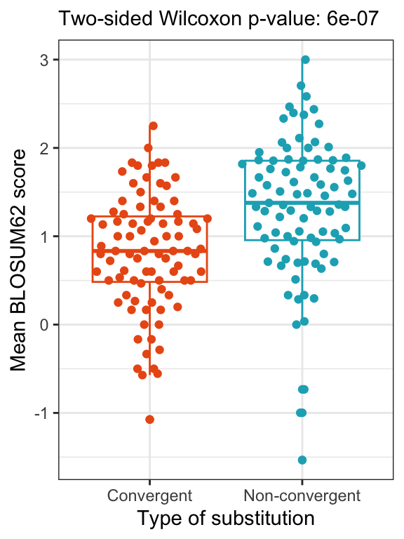

```r
#Load table
score_table<-readRDS("./RDS/sub_Matix_score_output.rds")
#Get p-values
signif((wilcox.test(x=score_table %>% group_by(pdb_id,type_of_sub) %>% summarise(mean_score=mean(sub_score,na.rm =T), .groups = "drop") %>%
                      filter(type_of_sub=="Convergent") %>% pull(mean_score),
                    y=score_table %>% group_by(pdb_id,type_of_sub) %>% summarise(mean_score=mean(sub_score,na.rm =T), .groups = "drop") %>%
                      filter(type_of_sub=="Non-convergent") %>% pull(mean_score)))$p.value, digits = 1)->p
#Make plot
score_table %>% group_by(pdb_id,type_of_sub) %>% summarise(mean_score=mean(sub_score,na.rm =T), .groups = "drop") %>%
  ggplot(aes(x=type_of_sub, y=mean_score, colour = type_of_sub))+
  geom_boxplot()+
  geom_quasirandom()+
  xlab("Type of substitution")+
  ylab("Mean BLOSUM62 score")+
  theme_bw()+
  theme(legend.position = "none")+
  scale_color_manual(values = c("#EA5B15","#1AAEC0"))+
  labs(subtitle = paste0("Two-sided Wilcoxon p-value: ",p))
```

### Distribution of convergent substitutions on protein structure

Here I check whether there is any relationship between the occurrence of convergence and site features on the protein. Using a chi-sq test of independence I found that in our data, there is no relationship between protein site feature and convergence. This tells me that there isn’t a general trend for convergence to be enriched on surface residues, rather it seems specific to each protein.

```r
prot<-read_csv("./Datasets/DatasetS0_csv_files/protein_sites/Session_pymol/combined_prots.csv") %>% filter(Localisation != "Localisation") %>% filter(Number_aa != "Number_aa") %>% filter(Name_aa != "Name_aa") %>% filter(near_lig != "near_lig") %>% filter(Secondary_Structure != "Secondary_Structure") %>% filter(convergence != "convergence") %>% filter(Localisation != "no_build") %>% filter(Secondary_Structure != "no_build")

chisq.test(table(prot$Localisation,prot$convergence),correct = F)
```

```
##
##  Pearson's Chi-squared test
##
## data:  table(prot$Localisation, prot$convergence)
## X-squared = 0.0054778, df = 1, p-value = 0.941
```

```r
chisq.test(table(prot$Secondary_Structure,prot$convergence),correct = F)
```

```
##
##  Pearson's Chi-squared test
##
## data:  table(prot$Secondary_Structure, prot$convergence)
## X-squared = 1.1428, df = 2, p-value = 0.5647
```

### Structural properties

Here I visualise the structural characteristics of the convergent substitutions to get an sense of where on the protein structure most sites are located.  
Original data found in Datasets/DatasetS0_csv_files/protein_sites/Session_pymol

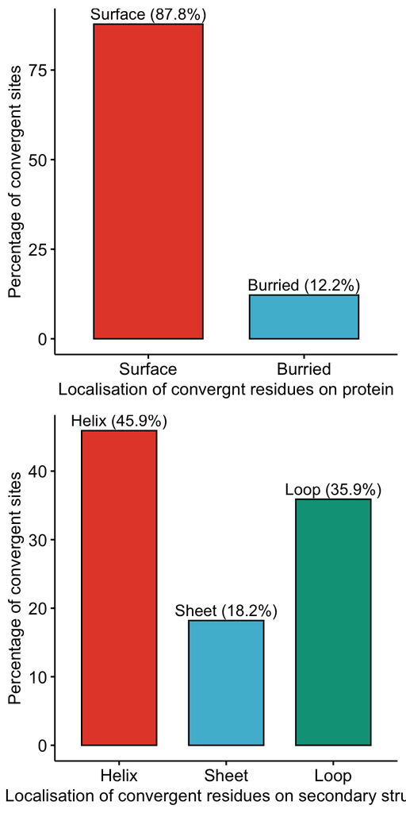

```r
str_dat<-tibble(surface = c("Surface","Burried"),
                no = c(159,22),
                n.per = round((no/sum(no))*100,digits = 1))
conf_dat<-tibble(conf = c("Helix","Sheet","Loop"),
                 no = c(83,33,65),
                 n.per = round((no/sum(no))*100,digits = 1))


labs1<-paste0(str_dat[[1]], " (", str_dat$n.per, "%)")
labs2<-paste0(conf_dat[[1]], " (", conf_dat$n.per, "%)")


g1<-ggpubr::ggbarplot(str_dat,x = "surface",y = "n.per",palette = "npg",color = "black",fill = "surface",label = labs1,xlab = "Localisation of convergnt residues on protein",ylab = "Percentage of convergent sites")
g2<-ggpubr::ggbarplot(conf_dat,x = "conf",y = "n.per",palette = "npg",color = "black",fill = "conf",label = labs2,xlab = "Localisation of convergent residues on secondary structure",ylab = "Percentage of convergent sites")

ggpubr::ggarrange(g1,g2,nrow = 2,legend = "none")
```

### Amino acid property changes

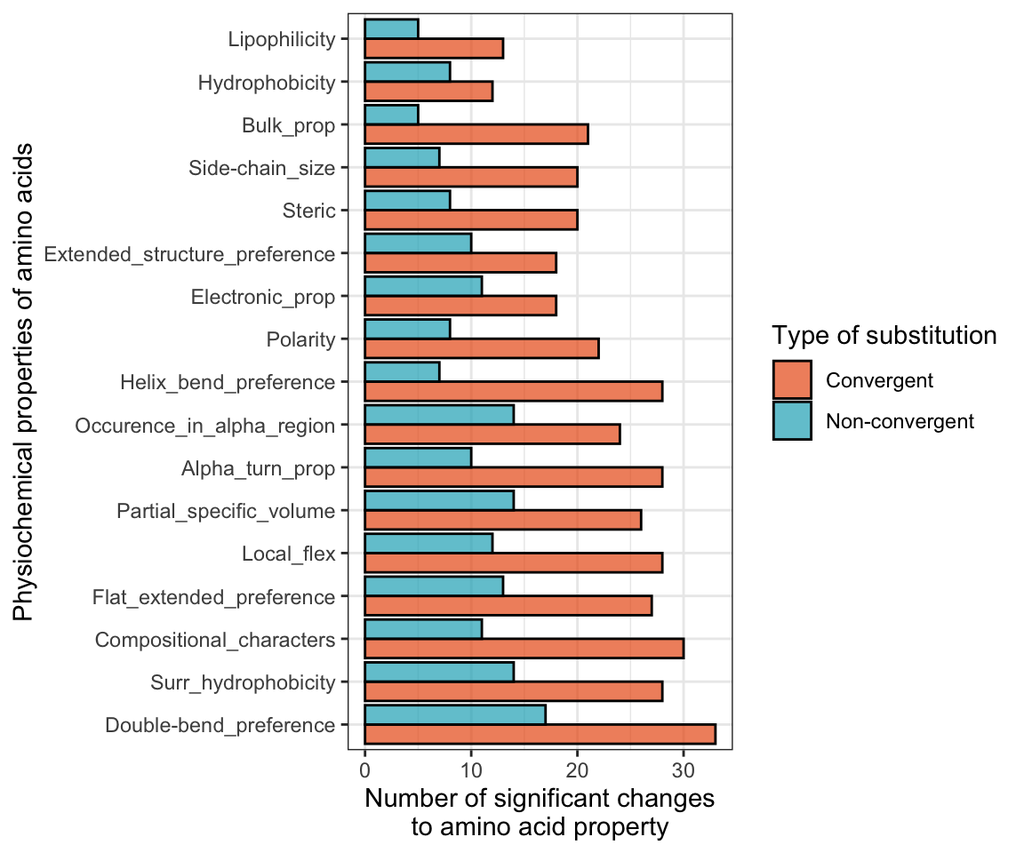

```r
#Load data
Properties_pval_output_table<-readRDS("./RDS/Properties_pval_output_will_test.rds")

#Make plots
Properties_pval_output_table %>%
  mutate(is_sig=case_when(wil_pval < 0.05 ~ "yes", .default = "no")) %>%
  filter(is_sig == "yes") %>% group_by(property, state) %>% dplyr::count(is_sig) %>% ungroup() %>%
  mutate(property=reorder(property,-n)) %>% dplyr::rename("Type of substitution"="state") %>%
  ggplot(aes(y=property, x=n))+
  geom_col(aes(fill=`Type of substitution`), alpha=0.7, color="black",position = "dodge")+
  scale_fill_manual(values = c("#EA5B15","#1AAEC0"))+
  xlab("Number of significant changes\nto amino acid property")+
  ylab("Physiochemical properties of amino acids")+
  theme_bw()
```

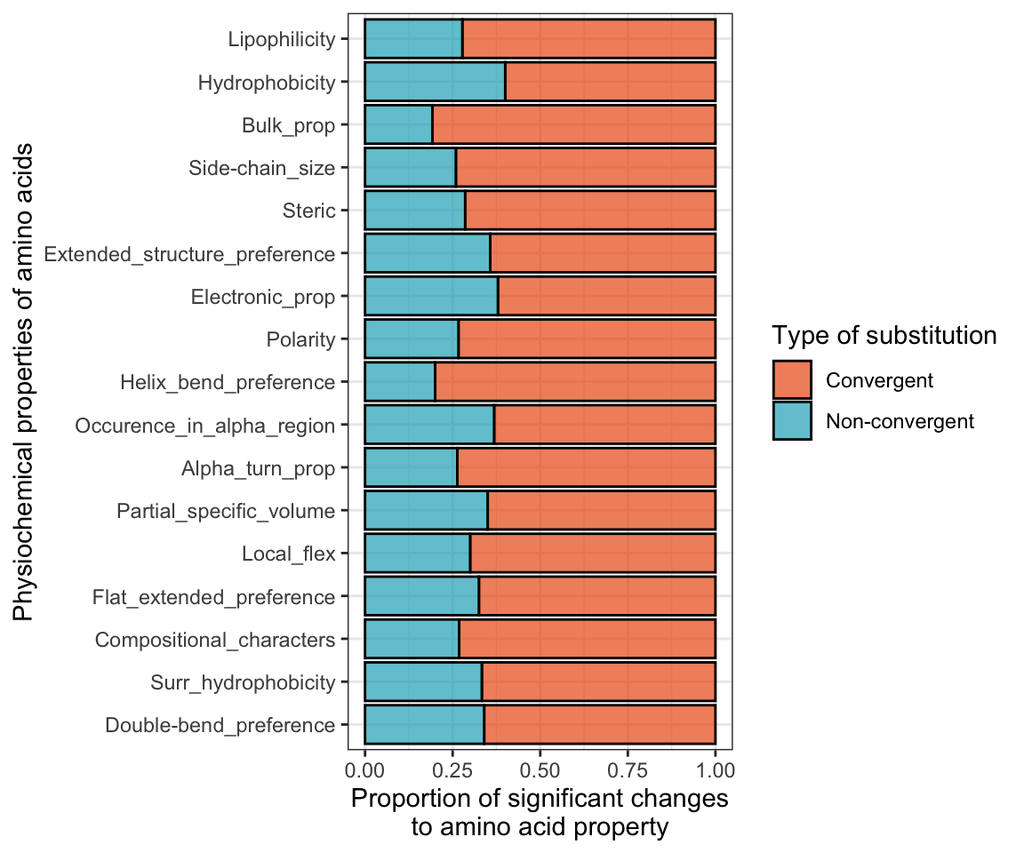

```r
Properties_pval_output_table %>%
  mutate(is_sig=case_when(wil_pval < 0.05 ~ "yes", .default = "no")) %>%
  filter(is_sig == "yes") %>% group_by(property, state) %>% dplyr::count(is_sig) %>% ungroup() %>%
  mutate(property=reorder(property,-n)) %>% dplyr::rename("Type of substitution"="state") %>%
  ggplot(aes(y=property, x=n))+
  geom_col(aes(fill=`Type of substitution`), alpha=0.7, color="black",position = "fill")+
  scale_fill_manual(values = c("#EA5B15","#1AAEC0"))+
  xlab("Proportion of significant changes\nto amino acid property")+
  ylab("Physiochemical properties of amino acids")+
  theme_bw()
```

## Analysing distribution of tissue specificity

In contrast to the previous analysis where we checked whether convergent genes were more tissue specific than other genes in the genome, this analysis compares the distributions of the values of the tissues-specificity index between convergent genes and all other genes. The distribution of tissue specificity of the convergent genes was significantly different compared to the background (two-sided Kolmogorov-Smirnov test P < 0.05), with the convergent genes having higher distribution at intermediate values of tissue specificity.

### Setting up analysis

```r
#Load data
skin<-orth_list %>% filter(orths %in% (readRDS("./RDS/Tau_0.8_TMM_cpm_with_log_no_combat_skin.rds")
                           %>% purrr::list_rbind() %>% dplyr::select(Gene.ID))$Gene.ID)
brain<-orth_list %>% filter(orths %in% (readRDS("./RDS/Tau_0.8_TMM_cpm_with_log_no_combat_brain.rds")
                           %>% purrr::list_rbind() %>% dplyr::select(Gene.ID))$Gene.ID)
eye<-orth_list %>% filter(orths %in% (readRDS("./RDS/Tau_0.8_TMM_cpm_with_log_no_combat_eye.rds")
                           %>% purrr::list_rbind() %>% dplyr::select(Gene.ID))$Gene.ID)
heart<-orth_list %>% filter(orths %in% (readRDS("./RDS/Tau_0.8_TMM_cpm_with_log_no_combat_heart.rds")
                           %>% purrr::list_rbind() %>% dplyr::select(Gene.ID))$Gene.ID)
liver<-orth_list %>% filter(orths %in% (readRDS("./RDS/Tau_0.8_TMM_cpm_with_log_no_combat_liver.rds")
                           %>% purrr::list_rbind() %>% dplyr::select(Gene.ID))$Gene.ID)
muscle<-orth_list %>% filter(orths %in% (readRDS("./RDS/Tau_0.8_TMM_cpm_with_log_no_combat_muscle.rds")
                           %>% purrr::list_rbind() %>% dplyr::select(Gene.ID))$Gene.ID)
ovary<-orth_list %>% filter(orths %in% (readRDS("./RDS/Tau_0.8_TMM_cpm_with_log_no_combat_ovary.rds")
                           %>% purrr::list_rbind() %>% dplyr::select(Gene.ID))$Gene.ID)
testis<-orth_list %>% filter(orths %in% (readRDS("./RDS/Tau_0.8_TMM_cpm_with_log_no_combat_testis.rds")
                           %>% purrr::list_rbind() %>% dplyr::select(Gene.ID))$Gene.ID)

#Get the orthologs that are exclusively tissue specific for each tissue
#brain
ts_list<-list(brain,eye,heart,liver,muscle,skin,ovary,testis) #change the first entry in the list when computing exclusive orthologs
brain_excl<-purrr::reduce(ts_list,anti_join, by = "Orthogroup")# %>% write_csv("./Datasets/DatasetS0_csv_files/Brain_exclusive_orths.csv")
#eye
ts_list<-list(eye,brain,heart,liver,muscle,skin,ovary,testis) #change the first entry in the list when computing exclusive orthologs
eye_excl<-purrr::reduce(ts_list,anti_join, by = "Orthogroup")# %>% write_csv("./Datasets/DatasetS0_csv_files/Eye_exclusive_orths.csv")
#heart
ts_list<-list(heart,brain,eye,liver,muscle,skin,ovary,testis) #change the first entry in the list when computing exclusive orthologs
heart_excl<-purrr::reduce(ts_list,anti_join, by = "Orthogroup")# %>% write_csv("./Datasets/DatasetS0_csv_files/Heart_exclusive_orths.csv")
#liver
ts_list<-list(liver,eye,brain,heart,muscle,skin,ovary,testis) #change the first entry in the list when computing exclusive orthologs
liver_excl<-purrr::reduce(ts_list,anti_join, by = "Orthogroup")# %>% write_csv("./Datasets/DatasetS0_csv_files/Liver_exclusive_orths.csv")
#muscle
ts_list<-list(muscle,eye,brain,heart,liver,skin,ovary,testis) #change the first entry in the list when computing exclusive orthologs
muscle_excl<-purrr::reduce(ts_list,anti_join, by = "Orthogroup")# %>% write_csv("./Datasets/DatasetS0_csv_files/Muscle_exclusive_orths.csv")
#skin
ts_list<-list(skin,eye,brain,heart,liver,muscle,ovary,testis) #change the first entry in the list when computing exclusive orthologs
skin_excl<-purrr::reduce(ts_list,anti_join, by = "Orthogroup")# %>% write_csv("./Datasets/DatasetS0_csv_files/Skin_exclusive_orths.csv")
#ovary
ts_list<-list(ovary,eye,brain,heart,liver,muscle,skin,testis) #change the first entry in the list when computing exclusive orthologs
ovary_excl<-purrr::reduce(ts_list,anti_join, by = "Orthogroup")# %>% write_csv("./Datasets/DatasetS0_csv_files/Overy_exclusive_orths.csv")
#testis
ts_list<-list(testis,eye,brain,heart,liver,muscle,skin,ovary) #change the first entry in the list when computing exclusive orthologs
testis_excl<-purrr::reduce(ts_list,anti_join, by = "Orthogroup")# %>% write_csv("./Datasets/DatasetS0_csv_files/Testis_exclusive_orths.csv")

rbind(brain_excl,eye_excl,heart_excl,liver_excl,muscle_excl,skin_excl,ovary_excl,testis_excl)->excl_tissue_spec

#convergent genes that are also tissue specific
d<-combined_arity %>% filter(Orthogroup %in% non_spuroius_conv$Orthogroup) %>% distinct(Orthogroup)

d<-d %>% mutate(c = "TRUE") %>%
  mutate(brain_c = if_else(d$Orthogroup %in% brain_excl$Orthogroup, TRUE, FALSE)) %>%
  mutate(eye_c = if_else(d$Orthogroup %in% eye_excl$Orthogroup, TRUE, FALSE)) %>%
  mutate(heart_c = if_else(d$Orthogroup %in% heart_excl$Orthogroup, TRUE, FALSE)) %>%
  mutate(liver_c = if_else(d$Orthogroup %in% liver_excl$Orthogroup, TRUE, FALSE)) %>%
  mutate(muscle_c = if_else(d$Orthogroup %in% muscle_excl$Orthogroup, TRUE, FALSE)) %>%
  mutate(skin_c = if_else(d$Orthogroup %in% skin_excl$Orthogroup, TRUE, FALSE)) %>%
  mutate(ovary_c = if_else(d$Orthogroup %in% ovary_excl$Orthogroup, TRUE, FALSE)) %>%
  mutate(testis_c = if_else(d$Orthogroup %in% testis_excl$Orthogroup, TRUE, FALSE))


d %>% mutate(spec_in_tissue=
               case_when(brain_c==TRUE ~ "brain",
                         eye_c==TRUE ~ "eye",
                         heart_c==TRUE ~ "heart",
                         liver_c==TRUE ~ "liver",
                         muscle_c==TRUE ~ "muscle",
                         skin_c==TRUE ~ "skin",
                         ovary_c==TRUE ~ "ovary",
                         testis_c==TRUE ~ "testis")) %>% dplyr::select(Orthogroup,spec_in_tissue) %>% drop_na()->excl_conv_tissue

left_join(tau_dat_all$Danio_rerio,
          danio_conv %>% dplyr::select(Orthogroup,orths) %>% dplyr::rename("Gene.ID"="orths") %>% mutate(conv="yes"),
          by = "Gene.ID") %>% distinct(Gene.ID,.keep_all = T) %>% replace_na(list(conv="no")) %>% rowwise() %>%
  mutate(num_tissues = sum(c_across(-c(Gene.ID,tau,conv,,Orthogroup)) > 0.1)) %>%
  ungroup()->Danio_tau_conv_all

left_join(Danio_tau_conv_all, excl_conv_tissue, by = "Orthogroup") %>% mutate(spec_in_tissue=replace_na(spec_in_tissue,"no_tsp")) %>%
  mutate(is_tsp=case_when(spec_in_tissue=="no_tsp" ~ "no", .default = "yes"))->estimated_ts_conv_Danio_tau_conv_all
```

### Distribution of tissue-specificity

```r
#load all tissue-specificity data
tau_dat_all<-readRDS("./RDS/tau_dat_all.rds")
#Function to plot tissue specificity and compare distributions.
ts_dis_plots<-function(dat,sp_name){
  inner_join(
    dat,
    orth_list %>% filter(sp==sp_name) %>% dplyr::rename("Gene.ID"=orths) %>%
      dplyr::select(Gene.ID,Orthogroup), by = "Gene.ID") %>%
    mutate(state=case_when(Orthogroup %in% non_spuroius_conv$Orthogroup ~ "Convergent", .default = "Non-convergent")) %>% mutate(is_tsp=case_when(tau >= 0.8~"yes",.default = "no"))->tau_dist_dat

  #gets p-val for the ks test
  ks_test_pval<-(ks.test(x=tau_dist_dat %>% filter(state=="Convergent") %>% pull(tau),
                         y=tau_dist_dat %>% filter(state=="Non-convergent") %>% pull(tau)))$p.value %>% round(4)
#Plot
  tau_dist_dat %>%
    ggplot(aes(x=tau, fill = state, y=..density..))+
    geom_density(alpha=0.6)+
    facet_grid(rows=vars(state))+
    scale_fill_manual(values = c("#EA5B15","#1AAEC0"))+
    geom_vline(xintercept = 0.3, linetype="dashed")+#low tissue-specificity
    geom_vline(xintercept = 0.8, linetype="dashed")+#high tissue-specificity
    theme_bw()+
    labs(title=paste0(str_replace(pattern = "_", string = sp_name, replacement = " ")),
         subtitle = paste0("Two-sided KS test p-value: ",ks_test_pval))+
    theme(plot.title = element_text(face = "italic"))->dist_ts

  ggpubr::ggarrange(dist_ts,legend = "none") %>% return()
  #tau_dist_dat %>% return() #for dist tests
}

ggpubr::ggarrange(
  ts_dis_plots(tau_dat_all$Astyanax_mexicanus, sp_name = "Astyanax_mexicanus"),
  ts_dis_plots(tau_dat_all$Astatotilapia_calliptera, sp_name = "Astatotilapia_calliptera"),
  ts_dis_plots(tau_dat_all$Danio_rerio, sp_name = "Danio_rerio"),
  ts_dis_plots(tau_dat_all$Esox_lucius, sp_name = "Esox_lucius"),
  ts_dis_plots(tau_dat_all$Gasterosteus_aculeatus, sp_name = "Gasterosteus_aculeatus"),
  ts_dis_plots(tau_dat_all$Gadus_morhua, sp_name = "Gadus_morhua"),
  ts_dis_plots(tau_dat_all$Neolamprologus_brichardi, sp_name = "Neolamprologus_brichardi"),
  ts_dis_plots(tau_dat_all$Nothobranchius_furzeri, sp_name = "Nothobranchius_furzeri"),
  ts_dis_plots(tau_dat_all$Oryzias_latipes, sp_name = "Oryzias_latipes"),
  ts_dis_plots(tau_dat_all$Salmo_salar, sp_name = "Salmo_salar"),
  ts_dis_plots(tau_dat_all$Scophthalmus_maximus, sp_name = "Scophthalmus_maximus"))->ts_dis_dat
#ts_dis_dat %>% saveRDS("./RDS/ts_dis_dat.rds")
```

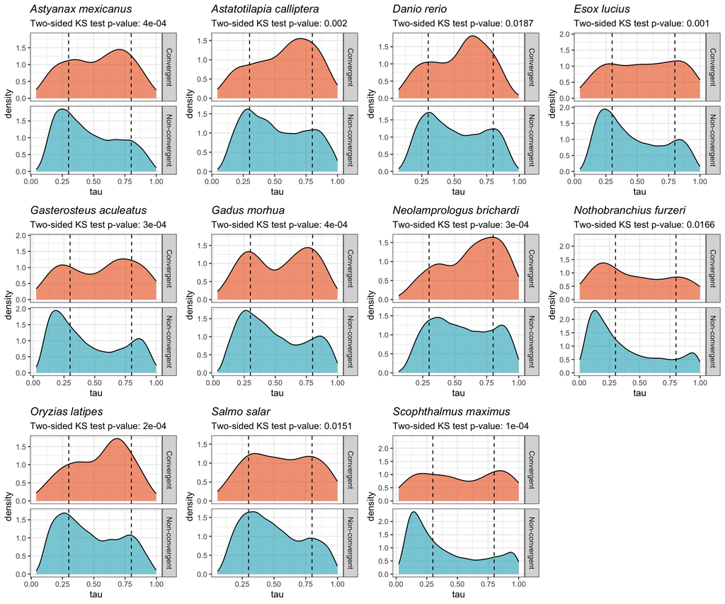

```r
readRDS("./RDS/ts_dis_dat.rds")
```

### Test of unimodality

Using the Sileverman (Silverman 1981) and Hartigan (Hartigan and Hartigan 1985) tests of unimodality we observed that the tissue-specificity index (tau) of the convergent gene sets resembled a more unimodal distribution as compared to the bimodal distribution of the background set. In this test we set the null hypothesis as the modality we want to test, and check whether the test distribution deviates from it. For example, we set the null hypothesis as a unimodal distribution, and we check whether the distribution of tau of convergent gene deviates from it. A non-significant p-value indicates we cannot reject the null hypothesis, i.e. our distribution is unimodal. We also compared the distribution of tau for all the other genes and found that they always deviate the null distribution i.e. p-values < 0.05.

```r
#function to carry out modality analysis
mode_test<-function(dat,sp){
  library(multimode)
  set.seed(0000) #set seed for the boot strapping
  #Hardigan's dip test
  tibble(sp=sp,
         #this is for the convergent gene sets
         test_sil_pval=(modetest(ts_dis_plots(dat, sp_name = sp) %>%
                                   filter(Orthogroup %in% non_spuroius_conv$Orthogroup) %>%
                                   pull(tau), mod0 = 1, method = "HH",B=1000, submethod=NULL))$p.value,
         #this is for the background genes
         bg_sil_pval=(modetest(ts_dis_plots(tau_dat_all$Danio_rerio, sp_name = "Danio_rerio") %>%
                                 filter(!Orthogroup %in% non_spuroius_conv$Orthogroup) %>%
                                 pull(tau), mod0 = 1, method = "HH",B=1000, submethod=NULL))$p.value) %>%
    mutate(is_unimodal=case_when(test_sil_pval > 0.05  & bg_sil_pval < 0.05 ~ "yes", .default = "no"),
           test="Hardigan")->HH
  #Silverman's mode estimator
  tibble(sp=sp,
         test_sil_pval=(modetest(ts_dis_plots(dat, sp_name = sp) %>%
                                   filter(Orthogroup %in% non_spuroius_conv$Orthogroup) %>%
                                   pull(tau), mod0 = 1, method = "SI",B=1000, submethod=1))$p.value,
         bg_sil_pval=(modetest(ts_dis_plots(tau_dat_all$Danio_rerio, sp_name = "Danio_rerio") %>%
                                 filter(!Orthogroup %in% non_spuroius_conv$Orthogroup) %>%
                                 pull(tau), mod0 = 1, method = "SI",B=1000, submethod=1))$p.value) %>%
    mutate(is_unimodal=case_when(test_sil_pval > 0.05  & bg_sil_pval < 0.05 ~ "yes", .default = "no"),
           test="Silverman")->SI

  rbind(HH,SI) %>% return()
}

rbind(
  mode_test(dat=tau_dat_all$Astatotilapia_calliptera, sp="Astatotilapia_calliptera"),
  mode_test(dat=tau_dat_all$Astyanax_mexicanus, sp="Astyanax_mexicanus"),
  mode_test(dat=tau_dat_all$Danio_rerio, sp="Danio_rerio"),
  mode_test(dat=tau_dat_all$Esox_lucius, sp="Esox_lucius"),
  mode_test(dat=tau_dat_all$Gasterosteus_aculeatus, sp="Gasterosteus_aculeatus"),
  mode_test(dat=tau_dat_all$Gadus_morhua, sp="Gadus_morhua"),
  mode_test(dat=tau_dat_all$Neolamprologus_brichardi, sp="Neolamprologus_brichardi"),
  mode_test(dat=tau_dat_all$Nothobranchius_furzeri, sp="Nothobranchius_furzeri"),
  mode_test(dat=tau_dat_all$Oryzias_latipes, sp="Oryzias_latipes"),
  mode_test(dat=tau_dat_all$Salmo_salar, sp="Salmo_salar"),
  mode_test(dat=tau_dat_all$Scophthalmus_maximus, sp="Scophthalmus_maximus")
)->dist_test_out
```

### Plot the modality test results

```r
dist_test_out<-readRDS("./RDS/dist_test_out.rds")

dist_test_out
```

| sp | test_sil_pval | bg_sil_pval | is_unimodal | test |
| --- | --- | --- | --- | --- |
| Astatotilapia_calliptera | 0.964 | 0 | yes | Hardigan |
| Astatotilapia_calliptera | 0.826 | 0 | yes | Silverman |
| Astyanax_mexicanus | 0.570 | 0 | yes | Hardigan |
| Astyanax_mexicanus | 0.488 | 0 | yes | Silverman |
| Danio_rerio | 0.876 | 0 | yes | Hardigan |
| Danio_rerio | 0.844 | 0 | yes | Silverman |
| Esox_lucius | 0.990 | 0 | yes | Hardigan |
| Esox_lucius | 0.506 | 0 | yes | Silverman |
| Gasterosteus_aculeatus | 0.106 | 0 | yes | Hardigan |
| Gasterosteus_aculeatus | 0.102 | 0 | yes | Silverman |

[output cut: 12 more lines]

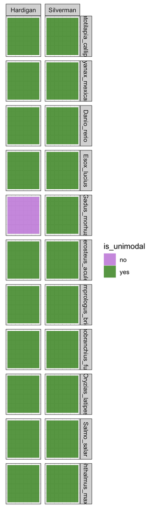

```r
dist_test_out %>%
  ggplot(aes(x=1,y=1, fill=is_unimodal))+
  facet_grid(rows=vars(sp),cols=vars(test))+
  geom_tile(alpha=0.85)+
  scale_fill_manual(values = c("#C78BDD","#47932C"))+
  theme_bw()+
  ylab(NULL)+
  xlab(NULL)+
  theme(
    axis.text.x = element_blank(),
    axis.ticks.x  = element_blank(),
    axis.text.y = element_blank(),
    axis.ticks.y = element_blank()
  )
```

### Get single cell distribution

```r
library(SingleCellExperiment)
library(scater)
library(scuttle)

danio_conv<-read_csv("./Datasets/DatasetS0_csv_files/Danio_rerio_convergent_genes.csv")
Danio_biomart<-read_csv("./Datasets/DatasetS0_csv_files/Danio_biomart.csv")
zhub_dat<-readRDS("./RDS/zhub_full_log.rds")

left_join(estimated_ts_conv_Danio_tau_conv_all,
          Danio_biomart %>% dplyr::select(`Gene stable ID`, `Gene name`) %>%
            dplyr::rename("Gene.ID"=`Gene stable ID`),
          by = "Gene.ID") %>% distinct(Gene.ID, .keep_all = T)->estimated_ts_conv_Danio_tau_conv_all

#Function to load single cell data and process it
single_cell_df<-function(stage,gene_in){

  zhub_dat<-readRDS(paste0("./RDS/zhub_",stage,"_log.rds"))
  scuttle::makePerCellDF(zhub_dat, features = gene_in, assay.type = "logcounts", swap.rownames="gene_ids")  %>%
  dplyr::rename("logCounts"=gene_in) %>% filter(logCounts >= 0.5) %>% mutate(gene=gene_in)->cell_df

  num_of_samples<-(length(cell_df %>% distinct(fish) %>% pull(fish))-1)

  #Keep the cells with expression in at least max-1 samples
    cell_df %>% group_by(zebrafish_anatomy_ontology_class) %>% summarise(count_fish=n_distinct(fish), .groups = "keep") %>%
      ungroup() %>% filter(count_fish >= num_of_samples)->filter_in_cell_type

  cell_df %>% filter(zebrafish_anatomy_ontology_class %in% filter_in_cell_type$zebrafish_anatomy_ontology_class) %>%
    dplyr::select(gene,logCounts,timepoint,zebrafish_anatomy_ontology_class,
                  zebrafish_anatomy_ontology_id,fish,
                  X_umap.1,X_umap.2)->cell_df

    return(cell_df)
}


single_cell_df<-possibly(.f = single_cell_df, otherwise = NULL)


purrr::map(.x=as.list(head(estimated_ts_conv_Danio_tau_conv_all %>%
    filter(conv=="yes") %>% pull(Gene.ID))),
           ~single_cell_df(stage = "10hpf",gene_in = .x)) %>% list_rbind()->conv_cells_10hpf

purrr::map(.x=as.list(estimated_ts_conv_Danio_tau_conv_all %>%
                        filter(conv=="yes") %>% pull(Gene.ID)),
           ~single_cell_df(stage = "12hpf",gene_in = .x)) %>% list_rbind()->conv_cells_12hpf

purrr::map(.x=as.list(estimated_ts_conv_Danio_tau_conv_all %>%
                        filter(conv=="yes") %>% pull(Gene.ID)),
           ~single_cell_df(stage = "14hpf",gene_in = .x)) %>% list_rbind()->conv_cells_14hpf

purrr::map(.x=as.list(estimated_ts_conv_Danio_tau_conv_all %>%
                        filter(conv=="yes") %>% pull(Gene.ID)),
           ~single_cell_df(stage = "16hpf",gene_in = .x)) %>% list_rbind()->conv_cells_16hpf

purrr::map(.x=as.list(estimated_ts_conv_Danio_tau_conv_all %>%
                        filter(conv=="yes") %>% pull(Gene.ID)),
           ~single_cell_df(stage = "19hpf",gene_in = .x)) %>% list_rbind()->conv_cells_19hpf

purrr::map(.x=as.list(estimated_ts_conv_Danio_tau_conv_all %>%
                        filter(conv=="yes") %>% pull(Gene.ID)),
           ~single_cell_df(stage = "24hpf",gene_in = .x)) %>% list_rbind()->conv_cells_24hpf

purrr::map(.x=as.list(estimated_ts_conv_Danio_tau_conv_all %>%
                        filter(conv=="yes") %>% pull(Gene.ID)),
           ~single_cell_df(stage = "3dpf",gene_in = .x)) %>% list_rbind()->conv_cells_3dpf

purrr::map(.x=as.list(estimated_ts_conv_Danio_tau_conv_all %>%
                        filter(conv=="yes") %>% pull(Gene.ID)),
           ~single_cell_df(stage = "5dpf",gene_in = .x)) %>% list_rbind()->conv_cells_5dpf

purrr::map(.x=as.list(estimated_ts_conv_Danio_tau_conv_all %>%
                        filter(conv=="yes") %>% pull(Gene.ID)),
           ~single_cell_df(stage = "10dpf",gene_in = .x)) %>% list_rbind()->conv_cells_10dpf


#All cells
system.time(
purrr::map(.x=as.list(rowData(zhub_dat)$gene_ids[1:20]),
           ~single_cell_df(stage = "10hpf",gene_in = .x)) %>% list_rbind()->all_gene_10hpf
)


purrr::map(.x=as.list(rowData(zhub_dat)$gene_ids),
           ~single_cell_df(stage = "12hpf",gene_in = .x)) %>% list_rbind()->all_gene_12hpf
all_gene_12hpf %>% saveRDS("./RDS/all_gene_12hpf.rds")

purrr::map(.x=as.list(rowData(zhub_dat)$gene_ids),
           ~single_cell_df(stage = "14hpf",gene_in = .x)) %>% list_rbind()->all_gene_14hpf
all_gene_14hpf %>% saveRDS("./RDS/all_gene_14hpf.rds")

purrr::map(.x=as.list(rowData(zhub_dat)$gene_ids),
           ~single_cell_df(stage = "16hpf",gene_in = .x)) %>% list_rbind()->all_gene_16hpf

purrr::map(.x=as.list(rowData(zhub_dat)$gene_ids),
           ~single_cell_df(stage = "19hpf",gene_in = .x)) %>% list_rbind()->all_gene_19hpf

purrr::map(.x=as.list(rowData(zhub_dat)$gene_ids),
           ~single_cell_df(stage = "24hpf",gene_in = .x)) %>% list_rbind()->all_gene_24hpf

purrr::map(.x=as.list(rowData(zhub_dat)$gene_ids),
           ~single_cell_df(stage = "3dpf",gene_in = .x)) %>% list_rbind()->conv_cells_3dpf

purrr::map(.x=as.list(rowData(zhub_dat)$gene_ids),
           ~single_cell_df(stage = "5dpf",gene_in = .x)) %>% list_rbind()->all_gene_5dpf

purrr::map(.x=as.list(rowData(zhub_dat)$gene_ids),
           ~single_cell_df(stage = "10dpf",gene_in = .x)) %>% list_rbind()->all_gene_10dpf

sc_dist_analysis<-function(sc_dat, plot_title){

#count the number of unique cell types per gene and get their ortholog annotations
inner_join(
  sc_dat %>% summarise(no_uniq_cells_types=n_distinct(zebrafish_anatomy_ontology_class), .by = "gene"),
  orth_list %>% dplyr::select(Orthogroup,orths,sp) %>% filter(sp=="Danio_rerio") %>% dplyr::rename("gene"=orths),by = "gene") %>% dplyr::rename("Gene.ID"=gene)->cell_types_orth

#Get information on convergence
rbind(
cell_types_orth %>% filter(Orthogroup %in% non_spuroius_conv$Orthogroup) %>% mutate(state="conv"),
cell_types_orth %>% filter(!Orthogroup %in% non_spuroius_conv$Orthogroup) %>% mutate(state="non_conv"))->test_dat
#Get information of tissue specificity
test_dat %>% mutate(is_tsp=case_when(Orthogroup %in% (estimated_ts_conv_Danio_tau_conv_all %>% filter(is_tsp=="yes"))$Orthogroup ~ "yes",.default = "no"))->test_dat

(ks.test(x=test_dat  %>% filter(state=="conv") %>% pull(no_uniq_cells_types),
        y=test_dat  %>% filter(state=="non_conv") %>% pull(no_uniq_cells_types),
            alternative = "two.sided"))$p.value->ks_pval_two_sided
(ks.test(x=test_dat  %>% filter(state=="conv") %>% pull(no_uniq_cells_types),
        y=test_dat  %>% filter(state=="non_conv") %>% pull(no_uniq_cells_types),
            alternative = "greater"))$p.value->ks_pval_greater
(ks.test(x=test_dat  %>% filter(state=="conv") %>% pull(no_uniq_cells_types),
        y=test_dat  %>% filter(state=="non_conv") %>% pull(no_uniq_cells_types),
            alternative = "less"))$p.value->ks_pval_less

test_dat %>%
  ggplot(aes(x=no_uniq_cells_types, fill = state))+
  geom_density(alpha=0.6)+
  scale_fill_manual(values = c("#EA5B15","#1AAEC0"))+
  xlab("Number of unique cell types")+
  labs(title = str_remove(string = paste0(plot_title),
                          pattern ="all_gene_"),
       subtitle = paste0("One-sided KS-test p-value: ", signif(ks_pval_greater, digits = 3)))+
  theme_bw()+
  theme(text = element_text(size=8))->dist_plot

test_dat  %>%
  ggplot(aes(x=no_uniq_cells_types, color= state))+
  stat_ecdf()+
  xlab("Number of unique cell types")+
  scale_color_manual(values = c("#EA5B15","#1AAEC0"))+
  theme_bw()+
  labs(title = "Cumulative probability distrubutions")+
  theme(text = element_text(size=8))->ecdf_plot

ggarrange(dist_plot, ecdf_plot, ncol = 1, common.legend = T)->c_plot


return(list(dist_plot_dat=dist_plot$data,c_plot=c_plot, ks_pval_two_sided=ks_pval_two_sided, ks_pval_greater=ks_pval_greater, ks_pval_less=ks_pval_less))
}

#Load processed sc data frame and run above function
all_gene_10hpf<-readRDS("./RDS/all_gene_10hpf.rds")
sc_dist_analysis(sc_dat = all_gene_10hpf, plot_title= "Distribution of gene expression\nin unique cell types at 10hpf")->dist_res_10hpf
dist_res_10hpf %>% saveRDS("./RDS/dist_res_10hpf.rds")
rm(all_gene_10hpf)

all_gene_12hpf<-readRDS("./RDS/all_gene_12hpf.rds")
sc_dist_analysis(sc_dat = all_gene_12hpf, plot_title= "Distribution of gene expression\nin unique cell types at 12hpf")->dist_res_12hpf
dist_res_12hpf %>% saveRDS("./RDS/dist_res_12hpf.rds")
rm(all_gene_12hpf)

all_gene_14hpf<-readRDS("./RDS/all_gene_14hpf.rds")
sc_dist_analysis(sc_dat = all_gene_14hpf, plot_title= "Distribution of gene expression\nin unique cell types at 14hpf")->dist_res_14hpf
dist_res_14hpf %>% saveRDS("./RDS/dist_res_14hpf.rds")
rm(all_gene_14hpf)

all_gene_16hpf<-readRDS("./RDS/all_gene_16hpf.rds")
sc_dist_analysis(sc_dat = all_gene_16hpf, plot_title= "Distribution of gene expression\nin unique cell types at 16hpf")->dist_res_16hpf
dist_res_16hpf %>% saveRDS("./RDS/dist_res_16hpf.rds")
rm(all_gene_16hpf)

all_gene_19hpf<-readRDS("./RDS/all_gene_19hpf.rds")
sc_dist_analysis(sc_dat = all_gene_19hpf, plot_title= "Distribution of gene expression\nin unique cell types at 19hpf")->dist_res_19hpf
dist_res_19hpf %>% saveRDS("./RDS/dist_res_19hpf.rds")
rm(all_gene_19hpf)

all_gene_24hpf<-readRDS("./RDS/all_gene_24hpf.rds")
sc_dist_analysis(sc_dat = all_gene_24hpf, plot_title= "Distribution of gene expression\nin unique cell types at 24hpf")->dist_res_24hpf
dist_res_24hpf %>% saveRDS("./RDS/dist_res_24hpf.rds")
rm(all_gene_24hpf)

all_gene_3dpf<-readRDS("./RDS/all_gene_3dpf.rds")
sc_dist_analysis(sc_dat = all_gene_3dpf, plot_title= "Distribution of gene expression\nin unique cell types at 3dpf")->dist_res_3dpf
dist_res_3dpf %>% saveRDS("./RDS/dist_res_3dpf.rds")
rm(all_gene_3dpf)

all_gene_5dpf<-readRDS("./RDS/all_gene_5dpf.rds")
sc_dist_analysis(sc_dat = all_gene_5dpf, plot_title= "Distribution of gene expression\nin unique cell types at 5dpf")->dist_res_5dpf
dist_res_5dpf %>% saveRDS("./RDS/dist_res_5dpf.rds")
rm(all_gene_5dpf)

all_gene_10dpf<-readRDS("./RDS/all_gene_10dpf.rds")
sc_dist_analysis(sc_dat = all_gene_10dpf, plot_title= "Distribution of gene expression\nin unique cell types at 10dpf")->dist_res_10dpf
dist_res_10dpf %>% saveRDS("./RDS/dist_res_10dpf.rds")#This takes very long; couple of hours and is a very large rds (~1.5GB). Therefore, have not included
rm(all_gene_10dpf)

dist_res_10hpf<-readRDS("./RDS/dist_res_10hpf.rds")
dist_res_12hpf<-readRDS("./RDS/dist_res_12hpf.rds")
dist_res_14hpf<-readRDS("./RDS/dist_res_14hpf.rds")
dist_res_16hpf<-readRDS("./RDS/dist_res_16hpf.rds")
dist_res_19hpf<-readRDS("./RDS/dist_res_19hpf.rds")
dist_res_24hpf<-readRDS("./RDS/dist_res_24hpf.rds")
dist_res_3dpf<-readRDS("./RDS/dist_res_3dpf.rds")
dist_res_5dpf<-readRDS("./RDS/dist_res_5dpf.rds")
dist_res_10dpf<-readRDS("./RDS/dist_res_10dpf.rds")#This takes very long; couple of hours and is a very large rds (~1.5GB). Therefore, have not included
```

```r
dist_res_10hpf
```

### Running cell distribution analysis for random set of genes

```r
sc_dist_random<-function(sc_dat, plot_title){

#count the number of unique cell types per gene and get their ortholog annotations
inner_join(
  sc_dat %>% summarise(no_uniq_cells_types=n_distinct(zebrafish_anatomy_ontology_class), .by = "gene"),
  orth_list %>% dplyr::select(Orthogroup,orths,sp) %>% filter(sp=="Danio_rerio") %>% dplyr::rename("gene"=orths),by = "gene") %>% dplyr::rename("Gene.ID"=gene)->cell_types_orth

#Takes a random set of 89 orthogroups
rbind(
  cell_types_orth %>% filter(Orthogroup %in% (orth_list %>% distinct(Orthogroup) %>% pull(Orthogroup))[runif(89, min = 1, max = 8308)]) %>%
    mutate(state="conv"), cell_types_orth %>% filter(!Orthogroup %in% non_spuroius_conv$Orthogroup) %>% mutate(state="non_conv"))->test_dat

#Get information of tissue specificity
test_dat %>% mutate(is_tsp=case_when(Orthogroup %in% (estimated_ts_conv_Danio_tau_conv_all %>% filter(is_tsp=="yes"))$Orthogroup ~ "yes",.default = "no"))->test_dat


(ks.test(x=test_dat  %>% filter(state=="conv") %>% pull(no_uniq_cells_types),
        y=test_dat  %>% filter(state=="non_conv") %>% pull(no_uniq_cells_types),
            alternative = "two.sided"))$p.value->ks_pval_two_sided
(ks.test(x=test_dat  %>% filter(state=="conv") %>% pull(no_uniq_cells_types),
        y=test_dat  %>% filter(state=="non_conv") %>% pull(no_uniq_cells_types),
            alternative = "greater"))$p.value->ks_pval_greater
(ks.test(x=test_dat  %>% filter(state=="conv") %>% pull(no_uniq_cells_types),
        y=test_dat  %>% filter(state=="non_conv") %>% pull(no_uniq_cells_types),
            alternative = "less"))$p.value->ks_pval_less

test_dat %>%
  ggplot(aes(x=no_uniq_cells_types, fill = state))+
  geom_density(alpha=0.6)+
  scale_fill_manual(values = c("#EA5B15","#1AAEC0"))+
  xlab("Number of unique cell types")+
  labs(title = str_remove(string = paste0(plot_title),
                          pattern ="all_gene_"),
       subtitle = paste0("One-sided KS-test p-value: ", signif(ks_pval_greater, digits = 3)))+
  theme_bw()+
  theme(text = element_text(size=8))->dist_plot

test_dat  %>%
  ggplot(aes(x=no_uniq_cells_types, color= state))+
  stat_ecdf()+
  xlab("Number of unique cell types")+
  scale_color_manual(values = c("#EA5B15","#1AAEC0"))+
  theme_bw()+
  labs(title = "Cumulative probability distrubutions")+
  theme(text = element_text(size=8))->ecdf_plot


ggarrange(dist_plot, ecdf_plot, ncol = 1, common.legend = T)->c_plot

return(list(c_plot=c_plot, ks_pval_two_sided=ks_pval_two_sided, ks_pval_greater=ks_pval_greater, ks_pval_less=ks_pval_less))
}

sc_dist_random(sc_dat = all_gene_10hpf, plot_title= "Random genes at 10hpf")->dist_random_10hpf

sc_dist_random(sc_dat = all_gene_10dpf, plot_title= "Random genes at 10dpf")->dist_random_10dpf
```

## Sementic Similaritry of gene sets

In this section I check whether the convergent genes and sets of non-convergent (background) genes differ in terms of the diversity of biological features they are associated with. To do this I estimate Sementic Similaritry (SS) of the GO terms. SS uses the information content of GO terms as well as their ontology structure to allow comparison of genes annotated with GO terms. Higher the SS the more closely related two gene products (or gene sets are). I estimate the pairwise SS of two gene sets, the convergent genes and a background gene set. I found that the convergent genes on an average, have lower SS for Biological Process terms and Cellular Component terms than a background set (one-sided KS-test). This implies that the convergent gene sets are likely associate with more diverse set of processes and are expressed in a more diverse cellular structures than the background.

### Loading the GO annotations

```r
library(GOSemSim)
library(org.Dr.eg.db)
library(AnnotationDbi)

#Load Danio data
read_csv("./Datasets/DatasetS0_csv_files/Danio_biomart.csv")->Danio_biomart
danio_conv<-read_csv("./Datasets/DatasetS0_csv_files/Danio_rerio_convergent_genes.csv")
#Get GO data
go_annotations <- select(org.Dr.eg.db,
                         keys = keys(org.Dr.eg.db, keytype = "ENSEMBL"),
                         columns = c("GO", "ONTOLOGY"),
                         keytype = "ENSEMBL")

#Prepare the semantic data
drGO_BP<-godata('org.Dr.eg.db', keytype="ENSEMBL", ont="BP")
drGO_MF<-godata('org.Dr.eg.db', keytype="ENSEMBL", ont="MF")
drGO_CC<-godata('org.Dr.eg.db', keytype="ENSEMBL", ont="CC")

#Specify gene sets
geneset_conv<-orth_list %>% filter(sp=="Danio_rerio") %>% filter(Orthogroup %in% non_spuroius_conv$Orthogroup)
geneset_nc<-orth_list %>% filter(sp=="Danio_rerio") %>% filter(!Orthogroup %in% non_spuroius_conv$Orthogroup)

#Retrieve annotations
go_annotations_BP <- go_annotations %>% filter(ONTOLOGY=="BP")
go_annotations_MF <- go_annotations %>% filter(ONTOLOGY=="MF")
go_annotations_CC <- go_annotations %>% filter(ONTOLOGY=="CC")
```

### Calculating SS

```r
#Select a random geneset a background
#I've repeated the analysis using multiple random gene sets are the result is always the same. Try!
#Selecting 120 Orthogroups gives around the same number of genes
#We also ran this with 2000 random orthogroups as the background, and we sill get the same results. Note, this analysis can take some time.
#set.seed(1234)
random_set<-(geneset_nc %>% distinct(Orthogroup))$Orthogroup[runif(120,min = 1,9061) %>% round()]

#Compute SS between gene sets for each GO term category
mgeneSim(genes=geneset_conv$orths,
         semData=drGO_BP, measure="Wang",verbose=FALSE, combine = "BMA")->gene_sem_conv_BP
mgeneSim(genes=geneset_nc %>%
           filter(Orthogroup %in% random_set) %>% pull(orths),
         semData=drGO_BP, measure="Wang",verbose=FALSE, combine = "BMA")->gene_sem_nc_BP
mgeneSim(genes=geneset_conv$orths,
         semData=drGO_MF, measure="Wang",verbose=FALSE, combine = "BMA")->gene_sem_conv_MF
mgeneSim(genes=geneset_nc %>%
           filter(Orthogroup %in% random_set) %>% pull(orths),
         semData=drGO_MF, measure="Wang",verbose=FALSE, combine = "BMA")->gene_sem_nc_MF
mgeneSim(genes=geneset_conv$orths,
         semData=drGO_CC, measure="Wang",verbose=FALSE, combine = "BMA")->gene_sem_conv_CC
mgeneSim(genes=geneset_nc %>%
           filter(Orthogroup %in% random_set) %>% pull(orths),
         semData=drGO_CC, measure="Wang",verbose=FALSE, combine = "BMA")->gene_sem_nc_CC

#remove self comparisons and symetric comparisons and combine into one df
rbind(
  reshape2::melt(gene_sem_nc_BP) %>% filter(Var1!=Var2) %>%
    distinct(Var1, Var2, .keep_all = TRUE)%>% mutate(type="Non-convergent",GO_group="BP"),
  reshape2::melt(gene_sem_nc_MF) %>% filter(Var1!=Var2) %>%
    distinct(Var1, Var2, .keep_all = TRUE)%>% mutate(type="Non-convergent",GO_group="MF"),
  reshape2::melt(gene_sem_nc_CC) %>% filter(Var1!=Var2) %>%
    distinct(Var1, Var2, .keep_all = TRUE)%>% mutate(type="Non-convergent",GO_group="CC"),
  reshape2::melt(gene_sem_conv_BP) %>% filter(Var1!=Var2) %>%
    distinct(Var1, Var2, .keep_all = TRUE)%>% mutate(type="Convergent",GO_group="BP"),
  reshape2::melt(gene_sem_conv_MF) %>% filter(Var1!=Var2) %>%
    distinct(Var1, Var2, .keep_all = TRUE)%>% mutate(type="Convergent",GO_group="MF"),
  reshape2::melt(gene_sem_conv_CC) %>% filter(Var1!=Var2) %>%
    distinct(Var1, Var2, .keep_all = TRUE)%>% mutate(type="Convergent",GO_group="CC"))->ss_test


ss_test %>% saveRDS("./RDS/ss_test_Wang.rds")
#ss_test %>% saveRDS("./RDS/ss_test_Wang_2k.rds") #Another data set with 2 orths. Gives same result.
```

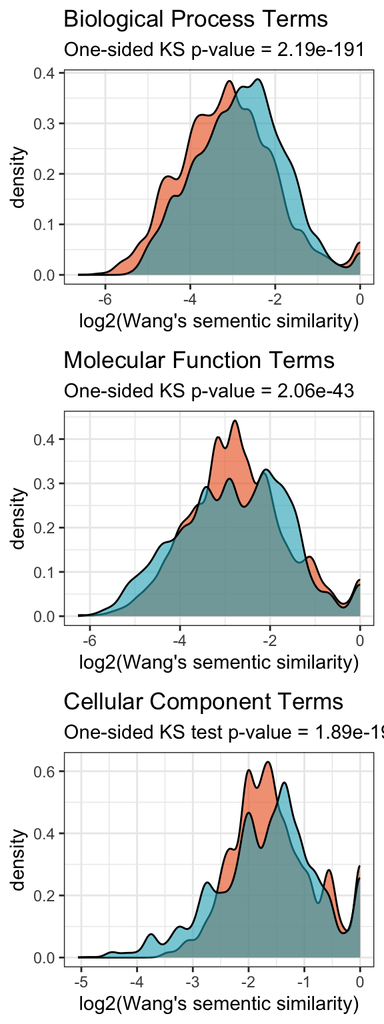

```r
ss_test<-readRDS("./RDS/ss_test_Wang.rds")
#Plot the difference in SS between groups with the test p-value;
#the one-sided test checks whether the divergence of the convergent distribution is significantly higher at the corresponding values.
ss_test %>% filter(GO_group=="BP") %>%
  ggplot(aes(x=log2(value), fill = type))+
  geom_density(color="black", alpha=0.6)+
  theme_bw()+
  scale_fill_manual(values = c("#EA5B15","#1AAEC0"))+
  xlab("log2(Wang's sementic similarity)")+
  labs(title = "Biological Process Terms",
       subtitle = paste0("One-sided KS p-value = ",
                         signif(ks.test(ss_test %>% filter(GO_group=="BP") %>% filter(type=="Convergent") %>% pull(value),
                                            ss_test %>% filter(GO_group=="BP") %>% filter(type=="Non-convergent") %>% pull(value),
                                            alternative = "greater", exact = T)$p.value,digits = 3)))->g_bp_ks

ss_test %>% filter(GO_group=="MF") %>%
  ggplot(aes(x=log2(value), fill = type))+
  geom_density(color="black", alpha=0.6)+
  scale_fill_manual(values = c("#EA5B15","#1AAEC0"))+
  theme_bw()+
  xlab("log2(Wang's sementic similarity)")+
  labs(title = "Molecular Function Terms",
       subtitle = paste0("One-sided KS p-value = ",
                         signif(ks.test(ss_test %>% filter(GO_group=="MF") %>% filter(type=="Convergent") %>% pull(value),
                                            ss_test %>% filter(GO_group=="MF") %>% filter(type=="Non-convergent") %>% pull(value),
                                            alternative = "greater",exact = T)$p.value, digits = 3)))->g_mf_ks


ss_test %>% filter(GO_group=="CC") %>%
  ggplot(aes(x=log2(value), fill = type))+
  geom_density(color="black", alpha=0.6)+
  scale_fill_manual(values = c("#EA5B15","#1AAEC0"))+
  theme_bw()+
  xlab("log2(Wang's sementic similarity)")+
  labs(title = "Cellular Component Terms",
       subtitle = paste0("One-sided KS test p-value = ",
                         signif(ks.test(ss_test %>% filter(GO_group=="CC") %>% filter(type=="Convergent") %>% pull(value),
                                            ss_test %>% filter(GO_group=="CC") %>% filter(type=="Non-convergent") %>% pull(value),
                                            alternative = "greater",exact = T)$p.value, digits = 3)))->g_cc_ks

ggpubr::ggarrange(g_bp_ks,g_mf_ks,g_cc_ks,ncol = 1, common.legend = T,legend = "none")
```

### SS Dendrogram

In this section I do a semantic similarity analysis between GO terms and then make a dendrogram to visualise their diversity and similarity.

```r
##Compute SS between terms
SemSim_compute<-function(ensembl,annot,measure, semData){
expand_grid(c1=annot %>% filter(ENSEMBL==paste0(ensembl)) %>% pull(GO),
            c2=annot %>% filter(ENSEMBL==paste0(ensembl)) %>% pull(GO)) %>%
    filter(c1 != c2) %>%
  # Ensure symmetric rows are removed
  rowwise() %>%
  mutate(pair = list(sort(c(c1, c2)))) %>%
  ungroup() %>%
  distinct(pair, .keep_all = TRUE) %>%
  dplyr::select(-pair)->dat

#Make the function to calculate semantic similarity
avg_semsim<-function(go1,go2,measure,combine,ensembl){
  goSim(go1, go2, semData=semData, measure=measure)->res

  data.frame(GO1=go1,
             GO2=go2,
             ss=res,
             ensembl_id=ensembl)->res_dat

  return(res_dat)
}

purrr::pmap(list(.x = as.list(dat$c1),
                 .y = as.list(dat$c2)),
            ~avg_semsim(go1=.x, go2=.y,
                        ensembl=ensembl,
                        measure = measure)) %>% list_rbind()->ss_res
return(ss_res)

}
#To get the graphs for the other categories, replace go_annotations_BP, and drGO_BP
purrr::map(.x=as.list(geneset_conv$orths),
           ~SemSim_compute(ensembl = .x,
                           annot=go_annotations_BP,
                           semData=drGO_BP, measure="Wang")) %>% list_rbind()->ss_out_conv

# Function to get GO term descriptions
get_go_description <- function(go_terms) {
  library(GO.db)
  map_chr(go_terms, ~ AnnotationDbi::select(GO.db, keys = .x, columns = "TERM", keytype = "GOID")$TERM[1] %||% NA)
}
# Add descriptions to dataframe
df <- ss_out_conv %>% na.omit() %>%
  mutate(
    GO1_Description = get_go_description(GO1),
    GO2_Description = get_go_description(GO2)
  )
#df %>% write_csv("./Datasets/DatasetS0_csv_files/SS_graph_data_CC.csv")
```

These plots can be found in Datasets S12 in the online repository.

```r
library(enrichplot)
library(clusterProfiler)
df<-read_csv("./Datasets/DatasetS0_csv_files/SS_graph_data_BP.csv")
#df <- df %>% na.omit() %>% filter(ss <= 0.5) #for the figure in the main text I use this filter to make visualisation clearer.

# Make custom enrichResult object
data.frame(ID=c(df$GO1,df$GO2)) %>% mutate(Description=get_go_description(c(df$GO1,df$GO2)))->t
inner_join(t,df %>% dplyr::select(GO1,ensembl_id) %>%
             dplyr::rename("ID"="GO1"), by = "ID",relationship = "many-to-many") %>%
  distinct(ID,ensembl_id, .keep_all = T)->t
t %>% group_by(ID, Description) %>% mutate(Count=n_distinct(ensembl_id)) %>% ungroup()->t
t %>% mutate(pvalue=0.05, p.adjust = 0.05) %>% dplyr::rename("geneID"="ensembl_id")->t2
t2 %>% distinct(ID, .keep_all = T) %>% column_to_rownames("ID") %>%
  mutate(ID=t2 %>% distinct(ID) %>% pull(ID)) %>%
  dplyr::select(ID, Description, pvalue,p.adjust,geneID,Count)->t2

custom_enrich <- new(
  "enrichResult",
  result = t2 %>% distinct(ID, .keep_all = T),
  organism = "custom",
  keytype = "ENSEMBL",
  ontology = "BP",#Can be kept the same
  gene = unlist(strsplit(t2$geneID, "/")),
  geneSets = list(),
  pvalueCutoff = 0.05,
  pAdjustMethod = "BH"
)

go_db <- godata('org.Dr.eg.db', ont="BP", computeIC=FALSE)#Change ont for other categories
sim_matrix <- setReadable(custom_enrich, 'org.Dr.eg.db', 'ENSEMBL')
sim_matrix <- enrichplot::pairwise_termsim(custom_enrich, semData=go_db, method = "Wang")
p_sim_matrix<- enrichplot::treeplot(sim_matrix)


dist_matrix <- as.dist(1 - sim_matrix@termsim)
hc <- hclust(dist_matrix, method = "ward.D2")

hc_dendro<-as.dendrogram(hc)
hc_dendro_data <- ggdendro::dendro_data(hc_dendro,type="rectangle")

labels_df <- hc_dendro_data$labels
left_join(
  left_join(labels_df,t2 %>% dplyr::select(Description,geneID),by=c("label"="Description")),
  danio_conv %>% dplyr::select(orths,`Gene name`), by=c("geneID"="orths")) %>% ungroup() %>% distinct(label,`Gene name`) %>% mutate(label=paste0(`Gene name`))->labels_gene_name
gene_colors <- colorspace::qualitative_hcl(n = 68, palette = "set3")
tibble(labels_gene_name %>% distinct(`Gene name`),
       gene_colors=gene_colors)
left_join(labels_gene_name,
          tibble(labels_gene_name %>% distinct(`Gene name`),
       gene_colors=gene_colors),
       by=c("Gene name"="Gene name"))->colors_gene

labels_df2<-tibble(x=labels_df$x, y=labels_df$y, label=labels_df$label, label2=labels_gene_name$label, col=colors_gene$gene_colors)

#These labels are for BP; users have to annotate the other categories themselves.
#labels_df$type<-c(rep("Development",36),
#                  rep("Translation and protein processing",32),
#                  rep("Metabolic process",11),
#                  rep("Transport",20),
#                  rep("Immune response",21),
#                  rep("Pigmentation and behaviour",4),
#                  rep("Mitotic process",15),
#                  rep("Signalling pathways",17),
#                  rep("Reproduction related",3),
#                  rep("Cell cycle and homeostasis",12))


library(ggdendro)
ggplot(segment(hc_dendro_data)) +
  geom_segment(aes(x = x, y = y, xend = xend, yend = yend))+
  geom_text(data = labels_df2,
            aes(x=x, y=y-0.05, label=label2, colour = col),
            hjust = 0,vjust = 0.4, size=3,fontface="italic")+
  geom_text(data = labels_df2,
            aes(x=x, y=y-0.5, label=label),
            hjust = 0,vjust = 0.4, size=3)+
  coord_flip()+
  scale_y_reverse(expand = c(0.9, 0))+
  scale_color_identity()+
  theme_void()
```

## Phenotypic effect distribution

We collected data from the Zebrafish International Network (ZFIN) database to examine the distribution of unique phenotypic terms associated with genetic perturbation (knockdowns, mutation screens, and morpholino experiments) in Danio rerio. The ZFIN database provides a wide array of expertly curated cross referenced genetic and genomics data that is routinely used to study gene functions. For the convergent genes with data in ZFIN, we observed that genetic perturbation can affect several structures across multiple tissue systems. Compared to the background of all genes with available phenotypic data, the convergent genes had a higher distribution at intermediate levels of affected phenotypic terms, significantly different from the background (one-sided Kolmogorov-Smirnov test P < 0.05)

### Load the data

```r
read_csv("./Datasets/DatasetS0_csv_files/Danio_biomart.csv")->Danio_biomart #Obtained from bioMart package
read_tsv("./Datasets/DatasetS0_csv_files/phenoGeneCleanData_fish_2023.05.07.tsv")->pheno #Download from ZFIN



get_danio<-function(data,name){
orth_list %>% filter(Species=="Danio_rerio") %>% filter(Orthogroup %in% data)->d

Danio_biomart %>% filter(`Gene stable ID` %in% d$orths) %>% distinct(`Gene name`) %>%  write_csv(paste0("./Datasets/DatasetS0_csv_files/",name,"_convergent_Danio_genes.csv"))
}

get_danio(non_spuroius_conv$Orthogroup,"Non_spurious_conv")

orth_list %>% filter(Orthogroup %in% non_spuroius_conv$Orthogroup) %>% filter(sp == "Danio_rerio") %>% dplyr::select(Orthogroup,orths)->dan


left_join(dan,pheno %>% filter(`Gene Symbol` %in% dan$`Gene name`) %>% dplyr::rename(`Gene name`=`Gene Symbol`), by = "Gene name") %>% write_csv("./Datasets/DatasetS0_csv_files/Danio_rerio_convergent_genes_pheno.csv")
```

### ZFIN table

| Orthogroup | orths | Gene stable ID version | Transcript stable ID | Transcript stable ID version | Gene name | Gene description | Affected Structure or Process 1 superterm Name | Phenotype Keyword Name | Phenotype Tag | Publication ID |
| --- | --- | --- | --- | --- | --- | --- | --- | --- | --- | --- |
| OG0001823 | ENSDARG00000116648 | ENSDARG00000116648.1 | ENSDART00000192702 | ENSDART00000192702.1 | alcama | activated leukocyte cell adhesion molecule a [Source:NCBI gene;Acc:30194] | amacrine cell | decreased amount | abnormal | ZDB-PUB-090106-20 |
| OG0001823 | ENSDARG00000116648 | ENSDARG00000116648.1 | ENSDART00000192702 | ENSDART00000192702.1 | alcama | activated leukocyte cell adhesion molecule a [Source:NCBI gene;Acc:30194] | amacrine cell | decreased amount | abnormal | ZDB-PUB-090106-20 |
| OG0001823 | ENSDARG00000116648 | ENSDARG00000116648.1 | ENSDART00000192702 | ENSDART00000192702.1 | alcama | activated leukocyte cell adhesion molecule a [Source:NCBI gene;Acc:30194] | cardiac ventricle | elongated | abnormal | ZDB-PUB-190405-15 |
| OG0001823 | ENSDARG00000116648 | ENSDARG00000116648.1 | ENSDART00000192702 | ENSDART00000192702.1 | alcama | activated leukocyte cell adhesion molecule a [Source:NCBI gene;Acc:30194] | ceratohyal cartilage | fused with | abnormal | ZDB-PUB-101122-3 |
| OG0001823 | ENSDARG00000116648 | ENSDARG00000116648.1 | ENSDART00000192702 | ENSDART00000192702.1 | alcama | activated leukocyte cell adhesion molecule a [Source:NCBI gene;Acc:30194] | cranial nerve II | aplastic | abnormal | ZDB-PUB-090106-20 |
| OG0001823 | ENSDARG00000116648 | ENSDARG00000116648.1 | ENSDART00000192702 | ENSDART00000192702.1 | alcama | activated leukocyte cell adhesion molecule a [Source:NCBI gene;Acc:30194] | cranial nerve II | aplastic | abnormal | ZDB-PUB-090106-20 |
| OG0001823 | ENSDARG00000116648 | ENSDARG00000116648.1 | ENSDART00000192702 | ENSDART00000192702.1 | alcama | activated leukocyte cell adhesion molecule a [Source:NCBI gene;Acc:30194] | cranial nerve II | decreased thickness | abnormal | ZDB-PUB-090106-20 |
| OG0001823 | ENSDARG00000116648 | ENSDARG00000116648.1 | ENSDART00000192702 | ENSDART00000192702.1 | alcama | activated leukocyte cell adhesion molecule a [Source:NCBI gene;Acc:30194] | cranial nerve II | decreased thickness | abnormal | ZDB-PUB-090106-20 |
| OG0001823 | ENSDARG00000116648 | ENSDARG00000116648.1 | ENSDART00000192702 | ENSDART00000192702.1 | alcama | activated leukocyte cell adhesion molecule a [Source:NCBI gene;Acc:30194] | cranial nerve II | aplastic | abnormal | ZDB-PUB-090106-20 |
| OG0001823 | ENSDARG00000116648 | ENSDARG00000116648.1 | ENSDART00000192702 | ENSDART00000192702.1 | alcama | activated leukocyte cell adhesion molecule a [Source:NCBI gene;Acc:30194] | cranial nerve II | aplastic | abnormal | ZDB-PUB-090106-20 |
| OG0001823 | ENSDARG00000116648 | ENSDARG00000116648.1 | ENSDART00000192702 | ENSDART00000192702.1 | alcama | activated leukocyte cell adhesion molecule a [Source:NCBI gene;Acc:30194] | cranial nerve II | decreased thickness | abnormal | ZDB-PUB-090106-20 |
| OG0001823 | ENSDARG00000116648 | ENSDARG00000116648.1 | ENSDART00000192702 | ENSDART00000192702.1 | alcama | activated leukocyte cell adhesion molecule a [Source:NCBI gene;Acc:30194] | cranial nerve II | decreased thickness | abnormal | ZDB-PUB-090106-20 |
| OG0001823 | ENSDARG00000116648 | ENSDARG00000116648.1 | ENSDART00000192702 | ENSDART00000192702.1 | alcama | activated leukocyte cell adhesion molecule a [Source:NCBI gene;Acc:30194] | cranial nerve II | aplastic | abnormal | ZDB-PUB-090106-20 |
| OG0001823 | ENSDARG00000116648 | ENSDARG00000116648.1 | ENSDART00000192702 | ENSDART00000192702.1 | alcama | activated leukocyte cell adhesion molecule a [Source:NCBI gene;Acc:30194] | cranial nerve II | aplastic | abnormal | ZDB-PUB-090106-20 |
| OG0001823 | ENSDARG00000116648 | ENSDARG00000116648.1 | ENSDART00000192702 | ENSDART00000192702.1 | alcama | activated leukocyte cell adhesion molecule a [Source:NCBI gene;Acc:30194] | cranial nerve II | decreased thickness | abnormal | ZDB-PUB-090106-20 |
| OG0001823 | ENSDARG00000116648 | ENSDARG00000116648.1 | ENSDART00000192702 | ENSDART00000192702.1 | alcama | activated leukocyte cell adhesion molecule a [Source:NCBI gene;Acc:30194] | cranial nerve II | decreased thickness | abnormal | ZDB-PUB-090106-20 |
| OG0001823 | ENSDARG00000116648 | ENSDARG00000116648.1 | ENSDART00000192702 | ENSDART00000192702.1 | alcama | activated leukocyte cell adhesion molecule a [Source:NCBI gene;Acc:30194] | eye | decreased size | abnormal | ZDB-PUB-090106-20 |
| OG0001823 | ENSDARG00000116648 | ENSDARG00000116648.1 | ENSDART00000192702 | ENSDART00000192702.1 | alcama | activated leukocyte cell adhesion molecule a [Source:NCBI gene;Acc:30194] | eye | decreased size | abnormal | ZDB-PUB-090106-20 |
| OG0001823 | ENSDARG00000116648 | ENSDARG00000116648.1 | ENSDART00000192702 | ENSDART00000192702.1 | alcama | activated leukocyte cell adhesion molecule a [Source:NCBI gene;Acc:30194] | eye | decreased size | abnormal | ZDB-PUB-090106-20 |
| OG0001823 | ENSDARG00000116648 | ENSDARG00000116648.1 | ENSDART00000192702 | ENSDART00000192702.1 | alcama | activated leukocyte cell adhesion molecule a [Source:NCBI gene;Acc:30194] | eye | decreased size | abnormal | ZDB-PUB-090106-20 |
| OG0001823 | ENSDARG00000116648 | ENSDARG00000116648.1 | ENSDART00000192702 | ENSDART00000192702.1 | alcama | activated leukocyte cell adhesion molecule a [Source:NCBI gene;Acc:30194] | eye | decreased size | abnormal | ZDB-PUB-090106-20 |
| OG0001823 | ENSDARG00000116648 | ENSDARG00000116648.1 | ENSDART00000192702 | ENSDART00000192702.1 | alcama | activated leukocyte cell adhesion molecule a [Source:NCBI gene;Acc:30194] | eye | decreased diameter | abnormal | ZDB-PUB-090106-20 |
| OG0001823 | ENSDARG00000116648 | ENSDARG00000116648.1 | ENSDART00000192702 | ENSDART00000192702.1 | alcama | activated leukocyte cell adhesion molecule a [Source:NCBI gene;Acc:30194] | eye | mislocalised ventrally | abnormal | ZDB-PUB-090106-20 |
| OG0001823 | ENSDARG00000116648 | ENSDARG00000116648.1 | ENSDART00000192702 | ENSDART00000192702.1 | alcama | activated leukocyte cell adhesion molecule a [Source:NCBI gene;Acc:30194] | eye | decreased size | abnormal | ZDB-PUB-090106-20 |
| OG0001823 | ENSDARG00000116648 | ENSDARG00000116648.1 | ENSDART00000192702 | ENSDART00000192702.1 | alcama | activated leukocyte cell adhesion molecule a [Source:NCBI gene;Acc:30194] | eye | decreased size | abnormal | ZDB-PUB-090106-20 |
| OG0001823 | ENSDARG00000116648 | ENSDARG00000116648.1 | ENSDART00000192702 | ENSDART00000192702.1 | alcama | activated leukocyte cell adhesion molecule a [Source:NCBI gene;Acc:30194] | eye | decreased size | abnormal | ZDB-PUB-090106-20 |
| OG0001823 | ENSDARG00000116648 | ENSDARG00000116648.1 | ENSDART00000192702 | ENSDART00000192702.1 | alcama | activated leukocyte cell adhesion molecule a [Source:NCBI gene;Acc:30194] | eye | mislocalised ventrally | abnormal | ZDB-PUB-090106-20 |
| OG0001823 | ENSDARG00000116648 | ENSDARG00000116648.1 | ENSDART00000192702 | ENSDART00000192702.1 | alcama | activated leukocyte cell adhesion molecule a [Source:NCBI gene;Acc:30194] | eye | decreased diameter | abnormal | ZDB-PUB-090106-20 |
| OG0001823 | ENSDARG00000116648 | ENSDARG00000116648.1 | ENSDART00000192702 | ENSDART00000192702.1 | alcama | activated leukocyte cell adhesion molecule a [Source:NCBI gene;Acc:30194] | eye | decreased diameter | abnormal | ZDB-PUB-090106-20 |
| OG0001823 | ENSDARG00000116648 | ENSDARG00000116648.1 | ENSDART00000192702 | ENSDART00000192702.1 | alcama | activated leukocyte cell adhesion molecule a [Source:NCBI gene;Acc:30194] | eye | mislocalised ventrally | abnormal | ZDB-PUB-090106-20 |

[output cut: 567 more lines]